# Expansão do metrô, do trem e do monotrilho em São Paulo e o emprego formal de pessoas do CadÚnico

Dados, desenhos de identificação e resultados

Data de Publicação

24/11/2026 20:05

**Pergunta.** As aberturas de estações de metrô, trem (CPTM) e monotrilho em São Paulo entre 2013 e 2022 melhoraram a situação no emprego formal de pessoas de baixa renda inscritas no CadÚnico? Separamos duas margens:

- **conseguir** um emprego: o ganho de acessibilidade a empregos a partir de casa aumenta o emprego, a entrada no emprego formal e o salário?
- **manter** o emprego: para quem já está empregado, o ganho de tempo no trajeto casa → trabalho reduz desligamentos?

**Como o documento está organizado.**

1. **Dados:** fontes, mapa das linhas, eventos, amostras e desfechos. É comum a todos os desenhos.
2. **Redes, tempos de viagem e acessibilidade:** como as redes de transporte foram montadas, como os tempos de viagem foram calculados, como a acessibilidade é medida e como o decaimento da gravitacional foi calibrado.
3. **Resumo dos desenhos:** uma tabela com a pergunta, a comparação e o principal resultado de cada desenho, com links.
4. **Uma seção por desenho (A a E),** sempre na mesma ordem:
   - estratégia de identificação, explicada passo a passo;
   - estatística descritiva;
   - resultados;
   - heterogeneidade (o efeito em cada grupo e as diferenças entre grupos);
   - robustez;
   - conclusão do desenho.
5. **Conclusão geral:** o que os cinco desenhos dizem juntos, e os limites.

**Como ler as tabelas.**

- **Abas.** As tabelas de resultados têm abas, uma por tipo de desfecho (por exemplo, Emprego, Entrada, Permanência; ou Demissão, Demissão sem justa causa, Pedido de demissão). Clique no nome da aba para trocar.
- **Linhas.** São grupos de pessoas (todos, mulheres, homens…) ou versões do indicador. A primeira coluna fica fixa quando a tabela rola para o lado.
- **Colunas.** Seguem a ordem do tempo: 6, 12, 18 e 24 meses depois do mês de referência. Em cada horizonte aparecem lado a lado o efeito **depois** da abertura e o **placebo**.
- **Células.** Cada célula traz o efeito estimado, as estrelas de significância e, entre parênteses, o erro-padrão. Estrelas: * p < 0,10; ** p < 0,05; *** p < 0,01. Efeitos em pontos percentuais (p.p.), salvo indicação; salário em %.
- **Placebo.** É a mesma conta feita com a referência 25 meses antes da primeira abertura, quando a estação ainda não existia, e por isso deve dar zero.
  - Se o efeito “depois” é significativo e o placebo não, o resultado é crível.
  - Se os dois são significativos, há diferenças que já existiam antes da estação, e o resultado pede cautela.
- **Quadros verdes.** Os quadros “O que estes resultados mostram” resumem em palavras os números de cada bloco. São gerados a partir das próprias estimativas e se atualizam com elas.
- **Quadros azuis.** Explicam como cada bloco está organizado.
- **Quadros amarelos.** Indicam estimações ainda em execução.

# Dados

## Fontes e população

- **População.** Pessoas de 18 a 60 anos inscritas no CadÚnico.
  - O endereço usado é o mais recente entre quatro anos e um ano antes do evento, localizado num hexágono H3 de resolução 9 (cerca de 0,1 km²).
  - A mesma pessoa pode entrar em mais de um evento.
- **Emprego formal.** RAIS identificada, vínculos celetistas:
  - emprego no fim de cada mês;
  - admissões;
  - desligamentos com a causa (pedido do trabalhador, demissão sem justa causa, demissão com justa causa);
  - salário contratual;
  - local de trabalho geocodificado.
- **Criança na família.** Presença de criança de 0 a 5 anos na família da pessoa, a partir do cadastro completo do CadÚnico (todos os membros da família).
- **Redes de transporte.**
  - 27 redes de transporte público (GTFS): uma para cada estado da rede sobre trilhos entre 2013 e 2025, mais três com obras futuras.
  - Os tempos de viagem porta a porta foram calculados com o r5r, até 240 minutos nos trajetos longos.
- **Tratamentos.**
  1. Acessibilidade a empregos a partir de casa, em duas formas:
     - cumulativa: número de empregos alcançáveis em até 30, 45, 60 ou 90 minutos;
     - gravitacional: soma dos empregos ponderados por uma função que decai com o tempo de viagem, calibrada com os deslocamentos observados.
  2. Ganho de tempo no trajeto casa → próprio local de trabalho.

## Linhas e estações

O mapa mostra a rede sobre trilhos de 2025 (metrô, trem da CPTM e monotrilho da Linha 15) e as estações de cada nível. Cada nível é uma abertura com data própria de serviço pleno.

- No seletor do canto superior direito dá para trocar o fundo do mapa e ligar ou desligar cada nível.
- Clicando numa estação aparecem as datas de abertura e de serviço pleno.

[interactive chart not shown]

## Eventos

Cada data de serviço pleno é um evento.

- O **mês de referência** é o mês anterior ao serviço pleno. Os desfechos são medidos 6, 12, 18 e 24 meses depois dele.
- O **placebo** usa como referência o 25.º mês antes da primeira abertura (operação assistida) das estações do evento. Assim, mesmo o horizonte de 24 meses termina antes de a estação existir.

| Evento | Serviço pleno | Primeira abertura | Linhas | Estações | Mês de referência | Referência do placebo |
| --- | --- | --- | --- | --- | --- | --- |
| 1 | 09/09/2013 | 09/2013 | 7 (trem (CPTM)) | VILA AURORA | 08/2013 | 08/2011 |
| 2 | 12/02/2014 | 02/2014 | 5 (metrô) | ADOLFO PINHEIRO | 01/2014 | 01/2012 |
| 3 | 22/11/2014 | 11/2014 | 4 (metrô) | FRADIQUE COUTINHO | 10/2014 | 10/2012 |
| 4 | 26/10/2016 | 08/2014 | 15 (monotrilho) | ORATÓRIO, VILA PRUDENTE | 09/2016 | 07/2012 |
| 5 | 27/11/2017 | 09/2017 | 5 (metrô) | ALTO DA BOA VISTA, BORBA GATO, BROOKLIN | 10/2017 | 08/2015 |
| 6 | 03/02/2018 | 01/2018 | 4 (metrô) | HIGIENÓPOLIS-MACKENZIE | 01/2018 | 12/2015 |
| 7 | 02/04/2018 | 03/2018 | 5 (metrô) | EUCALIPTOS | 03/2018 | 02/2016 |
| 8 | 19/04/2018 | 04/2018 | 4 (metrô) | OSCAR FREIRE | 03/2018 | 03/2016 |
| 9 | 04/06/2018 | 03/2018 | 13 (trem (CPTM)) | GUARULHOS CECAP, AEROPORTO GUARULHOS, ENGENHEIRO GOULART | 05/2018 | 02/2016 |
| 10 | 31/08/2018 | 04/2018 | 5 (metrô) | MOEMA | 07/2018 | 03/2016 |
| 11 | 15/09/2018 | 08/2018 | 5 (metrô) | AACD-SERVIDOR | 08/2018 | 07/2016 |
| 12 | 13/10/2018 | 09/2018 | 5 (metrô) | HOSPITAL SÃO PAULO, SANTA CRUZ, CHÁCARA KLABIN | 09/2018 | 08/2016 |
| 13 | 10/11/2018 | 10/2018 | 4 (metrô) | SÃO PAULO-MORUMBI | 10/2018 | 09/2016 |
| 14 | 12/01/2019 | 04/2018 | 15 (monotrilho) | SÃO LUCAS, VILA TOLSTÓI, VILA UNIÃO, CAMILO HADDAD | 12/2018 | 03/2016 |
| 15 | 06/01/2020 | 04/2019 | 15 (monotrilho), 5 (metrô) | CAMPO BELO, JARDIM PLANALTO, SÃO MATEUS, FAZENDA DA JUTA, SAPOPEMBA | 12/2019 | 03/2017 |
| 16 | 06/11/2021 | 11/2021 | 9 (trem (CPTM)) | JOÃO DIAS | 10/2021 | 10/2019 |
| 17 | 03/03/2022 | 12/2021 | 15 (monotrilho) | JARDIM COLONIAL | 02/2022 | 11/2019 |
| 18 | 10/05/2022 | 12/2021 | 4 (metrô) | VILA SÔNIA | 04/2022 | 11/2019 |
| 19 | 22/06/2022 | 08/2021 | 9 (trem (CPTM)) | MENDES / BRUNO COVAS | 05/2022 | 07/2019 |

## Amostras

| Evento | Pessoas (desenho de área) | Empregadas no mês de referência | Vínculos com local de trabalho (desenho de tempo de viagem) | Desses, com trajeto de até 90 min |
| --- | --- | --- | --- | --- |
| 1 | 816.978 | 232.004 | 169.942 | 108.770 |
| 2 | 816.978 | 239.041 | 168.719 | 108.108 |
| 3 | 1.090.362 | 344.632 | 259.600 | 171.708 |
| 4 | 1.409.507 | 409.452 | 310.787 | 207.470 |
| 5 | 1.502.719 | 427.418 | 320.525 | 218.406 |
| 6 | 1.502.719 | 425.950 | 301.315 | 205.493 |
| 7 | 1.502.719 | 434.164 | 312.618 | 212.013 |
| 8 | 1.502.719 | 434.164 | 312.635 | 212.922 |
| 9 | 1.502.719 | 439.354 | 319.985 | 217.642 |
| 10 | 1.844.046 | 507.410 | 362.229 | 251.397 |
| 11 | 1.844.046 | 513.733 | 368.375 | 258.405 |
| 12 | 1.844.046 | 517.337 | 372.460 | 261.030 |
| 13 | 1.844.046 | 522.495 | 378.704 | 268.210 |
| 14 | 1.844.046 | 527.119 | 387.937 | 267.137 |
| 15 | 2.025.224 | 586.664 | 379.836 | 263.812 |
| 16 | 1.970.050 | 593.977 | 352.613 | 249.060 |
| 17 | 1.970.050 | 632.491 | 337.623 | 236.587 |
| 18 | 1.970.050 | 637.846 | 347.032 | 240.177 |
| 19 | 1.970.050 | 642.372 | 353.732 | 241.537 |
| total | 30.773.074 | 9.067.623 | 6.116.667 | 4.199.884 |

Pessoas e vínculos de cada evento, na janela depois da abertura. A mesma pessoa pode entrar em mais de um evento.

## Desfechos

O mês de referência (ref) é o mês anterior ao serviço pleno; h é o horizonte (6, 12, 18 ou 24 meses).

[output not shown]

# Redes, tempos de viagem e acessibilidade

**Por que esta seção importa.** Todos os desenhos dependem de duas medidas construídas aqui:

- o **ganho de tempo** no trajeto casa → trabalho (desenhos B a E);
- o **ganho de acessibilidade** a empregos a partir de casa (desenhos A, D e E).

As duas vêm da comparação entre versões da rede de transporte que só diferem pelas estações de uma abertura. Esta seção explica:

1. como essas redes foram montadas;
2. como os tempos de viagem foram calculados;
3. como a acessibilidade é medida e como o decaimento da gravitacional foi calibrado.

## Como as redes de transporte foram construídas (GTFS)

#### A ideia: uma rede para cada momento da expansão

Para saber quanto uma abertura mudou os trajetos, precisamos de duas redes que só diferem pelas estações dessa abertura. Montamos uma **família de 27 redes**, todas com o mesmo calendário (uma quarta-feira útil, 01/10/2025), os mesmos ônibus e as mesmas ruas. Elas mudam só nas estações de trilho:

- **A00 — a rede de 2025:** metrô, CPTM e monotrilho como estavam em 2025, incluindo as estações abertas naquele ano (Varginha, na Linha 9, e Ambuitá, na Linha 8).
- **A01 a A23 — a rede voltando no tempo:** cada rede tira, da anterior, as estações de uma abertura (um “nível”: estações de uma linha que abriram na mesma data). Começamos pela abertura mais recente; a A23 é a rede anterior a 2013. Assim, comparar a rede com o nível e a rede sem ele dá o ganho daquela abertura.
- **A24 a A26 — as obras futuras:** cada uma acrescenta à rede de 2025 uma linha inteira que ainda não existe (Linha 17-Ouro, Linha 6-Laranja e a extensão da Linha 2-Verde de Vila Prudente à Penha). São usadas no desenho E.

#### Como cada rede foi montada

- **Ônibus:** o GTFS da SPTrans de 2025, igual em todas as redes. Ônibus metropolitanos (EMTU) não entram.
- **Ruas e relevo:** a malha viária do OpenStreetMap e o modelo de relevo da rede de 2025, iguais em todas as redes (usados para as caminhadas).
- **Trilhos:** partimos do GTFS de trilhos de 2025.
  - **Tirar uma estação do meio da linha:** o trem passa sem parar, e os tempos dos demais trechos ficam iguais.
  - **Tirar a ponta da linha:** a linha encurta, e os tempos dos trechos restantes ficam iguais.
  - **Estação nova sem tempo no GTFS:** o tempo da linha é repartido pela distância entre estações, com a velocidade média da própria viagem.
  - **Obras futuras:** o traçado planejado do GeoSampa, com a velocidade comercial e os intervalos de uma linha parecida já em operação (35 km/h; monotrilho como a Linha 15, metrô como a Linha 4).
- **“Números aleatórios comuns”:** todas as redes têm as mesmas viagens, na mesma ordem e com os mesmos intervalos. Quando uma linha deixa de existir numa rede, ela vira um “trem fantasma”, com os mesmos horários mas sem embarque. Isso faz o sorteio de horários do roteador ser o mesmo em todas as redes, para que a diferença entre duas redes venha só das estações, e não do acaso do sorteio.
- **Conferência:** a rede reconstruída para a data de cada GTFS anual disponível (2012, 2015, 2019 e 2023) tem as mesmas estações por linha que o GTFS daquele ano (casamento por proximidade, até 300 m).

## Como o tempo de viagem foi calculado

- **Roteador:** r5r (R5), com transporte público e caminhada (a pé até o ponto ou a estação, nas baldeações e até o destino).
- **Horário:** partidas entre 06:50 e 07:05 de uma quarta-feira útil (janela de 15 minutos). Para cada par, usamos a **mediana** do tempo de viagem nessa janela.
- **Unidade espacial:** hexágonos H3 de resolução 9 (cerca de 0,1 km²), ligados pelo centro.
  - **Origens:** 10.613 hexágonos (a grade da cidade mais os hexágonos onde moram inscritos no CadÚnico).
  - **Destinos:** os hexágonos da grade, com os empregos.
- **Limite:** a matriz completa vai até 90 minutos. Para os trajetos casa → trabalho que passam de 90 minutos em alguma rede, calculamos os tempos até 240 minutos em todas as 27 redes.
- **Semente fixa** em todas as redes, junto com os números aleatórios comuns descritos acima.

#### O trajeto casa → trabalho e o ganho de tempo (desenhos B a E)

- **Casa:** o hexágono do endereço mais recente da pessoa no CadÚnico, entre quatro anos e um ano antes do evento.
- **Trabalho:** o hexágono do estabelecimento do vínculo de referência, pela geocodificação da RAIS.
- **Ganho de tempo de um evento:** tempo do par na rede sem as estações do evento menos o tempo na rede com elas. Quando o tempo sem as estações passa do limite (90 ou 240 minutos), ele é tratado como 91 ou 241 minutos.
- **Trajeto antes do evento:** o tempo na rede vigente logo antes do evento. É ele que separa os trajetos de até 90 e de mais de 90 minutos.

## Como a acessibilidade é calculada

#### Empregos

- **Fonte:** empregos formais da RAIS de 2015, vínculos ativos em 31/12, no hexágono do estabelecimento.
- **Mesmo ano em todas as redes:** o ano dos empregos é o mesmo em todas as redes, para que o ganho de acessibilidade venha só da mudança no transporte, e não da mudança no lugar dos empregos.

#### Acessibilidade cumulativa (30, 45, 60 e 90 minutos)

Para cada hexágono de moradia, é o **número de empregos que dá para alcançar em até X minutos** de transporte público. Todos os empregos dentro do limite contam igual, e os de fora não contam.

- **Ganho absoluto:** diferença em número de empregos (na unidade de +100 mil).
- **Ganho percentual:** diferença dividida pela acessibilidade de logo antes do evento (com piso de 1.000 empregos), na unidade de +10%.

#### Acessibilidade gravitacional e a calibração do decaimento

A cumulativa tem um defeito: um emprego a 59 minutos conta inteiro, e um a 61 minutos não conta nada. A gravitacional resolve isso dando a cada emprego um **peso que diminui com o tempo de viagem**:

*A<sub>i</sub> = Σ<sub>j</sub> empregos<sub>j</sub> × exp(−β × t<sub>ij</sub>)*

Nessa fórmula:

- *A<sub>i</sub>* é a acessibilidade do hexágono de moradia *i*;
- a soma vai sobre todos os hexágonos de destino *j*, até 240 minutos;
- *t<sub>ij</sub>* é o tempo de viagem;
- *β* diz quão rápido o peso cai.

**Calibração de β.** Escolhemos β para refletir quanto tempo as pessoas do CadÚnico de fato viajam até o trabalho:

- calculamos o tempo médio do trajeto casa → trabalho dos inscritos que estavam empregados em 31/12/2012, na rede de 2012 e com trajetos até 240 minutos;
- esse tempo médio é de **78,8 minutos** (59.398 trabalhadores);
- fizemos **β = 1 / 78,8 = 0,0127 por minuto**.

Com essa escolha, um emprego no tempo médio de viagem pesa exp(−1) ≈ 0,37. Uma estimativa alternativa, a partir da queda no número de trabalhadores conforme o tempo, deu β = 0,0367, um decaimento bem mais rápido. Ela não é usada nos resultados.

**Ganho gravitacional:** a diferença entre a rede com e sem as estações do evento.

- **Medida percentual:** em log (+0,1 no log ≈ +10%), com a acessibilidade de antes com piso de 1.000 e o ganho limitado a +100%.
- **Medida absoluta:** em empregos ponderados (unidade de +100 mil).

Quanto pesa um emprego conforme o tempo de viagem

| Tempo de viagem (min) | Peso de um emprego na gravitacional | Conta na cumulativa de 60 min? |
| --- | --- | --- |
| 15 | 0,83 | sim (peso 1) |
| 30 | 0,68 | sim (peso 1) |
| 45 | 0,56 | sim (peso 1) |
| 60 | 0,47 | sim (peso 1) |
| 78,8 (tempo médio) | 0,37 | não (peso 0) |
| 90 | 0,32 | não (peso 0) |
| 120 | 0,22 | não (peso 0) |
| 180 | 0,10 | não (peso 0) |
| 240 | 0,05 | não (peso 0) |

Gravitacional com β = 0,0127 por minuto (1 / 78,8 min, o tempo médio casa → trabalho dos inscritos empregados em 2012).

#### Ganho de cada evento e ganho nos sorteios do B&H

- **Ganho de um evento:** a soma dos ganhos dos níveis que entraram em serviço pleno naquela data. O ganho de cada nível é sempre a rede com o nível menos a rede sem ele.
- **Ganho nos sorteios do B&H:** nos 199 sorteios das datas, o ganho que cada lugar teria tido em cada evento é a soma dos ganhos dos níveis sorteados para aquela data (“atalho aditivo”).
  - Esse atalho evita rotear de novo milhares de redes.
  - Ele supõe que os ganhos de níveis diferentes se somam.

# Resumo dos desenhos

**Como os desenhos se encaixam.**

- **A e B são os desenhos principais.** Os dois usam a mesma fonte de variação: o calendário das aberturas, pelo método de Borusyak e Hull (B&H). A responde à margem de **conseguir** emprego; B, à de **manter** o emprego.
- **C** abre o resultado de B sobre os pedidos de demissão: mostra para onde vai quem pede demissão.
- **D e E refazem as mesmas perguntas com outras comparações,** que dependem de hipóteses diferentes:
  - D compara tratados com controles que se parecem com eles nas características observadas (IPTW);
  - E compara tratados com pessoas que vão ter o mesmo ganho mais tarde.

Quando os três tipos de comparação apontam na mesma direção, o resultado fica mais confiável, porque um erro de hipótese dificilmente enganaria os três da mesma forma.

[output not shown]

**Índice dos desenhos**

- A. Acessibilidade a partir de casa (B&H)
- B. Tempo de viagem ao próprio emprego (B&H)
- C. Quem pediu demissão
- D. IPTW
- E. Controles futuros na mesma faixa
- Conclusão geral
- Como as redes, os tempos de viagem e a acessibilidade foram calculados

# A. Acessibilidade a partir de casa (B&H)

**Em uma frase.** Usamos o “acaso do calendário” (a data em que cada estação abriu dependeu de atrasos de obra e licitações) para medir se ganhar acessibilidade a empregos a partir de casa muda a chance de ter emprego formal.

**Como esta seção está organizada.**

1. **Estratégia:** o problema, a ideia e a conta passo a passo.
2. **Descritiva:** de quanto foi o ganho de acessibilidade.
3. **Resultados:**
   - um gráfico com todos os indicadores na mesma escala;
   - tabelas com uma aba por desfecho.
4. **Heterogeneidade:** o efeito em cada grupo e as diferenças entre grupos, para cada indicador.
5. **Robustez:** testes que mudam uma escolha de cada vez.

## Estratégia de identificação

#### O problema: por que não basta comparar quem ganhou com quem não ganhou

Lugares que ganham estação não são sorteados: o metrô e o trem vão para corredores onde já há demanda, com população e empregos diferentes do resto da cidade. Além disso, o mercado de trabalho muda ao longo do tempo (recessão de 2015–2016, pandemia de 2020).

Comparar quem mora perto de uma estação nova com quem mora longe mistura o efeito da estação com essas diferenças que já existiam. Na linguagem de econometria, o ganho de acessibilidade é **endógeno**: está correlacionado com outras coisas que também afetam o emprego.

#### A ideia: usar a sorte do calendário

O desenho usa outra fonte de variação: **o momento** em que cada estação abre.

- O traçado das linhas e o local das estações são decididos com muitos anos de antecedência.
- Já a data exata em que cada estação entra em serviço pleno depende de atrasos de obra, licitações, testes e contratos.

Suponha que uma estação abriu em 2018, e não em 2016 ou em 2020, por razões desse tipo. Então, entre lugares que “estavam na fila” para ganhar acessibilidade, quem ganhou primeiro foi, em boa medida, questão de sorte do calendário.

#### O que o coeficiente significa

É a variação do desfecho (em p.p.; salário em %) causada por uma unidade a mais de ganho de acessibilidade. Mostramos o ganho de duas formas:

- **ganho absoluto:** por +100 mil empregos alcançáveis (cumulativa) ou +100 mil empregos ponderados pelo tempo de viagem (gravitacional);
- **ganho percentual:** por +10% sobre a acessibilidade que a pessoa tinha logo antes do evento (na gravitacional, +0,1 no log, que é aproximadamente +10%).

Os indicadores têm escalas muito diferentes. Por isso, o gráfico mostra o efeito de **1 desvio-padrão** do ganho realizado, que permite compará-los.

#### O que precisa ser verdade (hipóteses)

1. **A data é quase aleatória, dado o lugar.** Entre hexágonos com o mesmo ganho esperado e no mesmo bairro, o fato de a estação ter aberto nesta data e não em outra não está ligado a fatores que afetam o emprego da pessoa.
2. **Os sorteios representam datas plausíveis.** Os sorteios só trocam datas que poderiam ter acontecido (a ordem dentro de cada linha é mantida).
3. **Sem antecipação nem outros choques coincidentes.** O desfecho não reage antes da abertura, e nenhum outro choque acontece justamente nas datas sorteadas. O placebo testa isso.
4. **O efeito passa pelo próprio ganho.** O emprego de uma pessoa depende do ganho de acessibilidade dela, e não do ganho de outros lugares (efeitos de transbordamento entre bairros ficam fora).

#### Como ler a incerteza

- **p por permutação:**
  - comparamos o efeito estimado com os 199 efeitos que obteríamos se as datas verdadeiras fossem as de um dos sorteios;
  - o p é a fração dos sorteios com efeito tão grande quanto o verdadeiro;
  - se o p é pequeno, o efeito dificilmente é sorte.
- **Erro-padrão:** agrupado por célula de 5 km, porque vizinhos sofrem choques parecidos.
- **Unidade:**
  - na versão principal, hexágono H3-9 × evento, com peso igual ao número de pessoas, o que dá exatamente o mesmo resultado de uma regressão com uma linha por pessoa;
  - na versão agregada, o hexágono H3-8 (cerca de 0,7 km²).

## Estatística descritiva

A tabela mostra o tamanho do ganho realizado de acessibilidade em cada indicador.

- Em cada evento, a maioria das pessoas mora longe das estações daquele evento e quase não ganha nada. Por isso a média é pequena e o desvio-padrão é grande em relação a ela.
- É o desvio-padrão que usamos para pôr os indicadores na mesma escala no gráfico de resultados.

| Indicador | Medida | Unidade da dose | Ganho médio | Desvio-padrão | Pessoas × evento | Hexágonos × evento |
| --- | --- | --- | --- | --- | --- | --- |
| 30 min | absoluto | cumulativa 30 min (+100 mil empregos) | 0,000 | 0,014 | 30.773.074 | 174.481 |
| 30 min | percentual | cumulativa 30 min (+10% da acessibilidade de antes) | 0,005 | 0,138 | 30.773.074 | 174.481 |
| 45 min | absoluto | cumulativa 45 min (+100 mil empregos) | 0,004 | 0,071 | 30.773.074 | 174.481 |
| 45 min | percentual | cumulativa 45 min (+10% da acessibilidade de antes) | 0,025 | 0,385 | 30.773.074 | 174.481 |
| 60 min | absoluto | cumulativa 60 min (+100 mil empregos) | 0,026 | 0,251 | 30.773.074 | 174.481 |
| 60 min | percentual | cumulativa 60 min (+10% da acessibilidade de antes) | 0,072 | 0,952 | 30.773.074 | 174.481 |
| 90 min | absoluto | cumulativa 90 min (+100 mil empregos) | 0,147 | 0,833 | 30.773.074 | 174.481 |
| 90 min | percentual | cumulativa 90 min (+10% da acessibilidade de antes) | 0,161 | 1,259 | 30.773.074 | 174.481 |
| gravitacional | absoluto | gravitacional (+100 mil empregos ponderados) | 0,042 | 0,214 | 30.773.074 | 174.481 |
| gravitacional | percentual | gravitacional (+0,1 no log) | 0,036 | 0,187 | 30.773.074 | 174.481 |

Ganho realizado do evento por pessoa, na unidade da dose (por exemplo, 0,05 = 5 mil empregos na unidade de +100 mil; 0,3 = 3% na unidade de +10%).

## Resultados

**Como estes resultados estão organizados.**

- **O gráfico** mostra o efeito de 1 desvio-padrão do ganho, para todas as pessoas:
  - uma coluna por indicador e uma linha por desfecho;
  - em azul, depois da abertura; em laranja, o placebo;
  - círculo para o ganho absoluto e triângulo para o percentual;
  - as barras são intervalos de 95%: quando cruzam o zero, o efeito não é distinguível de zero.
- **As tabelas** têm uma aba por desfecho. Em cada aba:
  - as linhas são os indicadores, cada um com o ganho absoluto e o percentual;
  - as colunas seguem o tempo (6, 12, 18 e 24 meses), com o efeito depois da abertura e o placebo lado a lado;
  - o efeito está por unidade da dose, conforme a legenda.

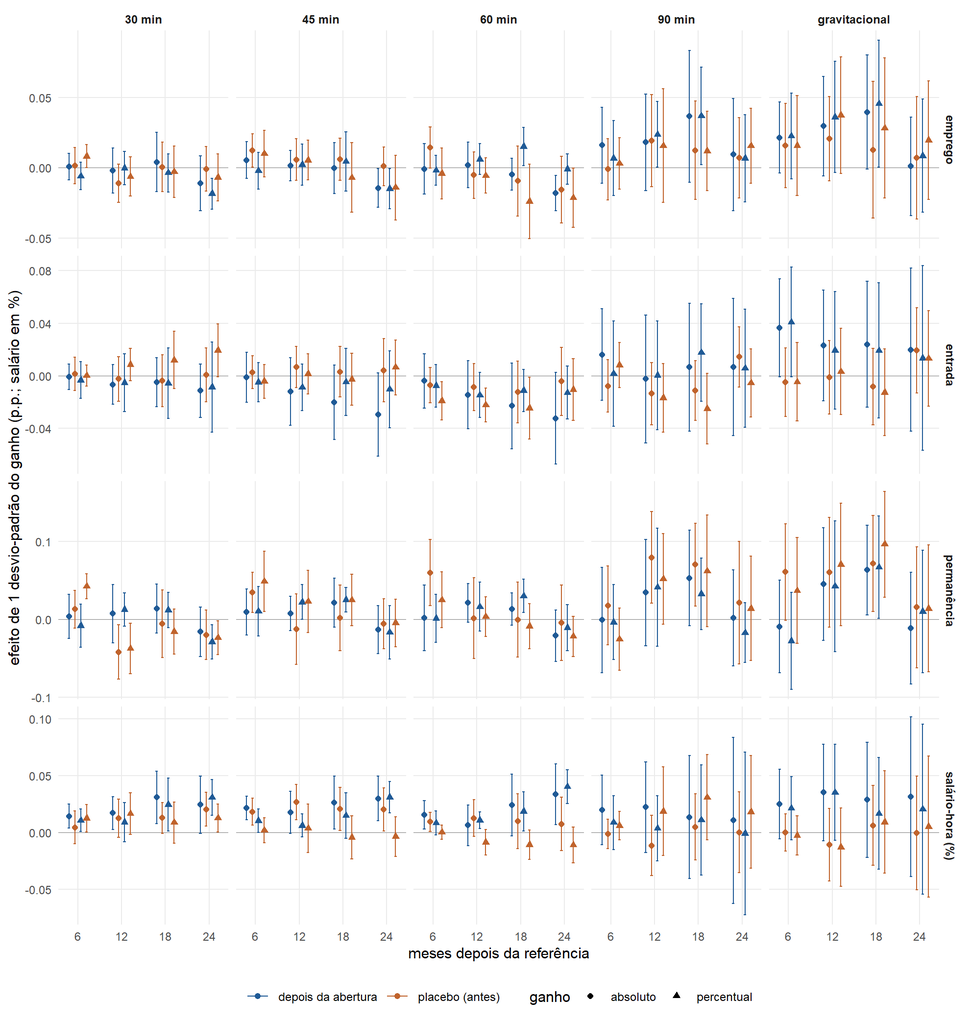

**O que estes resultados mostram**

Para comparar indicadores de escalas diferentes, os números abaixo são efeitos de **1 desvio-padrão do ganho de acessibilidade** (em p.p.; no salário, em %). Com tantas versões, algumas podem dar significativas só por acaso (cerca de 1 em cada 20, a 5%); por isso cada uma é comparada com o seu placebo.

**Emprego.** No horizonte de 12 meses, 1 das 10 versões (cinco indicadores × ganho absoluto e percentual) tem efeito estatisticamente significativo (a 5%): gravitacional · ganho percentual, com efeito de +0,036 (p = 0,045) e placebo de +0,037 (p = 0,035). Mas o placebo dessa versão também é significativo: a diferença já existia antes da abertura e, por isso, não deve ser lida como efeito da estação. No horizonte de 24 meses, 4 das 10 versões (cinco indicadores × ganho absoluto e percentual) têm efeito estatisticamente significativo (a 5%): 30 min · ganho absoluto, com efeito de −0,011 (p = 0,015) e placebo de −0,001 (p = 0,839); 30 min · ganho percentual, com efeito de −0,018 (p < 0,001) e placebo de −0,007 (p = 0,030); 45 min · ganho absoluto, com efeito de −0,014 (p = 0,005) e placebo de +0,001 (p = 0,844) e 45 min · ganho percentual, com efeito de −0,015 (p = 0,005) e placebo de −0,014 (p = 0,005). Em 2 delas, porém, o placebo também é significativo, o que enfraquece a leitura causal dessas versões. Em resumo, há algum sinal de efeito negativo sobre emprego em 2 versões com placebo nulo; o maior deles, em módulo, é de 0,014 ponto percentual.

**Entrada no emprego formal.** No horizonte de 12 meses, nenhuma das 10 versões (cinco indicadores × ganho absoluto e percentual) tem efeito estatisticamente significativo: as estimativas ficam entre −0,015 e +0,023 ponto percentual. No horizonte de 24 meses, 2 das 10 versões (cinco indicadores × ganho absoluto e percentual) têm efeito estatisticamente significativo (a 5%): 45 min · ganho absoluto, com efeito de −0,029 (p < 0,001) e placebo de +0,004 (p = 0,442) e 60 min · ganho absoluto, com efeito de −0,032 (p = 0,030) e placebo de −0,004 (p = 0,638). Em resumo, há algum sinal de efeito negativo sobre entrada no emprego formal em 2 versões com placebo nulo; o maior deles, em módulo, é de 0,032 ponto percentual.

**Permanência no emprego.** No horizonte de 12 meses, 2 das 10 versões (cinco indicadores × ganho absoluto e percentual) têm efeito estatisticamente significativo (a 5%): 30 min · ganho percentual, com efeito de +0,013 (p = 0,025) e placebo de −0,037 (p < 0,001) e 45 min · ganho percentual, com efeito de +0,022 (p = 0,010) e placebo de +0,023 (p = 0,040). Mas em todas elas o placebo também é significativo: as diferenças já existiam antes da abertura e, por isso, não devem ser lidas como efeito da estação. No horizonte de 24 meses, 1 das 10 versões (cinco indicadores × ganho absoluto e percentual) tem efeito estatisticamente significativo (a 5%): 30 min · ganho percentual, com efeito de −0,029 (p = 0,005) e placebo de −0,024 (p = 0,005). Mas o placebo dessa versão também é significativo: a diferença já existia antes da abertura e, por isso, não deve ser lida como efeito da estação. Em resumo, não há sinal confiável de efeito sobre permanência no emprego.

**Fração dos meses empregado.** No horizonte de 12 meses, nenhuma das 10 versões (cinco indicadores × ganho absoluto e percentual) tem efeito estatisticamente significativo: as estimativas ficam entre +0,002 e +0,017 ponto percentual. No horizonte de 24 meses, nenhuma das 10 versões (cinco indicadores × ganho absoluto e percentual) tem efeito estatisticamente significativo: as estimativas ficam entre +0,001 e +0,029 ponto percentual. Em resumo, não há sinal confiável de efeito sobre fração dos meses empregado.

**Salário-hora.** No horizonte de 12 meses, 5 das 10 versões (cinco indicadores × ganho absoluto e percentual) têm efeito estatisticamente significativo (a 5%): 30 min · ganho absoluto, com efeito de +0,017% (p = 0,005) e placebo de +0,012 (p = 0,015); 30 min · ganho percentual, com efeito de +0,009% (p = 0,015) e placebo de +0,017 (p = 0,010); 45 min · ganho absoluto, com efeito de +0,018% (p < 0,001) e placebo de +0,027 (p < 0,001); gravitacional · ganho absoluto, com efeito de +0,035% (p = 0,010) e placebo de −0,011 (p = 0,342) e gravitacional · ganho percentual, com efeito de +0,035% (p = 0,010) e placebo de −0,013 (p = 0,291). Em 3 delas, porém, o placebo também é significativo, o que enfraquece a leitura causal dessas versões. No horizonte de 24 meses, 6 das 10 versões (cinco indicadores × ganho absoluto e percentual) têm efeito estatisticamente significativo (a 5%): 30 min · ganho absoluto, com efeito de +0,024% (p = 0,005) e placebo de +0,020 (p = 0,010); 30 min · ganho percentual, com efeito de +0,031% (p = 0,010) e placebo de +0,013 (p = 0,020); 45 min · ganho absoluto, com efeito de +0,030% (p < 0,001) e placebo de +0,020 (p = 0,015); 45 min · ganho percentual, com efeito de +0,031% (p < 0,001) e placebo de −0,004 (p = 0,598); 60 min · ganho absoluto, com efeito de +0,034% (p < 0,001) e placebo de +0,007 (p = 0,392) e 60 min · ganho percentual, com efeito de +0,040% (p = 0,005) e placebo de −0,011 (p = 0,261). Em 3 delas, porém, o placebo também é significativo, o que enfraquece a leitura causal dessas versões. Em resumo, há algum sinal de efeito positivo sobre salário-hora em 5 versões com placebo nulo; o maior deles, em módulo, é de 0,040 %.

**Emprego**

| Indicador · medida do ganho | 6 meses · depois | 6 meses · placebo | 12 meses · depois | 12 meses · placebo | 18 meses · depois | 18 meses · placebo | 24 meses · depois | 24 meses · placebo |
| --- | --- | --- | --- | --- | --- | --- | --- | --- |
| 30 min · ganho absoluto | +0,061 (0,345) | +0,105 (0,469) | −0,142 (0,590) | −0,786** (0,497) | +0,285 (0,771) | +0,040 (0,644) | −0,799** (0,710) | −0,062 (0,582) |
| 30 min · ganho percentual | −0,043*** (0,036) | +0,059** (0,030) | −0,002 (0,044) | −0,046** (0,051) | −0,026* (0,050) | −0,021 (0,067) | −0,134*** (0,040) | −0,050** (0,062) |
| 45 min · ganho absoluto | +0,076 (0,094) | +0,172*** (0,085) | +0,018 (0,078) | +0,081 (0,106) | −0,005 (0,130) | +0,083 (0,108) | −0,204*** (0,099) | +0,013 (0,099) |
| 45 min · ganho percentual | −0,006 (0,018) | +0,026** (0,022) | +0,006 (0,019) | +0,014 (0,019) | +0,011 (0,028) | −0,018 (0,033) | −0,039*** (0,019) | −0,037*** (0,030) |
| 60 min · ganho absoluto | −0,004 (0,037) | +0,057* (0,030) | +0,007 (0,033) | −0,021 (0,034) | −0,019 (0,023) | −0,038 (0,051) | −0,072* (0,026) | −0,062* (0,048) |
| 60 min · ganho percentual | −0,002 (0,006) | −0,004 (0,010) | +0,006 (0,006) | −0,006 (0,007) | +0,016* (0,007) | −0,025** (0,014) | −0,001 (0,006) | −0,022** (0,011) |
| 90 min · ganho absoluto | +0,019 (0,016) | −0,001 (0,013) | +0,022 (0,021) | +0,023 (0,020) | +0,044** (0,029) | +0,015 (0,022) | +0,011 (0,024) | +0,008 (0,017) |
| 90 min · ganho percentual | +0,005 (0,011) | +0,002 (0,007) | +0,019 (0,009) | +0,012 (0,016) | +0,029* (0,014) | +0,009 (0,011) | +0,005 (0,013) | +0,012 (0,011) |
| gravitacional · ganho absoluto | +0,100* (0,060) | +0,074 (0,071) | +0,138* (0,084) | +0,097 (0,071) | +0,185** (0,097) | +0,059 (0,116) | +0,005 (0,083) | +0,033 (0,103) |
| gravitacional · ganho percentual | +0,120 (0,083) | +0,084 (0,097) | +0,192** (0,108) | +0,200** (0,113) | +0,243** (0,123) | +0,151 (0,136) | +0,045 (0,109) | +0,105 (0,115) |

Efeito por unidade da dose. Ganho absoluto: por +100 mil empregos alcançáveis (na gravitacional, +100 mil empregos ponderados). Ganho percentual: por +10% da acessibilidade de antes (na gravitacional, +0,1 no log). Salário em %; os demais em p.p.

**Entrada no emprego formal**

| Indicador · medida do ganho | 6 meses · depois | 6 meses · placebo | 12 meses · depois | 12 meses · placebo | 18 meses · depois | 18 meses · placebo | 24 meses · depois | 24 meses · placebo |
| --- | --- | --- | --- | --- | --- | --- | --- | --- |
| 30 min · ganho absoluto | −0,061 (0,345) | +0,097 (0,463) | −0,473 (0,541) | −0,177 (0,619) | −0,341 (0,669) | −0,276 (0,723) | −0,804* (0,734) | +0,047 (0,753) |
| 30 min · ganho percentual | −0,025* (0,052) | +0,001 (0,029) | −0,038* (0,081) | +0,062** (0,045) | −0,040* (0,098) | +0,086*** (0,080) | −0,062* (0,126) | +0,138*** (0,073) |
| 45 min · ganho absoluto | −0,017 (0,132) | +0,037 (0,088) | −0,166* (0,181) | +0,092 (0,112) | −0,279** (0,198) | +0,042 (0,136) | −0,406*** (0,223) | +0,058 (0,169) |
| 45 min · ganho percentual | −0,013 (0,020) | −0,011 (0,017) | −0,023* (0,023) | +0,004 (0,020) | −0,012 (0,034) | −0,007 (0,026) | −0,026 (0,038) | +0,017 (0,028) |
| 60 min · ganho absoluto | −0,016 (0,042) | −0,028 (0,027) | −0,058 (0,052) | −0,035 (0,036) | −0,091* (0,066) | −0,050 (0,047) | −0,128** (0,070) | −0,017 (0,052) |
| 60 min · ganho percentual | −0,008 (0,009) | −0,020** (0,008) | −0,015 (0,009) | −0,024* (0,007) | −0,012 (0,009) | −0,026** (0,013) | −0,013 (0,011) | −0,011 (0,013) |
| 90 min · ganho absoluto | +0,019 (0,021) | −0,009 (0,012) | −0,003 (0,030) | −0,016 (0,015) | +0,008 (0,030) | −0,013 (0,014) | +0,008 (0,032) | +0,017 (0,014) |
| 90 min · ganho percentual | +0,001 (0,016) | +0,006 (0,007) | +0,000 (0,017) | −0,013 (0,010) | +0,014 (0,015) | −0,020 (0,011) | +0,005 (0,018) | −0,004 (0,010) |
| gravitacional · ganho absoluto | +0,170*** (0,089) | −0,024 (0,062) | +0,107 (0,100) | −0,005 (0,066) | +0,111 (0,114) | −0,038 (0,069) | +0,092 (0,148) | +0,090 (0,077) |
| gravitacional · ganho percentual | +0,217*** (0,114) | −0,025 (0,081) | +0,103 (0,121) | +0,017 (0,089) | +0,102 (0,140) | −0,067 (0,089) | +0,072 (0,191) | +0,070 (0,098) |

Efeito por unidade da dose. Ganho absoluto: por +100 mil empregos alcançáveis (na gravitacional, +100 mil empregos ponderados). Ganho percentual: por +10% da acessibilidade de antes (na gravitacional, +0,1 no log). Salário em %; os demais em p.p.

**Permanência no emprego**

| Indicador · medida do ganho | 6 meses · depois | 6 meses · placebo | 12 meses · depois | 12 meses · placebo | 18 meses · depois | 18 meses · placebo | 24 meses · depois | 24 meses · placebo |
| --- | --- | --- | --- | --- | --- | --- | --- | --- |
| 30 min · ganho absoluto | +0,270 (1,099) | +0,949 (0,908) | +0,552 (1,445) | −3,059*** (1,301) | +1,050** (1,218) | −0,410 (1,617) | −1,206* (1,232) | −1,465* (1,186) |
| 30 min · ganho percentual | −0,059* (0,104) | +0,315*** (0,062) | +0,093** (0,079) | −0,277*** (0,123) | +0,087** (0,084) | −0,116** (0,109) | −0,211*** (0,083) | −0,175*** (0,081) |
| 45 min · ganho absoluto | +0,142 (0,225) | +0,516*** (0,195) | +0,110 (0,168) | −0,183 (0,343) | +0,320*** (0,240) | +0,027 (0,319) | −0,198 (0,234) | −0,084 (0,241) |
| 45 min · ganho percentual | +0,027 (0,043) | +0,127*** (0,051) | +0,058** (0,030) | +0,060** (0,053) | +0,066** (0,021) | +0,065** (0,044) | −0,044 (0,046) | −0,012 (0,040) |
| 60 min · ganho absoluto | +0,008 (0,088) | +0,242*** (0,087) | +0,086 (0,052) | +0,006 (0,107) | +0,054 (0,043) | −0,002 (0,099) | −0,086 (0,068) | −0,018 (0,100) |
| 60 min · ganho percentual | +0,001 (0,017) | +0,026 (0,019) | +0,017 (0,017) | +0,003 (0,013) | +0,032 (0,012) | −0,009 (0,015) | −0,011 (0,016) | −0,023 (0,014) |
| 90 min · ganho absoluto | −0,001 (0,042) | +0,021 (0,031) | +0,041 (0,042) | +0,096** (0,036) | +0,064 (0,038) | +0,085* (0,033) | +0,002 (0,038) | +0,026 (0,049) |
| 90 min · ganho percentual | −0,003 (0,020) | −0,021 (0,017) | +0,033 (0,031) | +0,043* (0,024) | +0,026 (0,019) | +0,051 (0,030) | −0,014 (0,016) | +0,011 (0,028) |
| gravitacional · ganho absoluto | −0,043 (0,143) | +0,288** (0,150) | +0,213 (0,173) | +0,285 (0,170) | +0,297* (0,137) | +0,340* (0,149) | −0,053 (0,172) | +0,074 (0,188) |
| gravitacional · ganho percentual | −0,148 (0,171) | +0,202 (0,190) | +0,229 (0,231) | +0,385* (0,219) | +0,360* (0,180) | +0,527** (0,189) | +0,054 (0,216) | +0,077 (0,227) |

Efeito por unidade da dose. Ganho absoluto: por +100 mil empregos alcançáveis (na gravitacional, +100 mil empregos ponderados). Ganho percentual: por +10% da acessibilidade de antes (na gravitacional, +0,1 no log). Salário em %; os demais em p.p.

**Fração dos meses empregado**

| Indicador · medida do ganho | 6 meses · depois | 6 meses · placebo | 12 meses · depois | 12 meses · placebo | 18 meses · depois | 18 meses · placebo | 24 meses · depois | 24 meses · placebo |
| --- | --- | --- | --- | --- | --- | --- | --- | --- |
| 30 min · ganho absoluto | −0,012 (0,753) | +0,366 (0,604) | +0,370 (0,945) | −0,585 (0,697) | +0,546 (0,939) | −1,192* (0,854) | +0,296 (0,945) | −1,271** (0,898) |
| 30 min · ganho percentual | −0,060** (0,079) | +0,198*** (0,048) | +0,017 (0,092) | +0,058 (0,074) | +0,040* (0,074) | −0,023 (0,087) | +0,006 (0,070) | −0,066** (0,071) |
| 45 min · ganho absoluto | +0,052 (0,169) | +0,358*** (0,134) | +0,152 (0,161) | +0,150 (0,163) | +0,155* (0,135) | +0,066 (0,211) | +0,135* (0,136) | +0,017 (0,201) |
| 45 min · ganho percentual | +0,023 (0,023) | +0,103*** (0,027) | +0,033* (0,028) | +0,090*** (0,035) | +0,050** (0,024) | +0,084*** (0,039) | +0,040* (0,025) | +0,066*** (0,038) |
| 60 min · ganho absoluto | −0,022 (0,055) | +0,178*** (0,051) | +0,027 (0,057) | +0,134*** (0,060) | +0,048 (0,040) | +0,094* (0,067) | +0,030 (0,037) | +0,066 (0,070) |
| 60 min · ganho percentual | +0,004 (0,010) | +0,028** (0,008) | +0,005 (0,013) | +0,021* (0,011) | +0,015 (0,012) | +0,013 (0,012) | +0,014 (0,012) | +0,006 (0,013) |
| 90 min · ganho absoluto | +0,015 (0,026) | +0,005 (0,027) | +0,020 (0,029) | +0,037* (0,020) | +0,025 (0,027) | +0,051* (0,019) | +0,029 (0,026) | +0,051* (0,022) |
| 90 min · ganho percentual | −0,006 (0,013) | −0,004 (0,013) | +0,005 (0,017) | +0,005 (0,011) | +0,012 (0,017) | +0,016 (0,013) | +0,013 (0,015) | +0,020 (0,017) |
| gravitacional · ganho absoluto | −0,019 (0,086) | +0,210*** (0,105) | +0,068 (0,105) | +0,265** (0,092) | +0,128 (0,106) | +0,263** (0,095) | +0,136 (0,107) | +0,231* (0,105) |
| gravitacional · ganho percentual | −0,084 (0,119) | +0,193* (0,140) | +0,022 (0,131) | +0,276* (0,133) | +0,119 (0,133) | +0,309** (0,133) | +0,159 (0,129) | +0,287* (0,135) |

Efeito por unidade da dose. Ganho absoluto: por +100 mil empregos alcançáveis (na gravitacional, +100 mil empregos ponderados). Ganho percentual: por +10% da acessibilidade de antes (na gravitacional, +0,1 no log). Salário em %; os demais em p.p.

**Salário-hora**

| Indicador · medida do ganho | 6 meses · depois | 6 meses · placebo | 12 meses · depois | 12 meses · placebo | 18 meses · depois | 18 meses · placebo | 24 meses · depois | 24 meses · placebo |
| --- | --- | --- | --- | --- | --- | --- | --- | --- |
| 30 min · ganho absoluto | +1,094*** (0,410) | +0,322 (0,530) | +1,338*** (0,576) | +0,980** (0,673) | +2,464*** (0,937) | +0,996** (0,540) | +1,948*** (1,034) | +1,576** (0,587) |
| 30 min · ganho percentual | +0,079** (0,038) | +0,091** (0,044) | +0,067** (0,065) | +0,129** (0,073) | +0,184** (0,089) | +0,068** (0,071) | +0,228** (0,060) | +0,097** (0,048) |
| 45 min · ganho absoluto | +0,329*** (0,080) | +0,271*** (0,090) | +0,266*** (0,143) | +0,410*** (0,121) | +0,401*** (0,182) | +0,318*** (0,147) | +0,463*** (0,156) | +0,306** (0,148) |
| 45 min · ganho percentual | +0,028*** (0,014) | +0,005 (0,014) | +0,016 (0,014) | +0,009 (0,028) | +0,039** (0,027) | −0,011 (0,025) | +0,084*** (0,019) | −0,009 (0,024) |
| 60 min · ganho absoluto | +0,064** (0,026) | +0,037 (0,017) | +0,026 (0,037) | +0,051 (0,033) | +0,100** (0,058) | +0,040 (0,050) | +0,140*** (0,057) | +0,030 (0,049) |
| 60 min · ganho percentual | +0,009* (0,006) | +0,000 (0,003) | +0,012 (0,004) | −0,009 (0,006) | +0,020* (0,009) | −0,011 (0,007) | +0,045*** (0,008) | −0,012 (0,009) |
| 90 min · ganho absoluto | +0,025* (0,019) | −0,002 (0,008) | +0,027* (0,025) | −0,014 (0,016) | +0,017 (0,034) | +0,006 (0,018) | +0,013 (0,046) | +0,000 (0,022) |
| 90 min · ganho percentual | +0,007 (0,010) | +0,005 (0,005) | +0,003 (0,012) | +0,015 (0,016) | +0,009 (0,020) | +0,025 (0,016) | −0,001 (0,030) | +0,015 (0,021) |
| gravitacional · ganho absoluto | +0,119** (0,074) | +0,000 (0,039) | +0,167** (0,102) | −0,051 (0,077) | +0,136* (0,123) | +0,029 (0,085) | +0,150* (0,170) | −0,002 (0,123) |
| gravitacional · ganho percentual | +0,117* (0,078) | −0,014 (0,047) | +0,191** (0,116) | −0,070 (0,096) | +0,091 (0,135) | +0,050 (0,126) | +0,111 (0,206) | +0,028 (0,175) |

Efeito por unidade da dose. Ganho absoluto: por +100 mil empregos alcançáveis (na gravitacional, +100 mil empregos ponderados). Ganho percentual: por +10% da acessibilidade de antes (na gravitacional, +0,1 no log). Salário em %; os demais em p.p.

## Heterogeneidade

#### Os grupos

- **Mulheres / homens:** sexo no CadÚnico.
- **18 a 29, 30 a 44, 45 a 60:** idade em 1º de janeiro do ano do evento.
- **Com criança / sem criança:** a família tem (ou não) criança de 0 a 5 anos no CadÚnico, no ano do endereço usado.
- **Mulheres com criança** etc.: cruzamento das duas características.

**Diferenças entre grupos.**

- A diferença é o efeito no primeiro grupo menos o efeito no segundo (por exemplo, “mulheres − homens”).
- As duas estimativas vêm de um único modelo em que cada grupo tem o próprio efeito. Por isso, o erro-padrão da diferença leva em conta que os grupos dividem os mesmos bairros.
- Na idade, além das diferenças entre pares de faixas, há um teste conjunto de que as três faixas têm o mesmo efeito.

**Como esta parte está organizada.**

- Há uma aba por indicador e medida do ganho (por exemplo, “60 min, absoluto”). Dentro dela, uma aba por desfecho.
- Em cada aba de desfecho:
  - primeiro vem a tabela com o efeito em cada grupo;
  - logo abaixo, a tabela com as diferenças entre grupos.
- No topo de cada indicador, o quadro verde conta quantas diferenças são significativas e quantas seriam esperadas só por acaso.
- Como há muitos grupos, desfechos e horizontes, algumas diferenças “significativas” aparecem por pura sorte. O quadro ajuda a separar o padrão do ruído.

**Visão geral: diferenças entre grupos em todos os indicadores**

Comparamos os grupos em 1399 combinações de indicador, medida do ganho, grupos, desfechos e horizontes depois da abertura. Se os grupos não diferissem em nada, cerca de 70 dessas comparações dariam significativas a 5% só por acaso; deram 186. Há mais diferenças do que o acaso explicaria. As mais fortes, começando pelas que não aparecem no placebo, são:

- **60 min · ganho percentual:** O efeito de +10% nos empregos alcançáveis em 60 min sobre o salário-hora 12 meses depois é 0,054% mais negativo para mulheres com criança pequena do que para mulheres sem criança pequena; a diferença é estatisticamente muito significativa (p < 0,001). No placebo, a mesma diferença é nula (+0,006, p = 0,739), o que reforça que ela surge com a abertura.
- **45 min · ganho percentual:** O efeito de +10% nos empregos alcançáveis em 45 min sobre a chance de continuar empregado 6 meses depois é 0,269 ponto percentual mais negativo para quem tem 45 a 60 anos do que para quem tem 18 a 29 anos; a diferença é estatisticamente muito significativa (p < 0,001). No placebo, a mesma diferença é nula (+0,110, p = 0,236), o que reforça que ela surge com a abertura.
- **90 min · ganho percentual:** O efeito de +10% nos empregos alcançáveis em 90 min sobre a fração dos meses em que a pessoa esteve empregada em até 6 meses é 0,099 ponto percentual mais negativo para quem tem 45 a 60 anos do que para quem tem 18 a 29 anos; a diferença é estatisticamente muito significativa (p < 0,001). No placebo, a mesma diferença é nula (−0,049, p = 0,104), o que reforça que ela surge com a abertura.
- **60 min · ganho percentual:** O efeito de +10% nos empregos alcançáveis em 60 min sobre a chance de estar empregado (em relação ao mês de referência) 12 meses depois é 0,033 ponto percentual mais positivo para quem tem 30 a 44 anos do que para quem tem 18 a 29 anos; a diferença é estatisticamente muito significativa (p < 0,001). No placebo, a mesma diferença é nula (+0,006, p = 0,667), o que reforça que ela surge com a abertura.
- **60 min · ganho percentual:** O efeito de +10% nos empregos alcançáveis em 60 min sobre a chance de estar empregado (em relação ao mês de referência) 24 meses depois é 0,065 ponto percentual mais negativo para homens com criança pequena do que para homens sem criança pequena; a diferença é estatisticamente muito significativa (p < 0,001). No placebo, a mesma diferença é nula (−0,032, p = 0,324), o que reforça que ela surge com a abertura.
- **gravitacional · ganho percentual:** O efeito de +10% na acessibilidade gravitacional sobre o salário-hora 24 meses depois é 0,846% mais positivo para mulheres do que para homens; a diferença é estatisticamente muito significativa (p < 0,001). No placebo, a mesma diferença é nula (−0,236, p = 0,465), o que reforça que ela surge com a abertura.

Há mais 180 diferenças significativas nas tabelas.

**30 min, absoluto**

**O que as diferenças entre grupos mostram**

Comparamos os grupos em 140 combinações de grupos, desfechos e horizontes depois da abertura. Se os grupos não diferissem em nada, cerca de 7 dessas comparações dariam significativas a 5% só por acaso; deram 19. Há mais diferenças do que o acaso explicaria. As mais fortes, começando pelas que não aparecem no placebo, são:

- **30 min · ganho absoluto:** O efeito de +100 mil empregos alcançáveis em 30 min sobre o salário-hora 18 meses depois é 6,394% mais negativo para homens com criança pequena do que para homens sem criança pequena; a diferença é estatisticamente muito significativa (p < 0,001). No placebo, a mesma diferença é nula (+0,044, p = 0,984), o que reforça que ela surge com a abertura.
- **30 min · ganho absoluto:** O efeito de +100 mil empregos alcançáveis em 30 min sobre a chance de entrar no emprego formal em até 6 meses é 2,301 pontos percentuais mais negativo para mulheres do que para homens; a diferença é estatisticamente muito significativa (p < 0,001). No placebo, a mesma diferença é nula (−0,851, p = 0,314), o que reforça que ela surge com a abertura.
- **30 min · ganho absoluto:** O efeito de +100 mil empregos alcançáveis em 30 min sobre a fração dos meses em que a pessoa esteve empregada em até 24 meses é 4,132 pontos percentuais mais positivo para quem tem 30 a 44 anos do que para quem tem 18 a 29 anos; a diferença é estatisticamente muito significativa (p < 0,001). No placebo, a mesma diferença é nula (−0,003, p = 0,998), o que reforça que ela surge com a abertura.
- **30 min · ganho absoluto:** O efeito de +100 mil empregos alcançáveis em 30 min sobre o salário-hora 12 meses depois é 2,175% mais positivo para mulheres do que para homens; a diferença é estatisticamente muito significativa (p < 0,001). No placebo, a mesma diferença é nula (+0,834, p = 0,277), o que reforça que ela surge com a abertura.
- **30 min · ganho absoluto:** O efeito de +100 mil empregos alcançáveis em 30 min sobre a chance de estar empregado (em relação ao mês de referência) 6 meses depois é 1,774 ponto percentual mais negativo para quem tem criança pequena do que para quem não tem criança pequena; a diferença é estatisticamente muito significativa (p = 0,002). No placebo, a mesma diferença é nula (+0,212, p = 0,809), o que reforça que ela surge com a abertura.
- **30 min · ganho absoluto:** O efeito de +100 mil empregos alcançáveis em 30 min sobre o salário-hora 18 meses depois é 5,277% mais positivo para mulheres do que para homens; a diferença é estatisticamente muito significativa (p = 0,005). No placebo, a mesma diferença é nula (−0,676, p = 0,533), o que reforça que ela surge com a abertura.

Há mais 13 diferenças significativas nas tabelas.

**Emprego**

| Grupo | 6 meses · depois | 6 meses · placebo | 12 meses · depois | 12 meses · placebo | 18 meses · depois | 18 meses · placebo | 24 meses · depois | 24 meses · placebo |
| --- | --- | --- | --- | --- | --- | --- | --- | --- |
| todos | +0,061 (0,345) | +0,105 (0,469) | −0,142 (0,590) | −0,786** (0,497) | +0,285 (0,771) | +0,040 (0,644) | −0,799** (0,710) | −0,062 (0,582) |
| mulheres | −0,533** (0,502) | +0,148 (0,633) | −0,309 (0,497) | −0,662 (0,838) | −0,166 (0,745) | −0,157 (1,168) | −1,068** (0,734) | −0,524 (1,021) |
| homens | +0,886** (0,434) | +0,045 (0,850) | −0,090 (0,838) | −1,043* (0,686) | +0,893** (0,955) | +0,370 (0,862) | −0,511 (0,856) | +0,687 (0,908) |
| 18 a 29 | −0,625 (0,315) | −0,973* (0,538) | −0,289 (0,750) | −2,397*** (0,629) | −0,114 (1,336) | −0,921 (0,647) | −2,243*** (1,326) | −0,599 (1,082) |
| 30 a 44 | +0,630* (0,678) | +1,443*** (0,859) | +0,408 (0,906) | +0,233 (0,882) | +1,331*** (0,907) | +0,114 (1,174) | +0,493 (0,891) | −0,423 (0,764) |
| 45 a 60 | +0,116 (0,604) | −0,547 (0,495) | −0,561 (0,579) | −0,394 (0,682) | −0,669 (0,768) | +1,161** (0,692) | −0,867** (0,799) | +1,536*** (0,659) |
| com criança | −1,240** (0,578) | +0,259 (0,772) | −0,446 (1,044) | +1,114* (0,770) | −0,412 (0,697) | +1,296** (0,744) | −2,199*** (0,927) | +1,716** (0,720) |
| sem criança | +0,534** (0,372) | +0,048 (0,545) | −0,074 (0,587) | −1,513*** (0,683) | +0,520* (0,952) | −0,406 (0,874) | −0,343 (0,793) | −0,690* (0,848) |
| mulheres com criança | −1,599** (1,080) | +0,314 (1,043) | −0,506 (1,421) | +0,549 (1,103) | −1,068* (1,014) | +0,246 (1,494) | −2,263** (1,234) | +1,162 (1,137) |
| mulheres sem criança | −0,052 (0,491) | −0,021 (0,583) | −0,268 (0,682) | −1,257** (0,948) | +0,292 (1,039) | −0,379 (1,288) | −0,504 (0,971) | −1,323*** (1,181) |
| homens com criança | −0,298 (1,508) | +0,048 (1,547) | −0,248 (1,608) | +2,389** (1,098) | +1,063 (1,678) | +4,050*** (2,491) | −2,122* (1,537) | +3,524*** (2,113) |
| homens sem criança | +1,151*** (0,569) | +0,094 (0,882) | −0,062 (0,901) | −1,905** (0,824) | +0,736 (1,185) | −0,420 (0,772) | −0,271 (1,057) | +0,068 (1,201) |

Diferenças entre grupos

| Diferença entre grupos | 6 meses · depois | 6 meses · placebo | 12 meses · depois | 12 meses · placebo | 18 meses · depois | 18 meses · placebo | 24 meses · depois | 24 meses · placebo |
| --- | --- | --- | --- | --- | --- | --- | --- | --- |
| mulheres − homens | −1,419** (0,687) | +0,103 (1,153) | −0,219 (0,632) | +0,381 (1,231) | −1,059* (0,622) | −0,527 (1,685) | −0,556 (0,665) | −1,211 (1,601) |
| 30 a 44 − 18 a 29 | +1,255 (0,873) | +2,415*** (0,798) | +0,697 (0,916) | +2,630*** (0,912) | +1,445 (1,260) | +1,035 (0,983) | +2,736** (1,320) | +0,176 (1,035) |
| 45 a 60 − 18 a 29 | +0,741 (0,824) | +0,425 (0,802) | −0,272 (0,897) | +2,003** (0,921) | −0,555 (1,416) | +2,082** (0,934) | +1,376 (1,294) | +2,136* (1,167) |
| idade: teste conjunto de igualdade (3 grupos) | teste conjunto: p = 0,351 | teste conjunto: p = 0,008 | teste conjunto: p = 0,544 | teste conjunto: p = 0,008 | teste conjunto: p = 0,123 | teste conjunto: p = 0,059 | teste conjunto: p = 0,116 | teste conjunto: p = 0,122 |
| com criança − sem criança | −1,774*** (0,562) | +0,212 (0,876) | −0,371 (1,045) | +2,627** (1,135) | −0,933 (0,964) | +1,702 (1,221) | −1,856* (0,961) | +2,407** (1,227) |
| mulheres com criança − mulheres sem criança | −1,547 (1,111) | +0,335 (0,879) | −0,238 (1,826) | +1,806 (1,200) | −1,360 (1,475) | +0,625 (1,454) | −1,758 (1,628) | +2,485** (1,150) |
| homens com criança − homens sem criança | −1,449 (1,804) | −0,046 (1,565) | −0,186 (1,718) | +4,294*** (1,300) | +0,327 (2,285) | +4,470* (2,555) | −1,850 (2,020) | +3,456 (2,807) |
| (mulheres com − sem criança) − (homens com − sem criança) | −0,098 (2,670) | +0,381 (1,697) | −0,052 (2,950) | −2,488** (1,140) | −1,686 (3,142) | −3,845 (2,874) | +0,092 (3,107) | −0,971 (2,824) |

Efeito no primeiro grupo menos o efeito no segundo, estimados juntos; entre parênteses, o erro-padrão da diferença.

**Entrada no emprego formal**

| Grupo | 6 meses · depois | 6 meses · placebo | 12 meses · depois | 12 meses · placebo | 18 meses · depois | 18 meses · placebo | 24 meses · depois | 24 meses · placebo |
| --- | --- | --- | --- | --- | --- | --- | --- | --- |
| todos | −0,061 (0,345) | +0,097 (0,463) | −0,473 (0,541) | −0,177 (0,619) | −0,341 (0,669) | −0,276 (0,723) | −0,804* (0,734) | +0,047 (0,753) |
| mulheres | −0,874** (0,346) | −0,170 (0,726) | −0,919** (0,446) | −0,656 (0,909) | −0,972* (0,700) | −0,692 (1,127) | −1,500** (0,614) | −0,683 (1,074) |
| homens | +1,427** (0,649) | +0,680 (0,363) | +0,063 (1,118) | +0,533 (0,615) | +0,424 (1,095) | +0,288 (1,030) | +0,113 (1,329) | +1,129 (1,217) |
| 18 a 29 | +0,129 (0,786) | −0,274 (0,852) | +0,250 (1,018) | −0,954 (1,234) | +0,779 (1,180) | −0,311 (1,200) | +0,072 (1,291) | +0,469 (1,497) |
| 30 a 44 | −0,228 (0,401) | +0,432 (1,130) | −0,809 (0,681) | −0,352 (1,333) | −0,720 (0,710) | −0,511 (1,539) | −1,223** (0,699) | −0,014 (1,438) |
| 45 a 60 | +0,248 (0,653) | +0,250 (0,577) | −0,243 (0,750) | +1,354*** (0,641) | −0,175 (0,906) | +0,841** (0,707) | −0,022 (0,947) | +0,698 (0,745) |
| com criança | −0,812 (0,892) | +0,774 (1,154) | −0,874 (0,860) | +1,073 (1,194) | −0,786 (1,175) | +1,347 (1,298) | −1,804** (1,137) | +2,471** (1,110) |
| sem criança | +0,251 (0,404) | −0,087 (0,442) | −0,268 (0,582) | −0,516 (0,699) | −0,098 (0,760) | −0,711 (0,765) | −0,353 (0,948) | −0,679 (0,861) |
| mulheres com criança | −1,603** (0,773) | +0,561 (1,490) | −1,103* (0,950) | +0,190 (1,554) | −1,062 (1,215) | −0,061 (1,883) | −1,981** (1,313) | +0,526 (1,439) |
| mulheres sem criança | −0,536 (0,349) | −0,537 (0,849) | −0,753 (0,428) | −0,959 (1,251) | −0,835 (0,671) | −0,859 (1,372) | −1,171** (0,690) | −1,111 (1,445) |
| homens com criança | +1,876 (2,066) | +1,374 (1,651) | −0,022 (2,104) | +3,336* (2,679) | −0,183 (2,498) | +4,972** (3,075) | −1,345 (2,602) | +8,092*** (3,439) |
| homens sem criança | +1,406** (0,640) | +0,574 (0,470) | +0,134 (1,231) | +0,015 (0,689) | +0,552 (1,374) | −0,658 (1,153) | +0,417 (1,721) | −0,273 (1,354) |

Diferenças entre grupos

| Diferença entre grupos | 6 meses · depois | 6 meses · placebo | 12 meses · depois | 12 meses · placebo | 18 meses · depois | 18 meses · placebo | 24 meses · depois | 24 meses · placebo |
| --- | --- | --- | --- | --- | --- | --- | --- | --- |
| mulheres − homens | −2,301*** (0,638) | −0,851 (0,845) | −0,982 (1,042) | −1,189 (1,069) | −1,396 (1,096) | −0,980 (1,670) | −1,613 (1,154) | −1,812 (1,776) |
| 30 a 44 − 18 a 29 | −0,357 (0,910) | +0,706 (1,205) | −1,058 (1,300) | +0,602 (1,839) | −1,500 (1,464) | −0,200 (1,864) | −1,295 (1,595) | −0,483 (1,789) |
| 45 a 60 − 18 a 29 | +0,119 (0,995) | +0,523 (1,265) | −0,493 (1,140) | +2,308** (1,027) | −0,954 (1,219) | +1,152 (0,951) | −0,094 (1,213) | +0,229 (1,157) |
| idade: teste conjunto de igualdade (3 grupos) | teste conjunto: p = 0,817 | teste conjunto: p = 0,823 | teste conjunto: p = 0,685 | teste conjunto: p = 0,029 | teste conjunto: p = 0,591 | teste conjunto: p = 0,378 | teste conjunto: p = 0,567 | teste conjunto: p = 0,917 |
| com criança − sem criança | −1,063 (1,013) | +0,861 (1,144) | −0,607 (0,864) | +1,589 (1,295) | −0,688 (1,295) | +2,058 (1,306) | −1,451 (1,480) | +3,150*** (1,127) |
| mulheres com criança − mulheres sem criança | −1,067 (0,810) | +1,098 (1,727) | −0,350 (0,983) | +1,149 (2,146) | −0,226 (1,098) | +0,798 (2,297) | −0,810 (1,443) | +1,637 (2,013) |
| homens com criança − homens sem criança | +0,470 (2,171) | +0,800 (1,906) | −0,155 (2,358) | +3,321 (2,990) | −0,735 (3,166) | +5,630 (3,480) | −1,762 (3,556) | +8,365** (3,893) |
| (mulheres com − sem criança) − (homens com − sem criança) | −1,536 (2,163) | +0,298 (3,009) | −0,195 (2,863) | −2,172 (4,371) | +0,509 (3,312) | −4,833 (4,968) | +0,952 (3,800) | −6,728 (5,203) |

Efeito no primeiro grupo menos o efeito no segundo, estimados juntos; entre parênteses, o erro-padrão da diferença.

**Permanência no emprego**

| Grupo | 6 meses · depois | 6 meses · placebo | 12 meses · depois | 12 meses · placebo | 18 meses · depois | 18 meses · placebo | 24 meses · depois | 24 meses · placebo |
| --- | --- | --- | --- | --- | --- | --- | --- | --- |
| todos | +0,270 (1,099) | +0,949 (0,908) | +0,552 (1,445) | −3,059*** (1,301) | +1,050** (1,218) | −0,410 (1,617) | −1,206* (1,232) | −1,465* (1,186) |
| mulheres | −0,967 (2,017) | +1,134 (1,433) | −0,552 (1,979) | −3,879*** (2,403) | −0,274 (1,581) | −2,433** (2,489) | −1,838* (1,423) | −3,747*** (2,115) |
| homens | +1,349 (0,965) | +0,685 (1,809) | +1,579* (1,261) | −2,494* (1,137) | +2,352** (1,750) | +1,736 (1,019) | −0,704 (1,435) | +0,823 (1,311) |
| 18 a 29 | −1,110 (1,146) | +0,495 (1,756) | −0,332 (1,668) | −3,852** (1,488) | −1,880* (2,047) | +0,446 (2,212) | −4,951*** (1,865) | −0,345 (1,098) |
| 30 a 44 | +1,637** (1,611) | +2,034** (1,015) | +2,549*** (2,110) | −2,455** (1,923) | +5,944*** (1,415) | −2,377* (1,941) | +3,756** (1,334) | −5,175*** (2,045) |
| 45 a 60 | −0,163 (2,438) | −1,282 (1,660) | +0,094 (2,723) | −3,254*** (1,742) | −1,799 (2,174) | +1,928 (2,024) | −2,528* (2,284) | +2,614** (2,011) |
| com criança | −0,663 (2,094) | −0,256 (1,265) | +2,342* (3,156) | +0,605 (1,423) | +1,478 (2,410) | +1,134 (2,090) | −2,383* (3,145) | +1,269 (2,350) |
| sem criança | +0,633 (0,851) | +1,325 (1,133) | −0,322 (1,022) | −4,693*** (1,414) | +0,733 (1,422) | −1,243 (2,165) | −0,986 (1,334) | −2,552** (1,244) |
| mulheres com criança | −1,507 (3,752) | −0,956 (3,589) | +1,158 (4,304) | −1,389 (2,442) | −1,713 (3,432) | −1,039 (3,273) | −2,886 (3,435) | −0,282 (2,870) |
| mulheres sem criança | −0,524 (1,391) | +1,814 (1,168) | −1,828** (1,511) | −5,411*** (2,785) | +0,886 (1,961) | −3,840** (3,259) | −1,092 (1,629) | −5,832*** (2,434) |
| homens com criança | +1,577 (2,411) | +0,768 (3,016) | +5,742** (2,807) | +4,025** (2,253) | +7,413*** (2,500) | +4,031* (2,609) | −1,908 (2,802) | +2,890 (3,246) |
| homens sem criança | +1,365 (0,915) | +0,737 (2,084) | +0,647 (1,073) | −4,327** (1,330) | +0,932 (1,563) | +1,280 (1,580) | −1,041 (1,390) | +0,511 (2,164) |

Diferenças entre grupos

| Diferença entre grupos | 6 meses · depois | 6 meses · placebo | 12 meses · depois | 12 meses · placebo | 18 meses · depois | 18 meses · placebo | 24 meses · depois | 24 meses · placebo |
| --- | --- | --- | --- | --- | --- | --- | --- | --- |
| mulheres − homens | −2,316 (2,381) | +0,449 (2,730) | −2,131 (1,623) | −1,385 (3,043) | −2,626 (2,107) | −4,169* (2,467) | −1,135 (1,521) | −4,570 (2,782) |
| 30 a 44 − 18 a 29 | +2,747 (2,119) | +1,539 (2,135) | +2,880 (2,441) | +1,397 (1,426) | +7,824*** (2,215) | −2,823* (1,669) | +8,706*** (1,910) | −4,830*** (1,846) |
| 45 a 60 − 18 a 29 | +0,947 (2,775) | −1,777 (2,212) | +0,426 (2,203) | +0,598 (2,175) | +0,081 (2,930) | +1,482 (2,768) | +2,423 (1,928) | +2,959 (2,048) |
| idade: teste conjunto de igualdade (3 grupos) | teste conjunto: p = 0,234 | teste conjunto: p = 0,170 | teste conjunto: p = 0,459 | teste conjunto: p = 0,564 | teste conjunto: p = 0,000 | teste conjunto: p = 0,117 | teste conjunto: p = 0,000 | teste conjunto: p = 0,029 |
| com criança − sem criança | −1,296 (1,570) | −1,581 (1,767) | +2,664 (2,751) | +5,298*** (1,844) | +0,745 (2,807) | +2,377 (3,265) | −1,397 (3,479) | +3,821 (2,544) |
| mulheres com criança − mulheres sem criança | −0,983 (3,246) | −2,770 (3,634) | +2,985 (4,367) | +4,022 (2,917) | −2,599 (3,975) | +2,800 (4,539) | −1,794 (3,984) | +5,550 (3,657) |
| homens com criança − homens sem criança | +0,213 (2,501) | +0,031 (3,269) | +5,095** (2,516) | +8,352*** (2,156) | +6,481*** (2,343) | +2,750 (3,633) | −0,867 (3,094) | +2,379 (4,978) |
| (mulheres com − sem criança) − (homens com − sem criança) | −1,196 (5,050) | −2,800 (6,155) | −2,109 (4,941) | −4,330 (2,694) | −9,080* (4,692) | +0,050 (5,164) | −0,928 (3,787) | +3,171 (7,497) |

Efeito no primeiro grupo menos o efeito no segundo, estimados juntos; entre parênteses, o erro-padrão da diferença.

**Fração dos meses empregado**

| Grupo | 6 meses · depois | 6 meses · placebo | 12 meses · depois | 12 meses · placebo | 18 meses · depois | 18 meses · placebo | 24 meses · depois | 24 meses · placebo |
| --- | --- | --- | --- | --- | --- | --- | --- | --- |
| todos | −0,012 (0,753) | +0,366 (0,604) | +0,370 (0,945) | −0,585 (0,697) | +0,546 (0,939) | −1,192* (0,854) | +0,296 (0,945) | −1,271** (0,898) |
| mulheres | −1,046** (1,058) | +0,589 (0,969) | −0,738 (1,398) | −0,831 (1,339) | −0,601 (1,454) | −1,818** (1,568) | −0,748 (1,329) | −2,174** (1,649) |
| homens | +0,960 (0,539) | +0,120 (0,927) | +1,364* (0,691) | −0,406 (0,809) | +1,588** (0,903) | −0,623 (0,716) | +1,258* (1,045) | −0,420 (0,675) |
| 18 a 29 | +0,426 (0,919) | −0,654 (1,032) | −0,241 (0,875) | −1,666 (1,103) | −0,533 (0,760) | −2,052** (1,275) | −1,302 (0,922) | −1,755* (1,276) |
| 30 a 44 | +0,144 (1,261) | +0,747 (0,879) | +1,270** (1,171) | +0,103 (1,081) | +2,313*** (1,123) | −0,826 (1,199) | +2,830*** (1,124) | −1,758** (1,298) |
| 45 a 60 | −0,694 (1,602) | +0,269 (0,953) | +0,092 (2,273) | −0,996 (0,981) | −0,102 (2,240) | −1,203 (1,061) | −0,796 (2,144) | −0,330 (1,154) |
| com criança | −1,126 (1,496) | +0,301 (1,281) | −0,024 (1,796) | +0,473 (1,091) | +0,640 (1,816) | +0,228 (1,043) | +0,407 (1,853) | +0,345 (1,200) |
| sem criança | +0,389 (0,601) | +0,355 (0,942) | +0,452 (0,689) | −1,059 (0,752) | +0,395 (0,697) | −1,856** (0,893) | +0,114 (0,830) | −2,007** (0,901) |
| mulheres com criança | −1,549 (2,307) | +0,001 (2,130) | −0,563 (2,810) | −0,435 (2,217) | −0,397 (2,852) | −0,986 (2,119) | −0,931 (2,749) | −0,927 (2,129) |
| mulheres sem criança | −0,921* (0,695) | +0,565 (1,111) | −0,893* (0,826) | −1,360* (1,339) | −0,793* (0,835) | −2,621*** (1,703) | −0,666 (0,807) | −3,224*** (1,862) |
| homens com criança | −0,209 (1,594) | +0,414 (1,488) | +1,605 (1,447) | +1,815 (1,609) | +3,090** (1,576) | +1,967 (1,805) | +3,209** (1,661) | +2,007 (1,486) |
| homens sem criança | +1,266* (0,821) | +0,071 (1,217) | +1,319 (0,810) | −0,928 (1,032) | +1,159 (0,832) | −1,284 (0,941) | +0,631 (0,975) | −1,003 (0,950) |

Diferenças entre grupos

| Diferença entre grupos | 6 meses · depois | 6 meses · placebo | 12 meses · depois | 12 meses · placebo | 18 meses · depois | 18 meses · placebo | 24 meses · depois | 24 meses · placebo |
| --- | --- | --- | --- | --- | --- | --- | --- | --- |
| mulheres − homens | −2,007** (0,887) | +0,469 (1,489) | −2,102* (1,238) | −0,425 (1,879) | −2,188 (1,546) | −1,195 (1,980) | −2,006 (1,468) | −1,754 (2,023) |
| 30 a 44 − 18 a 29 | −0,281 (1,836) | +1,401 (1,513) | +1,510 (1,443) | +1,768 (1,290) | +2,847** (1,155) | +1,226 (1,332) | +4,132*** (1,146) | −0,003 (1,301) |
| 45 a 60 − 18 a 29 | −1,120 (2,083) | +0,923 (1,303) | +0,333 (2,191) | +0,670 (1,526) | +0,431 (1,986) | +0,848 (1,558) | +0,506 (1,924) | +1,425 (1,653) |
| idade: teste conjunto de igualdade (3 grupos) | teste conjunto: p = 0,681 | teste conjunto: p = 0,649 | teste conjunto: p = 0,464 | teste conjunto: p = 0,390 | teste conjunto: p = 0,025 | teste conjunto: p = 0,609 | teste conjunto: p = 0,001 | teste conjunto: p = 0,688 |
| com criança − sem criança | −1,515 (1,162) | −0,054 (1,947) | −0,476 (1,264) | +1,532 (1,269) | +0,245 (1,387) | +2,084* (1,113) | +0,293 (1,669) | +2,352** (1,190) |
| mulheres com criança − mulheres sem criança | −0,628 (2,284) | −0,565 (2,505) | +0,331 (2,527) | +0,925 (2,224) | +0,396 (2,396) | +1,635 (2,221) | −0,265 (2,404) | +2,297 (2,453) |
| homens com criança − homens sem criança | −1,475 (2,079) | +0,343 (2,136) | +0,286 (1,614) | +2,743 (1,943) | +1,931 (1,524) | +3,251 (2,077) | +2,579 (1,689) | +3,011 (1,923) |
| (mulheres com − sem criança) − (homens com − sem criança) | +0,847 (3,669) | −0,907 (2,831) | +0,045 (3,461) | −1,818 (3,310) | −1,535 (3,241) | −1,616 (3,504) | −2,843 (3,211) | −0,714 (3,729) |

Efeito no primeiro grupo menos o efeito no segundo, estimados juntos; entre parênteses, o erro-padrão da diferença.

**Salário-hora**

| Grupo | 6 meses · depois | 6 meses · placebo | 12 meses · depois | 12 meses · placebo | 18 meses · depois | 18 meses · placebo | 24 meses · depois | 24 meses · placebo |
| --- | --- | --- | --- | --- | --- | --- | --- | --- |
| todos | +1,094*** (0,410) | +0,322 (0,530) | +1,338*** (0,576) | +0,980** (0,673) | +2,464*** (0,937) | +0,996** (0,540) | +1,948*** (1,034) | +1,576** (0,587) |
| mulheres | +0,846** (0,313) | +0,923** (0,572) | +2,334*** (0,430) | +1,403** (0,653) | +5,190*** (1,669) | +0,737* (0,865) | +3,678*** (2,027) | +1,953*** (0,938) |
| homens | +1,207*** (0,591) | −0,387 (0,499) | +0,158 (0,804) | +0,570 (0,829) | −0,086 (1,042) | +1,413** (0,614) | +0,562 (1,010) | +1,106* (0,836) |
| 18 a 29 | +2,473*** (0,677) | −0,381 (0,662) | +1,424** (0,787) | +1,173 (0,583) | +2,221** (1,270) | +0,536 (1,180) | +2,627** (0,892) | +1,650* (0,900) |
| 30 a 44 | +0,505 (0,321) | +0,787** (0,577) | +1,705*** (0,780) | +2,235*** (1,125) | +3,181*** (1,922) | +1,954*** (0,890) | +2,291** (1,917) | +1,979*** (1,180) |
| 45 a 60 | +0,186 (0,886) | +0,344 (1,205) | −0,240 (1,115) | −0,798 (0,761) | +1,674* (1,574) | +0,178 (1,147) | +1,434* (1,806) | +0,908 (1,105) |
| com criança | −0,150 (0,627) | +0,691 (1,151) | +0,283 (1,038) | +1,658** (1,331) | +0,708 (1,576) | +1,966*** (1,172) | +1,376 (1,718) | +1,105 (1,333) |
| sem criança | +1,565*** (0,449) | +0,158 (0,538) | +1,946*** (0,595) | +0,695** (0,683) | +3,136*** (0,982) | +0,663 (0,817) | +2,403** (0,837) | +1,769** (0,780) |
| mulheres com criança | +0,309 (0,441) | +1,763** (1,245) | +2,044** (1,441) | +3,236** (1,561) | +4,576*** (2,753) | +2,520*** (1,281) | +4,851*** (2,959) | +1,054 (1,700) |
| mulheres sem criança | +1,197** (0,540) | +0,578 (0,705) | +3,014*** (1,114) | +0,582 (0,758) | +5,799*** (1,925) | +0,141 (1,116) | +4,043*** (2,077) | +2,685*** (1,054) |
| homens com criança | −0,880 (1,347) | −0,397 (1,283) | −3,065*** (1,465) | +0,883 (1,388) | −5,093*** (1,530) | +1,465 (1,873) | −3,270* (1,806) | +1,438 (2,120) |
| homens sem criança | +1,876*** (0,616) | −0,320 (0,441) | +1,014* (0,923) | +0,795 (0,847) | +1,301 (1,087) | +1,421** (0,743) | +1,755* (1,257) | +1,015 (0,869) |

Diferenças entre grupos

| Diferença entre grupos | 6 meses · depois | 6 meses · placebo | 12 meses · depois | 12 meses · placebo | 18 meses · depois | 18 meses · placebo | 24 meses · depois | 24 meses · placebo |
| --- | --- | --- | --- | --- | --- | --- | --- | --- |
| mulheres − homens | −0,361 (0,555) | +1,310*** (0,248) | +2,175*** (0,619) | +0,834 (0,767) | +5,277*** (1,866) | −0,676 (1,084) | +3,115 (2,273) | +0,847 (1,373) |
| 30 a 44 − 18 a 29 | −1,969*** (0,532) | +1,168* (0,677) | +0,281 (1,079) | +1,063 (1,055) | +0,960 (2,732) | +1,418 (1,334) | −0,336 (2,556) | +0,329 (1,796) |
| 45 a 60 − 18 a 29 | −2,287* (1,237) | +0,725 (1,353) | −1,664 (1,288) | −1,971** (0,835) | −0,547 (2,186) | −0,358 (1,881) | −1,193 (1,741) | −0,742 (1,545) |
| idade: teste conjunto de igualdade (3 grupos) | teste conjunto: p = 0,001 | teste conjunto: p = 0,224 | teste conjunto: p = 0,237 | teste conjunto: p = 0,031 | teste conjunto: p = 0,834 | teste conjunto: p = 0,362 | teste conjunto: p = 0,784 | teste conjunto: p = 0,737 |
| com criança − sem criança | −1,715** (0,691) | +0,534 (1,135) | −1,663 (1,063) | +0,963 (1,320) | −2,428 (1,719) | +1,303 (1,726) | −1,027 (1,522) | −0,664 (1,762) |
| mulheres com criança − mulheres sem criança | −0,888 (0,805) | +1,186 (1,418) | −0,970 (2,381) | +2,654 (1,766) | −1,223 (3,243) | +2,380 (1,640) | +0,809 (3,256) | −1,630 (1,823) |
| homens com criança − homens sem criança | −2,756** (1,365) | −0,077 (1,219) | −4,079** (1,648) | +0,089 (1,421) | −6,394*** (1,612) | +0,044 (2,261) | −5,025** (2,490) | +0,422 (2,385) |
| (mulheres com − sem criança) − (homens com − sem criança) | +1,868 (1,524) | +1,263 (1,487) | +3,109 (3,579) | +2,565** (1,154) | +5,171 (4,247) | +2,335 (1,716) | +5,834 (5,210) | −2,052 (1,937) |

Efeito no primeiro grupo menos o efeito no segundo, estimados juntos; entre parênteses, o erro-padrão da diferença.

**30 min, percentual**

**O que as diferenças entre grupos mostram**

Comparamos os grupos em 140 combinações de grupos, desfechos e horizontes depois da abertura. Se os grupos não diferissem em nada, cerca de 7 dessas comparações dariam significativas a 5% só por acaso; deram 17. Há mais diferenças do que o acaso explicaria. As mais fortes, começando pelas que não aparecem no placebo, são:

- **30 min · ganho percentual:** O efeito de +10% nos empregos alcançáveis em 30 min sobre a fração dos meses em que a pessoa esteve empregada em até 6 meses é 0,333 ponto percentual mais negativo para quem tem 45 a 60 anos do que para quem tem 18 a 29 anos; a diferença é estatisticamente muito significativa (p < 0,001). No placebo, a mesma diferença é nula (+0,020, p = 0,939), o que reforça que ela surge com a abertura.
- **30 min · ganho percentual:** O efeito de +10% nos empregos alcançáveis em 30 min sobre a chance de continuar empregado 18 meses depois é 0,843 ponto percentual mais positivo para homens com criança pequena do que para homens sem criança pequena; a diferença é estatisticamente muito significativa (p < 0,001). No placebo, a mesma diferença é nula (−0,326, p = 0,471), o que reforça que ela surge com a abertura.
- **30 min · ganho percentual:** O efeito de +10% nos empregos alcançáveis em 30 min sobre a fração dos meses em que a pessoa esteve empregada em até 12 meses é 0,343 ponto percentual mais negativo para quem tem 45 a 60 anos do que para quem tem 18 a 29 anos; a diferença é estatisticamente muito significativa (p < 0,001). No placebo, a mesma diferença é nula (+0,051, p = 0,844), o que reforça que ela surge com a abertura.
- **30 min · ganho percentual:** O efeito de +10% nos empregos alcançáveis em 30 min sobre a chance de continuar empregado 6 meses depois é 0,504 ponto percentual mais negativo para quem tem 45 a 60 anos do que para quem tem 18 a 29 anos; a diferença é estatisticamente muito significativa (p = 0,001). No placebo, a mesma diferença é nula (−0,208, p = 0,559), o que reforça que ela surge com a abertura.
- **30 min · ganho percentual:** O efeito de +10% nos empregos alcançáveis em 30 min sobre o salário-hora 6 meses depois é 0,250% mais negativo para quem tem 45 a 60 anos do que para quem tem 18 a 29 anos; a diferença é estatisticamente muito significativa (p = 0,002). No placebo, a mesma diferença é nula (−0,025, p = 0,873), o que reforça que ela surge com a abertura.
- **30 min · ganho percentual:** O efeito de +10% nos empregos alcançáveis em 30 min sobre a fração dos meses em que a pessoa esteve empregada em até 24 meses é 0,344 ponto percentual mais positivo para homens com criança pequena do que para homens sem criança pequena; a diferença é estatisticamente muito significativa (p = 0,004). No placebo, a mesma diferença é nula (−0,091, p = 0,585), o que reforça que ela surge com a abertura.

Há mais 11 diferenças significativas nas tabelas.

**Emprego**

| Grupo | 6 meses · depois | 6 meses · placebo | 12 meses · depois | 12 meses · placebo | 18 meses · depois | 18 meses · placebo | 24 meses · depois | 24 meses · placebo |
| --- | --- | --- | --- | --- | --- | --- | --- | --- |
| todos | −0,043*** (0,036) | +0,059** (0,030) | −0,002 (0,044) | −0,046** (0,051) | −0,026* (0,050) | −0,021 (0,067) | −0,134*** (0,040) | −0,050** (0,062) |
| mulheres | −0,063*** (0,038) | +0,056** (0,046) | −0,022 (0,040) | −0,056** (0,078) | −0,081** (0,047) | −0,092** (0,085) | −0,173*** (0,035) | −0,189*** (0,068) |
| homens | −0,010 (0,095) | +0,059* (0,075) | +0,026 (0,067) | −0,037 (0,048) | +0,051 (0,076) | +0,071** (0,072) | −0,078** (0,084) | +0,138*** (0,075) |
| 18 a 29 | −0,071*** (0,032) | −0,010 (0,059) | −0,038 (0,053) | −0,111** (0,068) | −0,047* (0,128) | −0,073** (0,077) | −0,257*** (0,140) | −0,055* (0,095) |
| 30 a 44 | +0,002 (0,088) | +0,113*** (0,058) | +0,091** (0,071) | −0,045* (0,078) | +0,079** (0,059) | −0,092** (0,097) | +0,016 (0,093) | −0,137** (0,086) |
| 45 a 60 | −0,035 (0,040) | +0,078*** (0,038) | −0,038* (0,048) | +0,067** (0,064) | −0,092** (0,063) | +0,191*** (0,091) | −0,116** (0,066) | +0,148*** (0,072) |
| com criança | −0,133*** (0,119) | +0,108** (0,089) | −0,037 (0,173) | +0,088* (0,075) | −0,042* (0,182) | +0,093** (0,075) | −0,121** (0,191) | −0,052* (0,104) |
| sem criança | −0,013 (0,020) | +0,042* (0,028) | +0,007 (0,059) | −0,096** (0,057) | −0,024 (0,103) | −0,063** (0,076) | −0,141*** (0,079) | −0,052** (0,069) |
| mulheres com criança | −0,177*** (0,139) | +0,074** (0,106) | −0,146** (0,229) | −0,000 (0,112) | −0,184** (0,215) | −0,044 (0,152) | −0,073 (0,235) | −0,101** (0,136) |
| mulheres sem criança | −0,014 (0,066) | +0,045* (0,044) | +0,031 (0,082) | −0,085** (0,071) | −0,033 (0,135) | −0,119*** (0,085) | −0,213*** (0,124) | −0,230*** (0,079) |
| homens com criança | −0,037 (0,143) | +0,181** (0,116) | +0,222** (0,155) | +0,290*** (0,157) | +0,291** (0,129) | +0,422*** (0,301) | −0,256*** (0,209) | +0,068 (0,205) |
| homens sem criança | −0,010 (0,091) | +0,029 (0,085) | −0,027 (0,051) | −0,119*** (0,073) | −0,019 (0,079) | −0,012 (0,098) | −0,052 (0,072) | +0,150** (0,109) |

Diferenças entre grupos

| Diferença entre grupos | 6 meses · depois | 6 meses · placebo | 12 meses · depois | 12 meses · placebo | 18 meses · depois | 18 meses · placebo | 24 meses · depois | 24 meses · placebo |
| --- | --- | --- | --- | --- | --- | --- | --- | --- |
| mulheres − homens | −0,053 (0,114) | −0,003 (0,104) | −0,048 (0,056) | −0,019 (0,087) | −0,132** (0,066) | −0,163** (0,081) | −0,095 (0,087) | −0,327*** (0,080) |
| 30 a 44 − 18 a 29 | +0,074 (0,098) | +0,123 (0,080) | +0,129 (0,084) | +0,066 (0,086) | +0,126 (0,167) | −0,019 (0,080) | +0,272 (0,217) | −0,082 (0,118) |
| 45 a 60 − 18 a 29 | +0,036 (0,053) | +0,088 (0,077) | +0,000 (0,065) | +0,178** (0,085) | −0,046 (0,105) | +0,264** (0,114) | +0,141 (0,121) | +0,203** (0,095) |
| idade: teste conjunto de igualdade (3 grupos) | teste conjunto: p = 0,671 | teste conjunto: p = 0,289 | teste conjunto: p = 0,130 | teste conjunto: p = 0,099 | teste conjunto: p = 0,049 | teste conjunto: p = 0,024 | teste conjunto: p = 0,445 | teste conjunto: p = 0,003 |
| com criança − sem criança | −0,120 (0,117) | +0,066 (0,094) | −0,044 (0,208) | +0,184** (0,090) | −0,017 (0,266) | +0,156* (0,094) | +0,020 (0,254) | −0,000 (0,109) |
| mulheres com criança − mulheres sem criança | −0,163 (0,182) | +0,029 (0,113) | −0,177 (0,299) | +0,085 (0,088) | −0,150 (0,338) | +0,075 (0,151) | +0,140 (0,353) | +0,129 (0,152) |
| homens com criança − homens sem criança | −0,027 (0,103) | +0,152 (0,121) | +0,248* (0,140) | +0,409** (0,202) | +0,310** (0,155) | +0,434 (0,369) | −0,205 (0,180) | −0,082 (0,282) |
| (mulheres com − sem criança) − (homens com − sem criança) | −0,137 (0,214) | −0,123 (0,152) | −0,425 (0,332) | −0,324 (0,217) | −0,460* (0,244) | −0,359 (0,469) | +0,345 (0,347) | +0,211 (0,364) |

Efeito no primeiro grupo menos o efeito no segundo, estimados juntos; entre parênteses, o erro-padrão da diferença.

**Entrada no emprego formal**

| Grupo | 6 meses · depois | 6 meses · placebo | 12 meses · depois | 12 meses · placebo | 18 meses · depois | 18 meses · placebo | 24 meses · depois | 24 meses · placebo |
| --- | --- | --- | --- | --- | --- | --- | --- | --- |
| todos | −0,025* (0,052) | +0,001 (0,029) | −0,038* (0,081) | +0,062** (0,045) | −0,040* (0,098) | +0,086*** (0,080) | −0,062* (0,126) | +0,138*** (0,073) |
| mulheres | −0,085** (0,045) | +0,001 (0,037) | −0,110*** (0,056) | +0,027 (0,050) | −0,120*** (0,087) | +0,013 (0,062) | −0,140*** (0,092) | +0,027 (0,059) |
| homens | +0,069** (0,086) | −0,012 (0,043) | +0,062* (0,160) | +0,088** (0,069) | +0,064* (0,156) | +0,158*** (0,163) | +0,040 (0,223) | +0,261*** (0,193) |
| 18 a 29 | +0,065* (0,095) | +0,099** (0,075) | +0,165** (0,177) | +0,228*** (0,066) | +0,286*** (0,225) | +0,297*** (0,115) | +0,272*** (0,264) | +0,419** (0,112) |
| 30 a 44 | −0,043* (0,035) | −0,046* (0,054) | −0,074** (0,078) | −0,006 (0,085) | −0,121*** (0,070) | +0,037 (0,125) | −0,164*** (0,058) | +0,099* (0,102) |
| 45 a 60 | +0,054** (0,080) | +0,044* (0,049) | +0,038* (0,095) | +0,130*** (0,050) | +0,037 (0,121) | +0,146*** (0,063) | +0,094*** (0,137) | +0,172*** (0,069) |
| com criança | −0,110** (0,110) | +0,025 (0,109) | −0,123** (0,140) | +0,122*** (0,129) | −0,123** (0,206) | +0,180*** (0,096) | −0,176** (0,197) | +0,277*** (0,072) |
| sem criança | +0,012 (0,076) | +0,002 (0,037) | +0,002 (0,111) | +0,054** (0,037) | +0,004 (0,153) | +0,071** (0,086) | −0,004 (0,193) | +0,111*** (0,092) |
| mulheres com criança | −0,195*** (0,126) | +0,024 (0,151) | −0,206*** (0,188) | −0,014 (0,149) | −0,190*** (0,233) | −0,063 (0,157) | −0,174*** (0,256) | +0,037 (0,086) |
| mulheres sem criança | −0,031 (0,078) | −0,004 (0,077) | −0,055** (0,088) | +0,057* (0,064) | −0,072** (0,130) | +0,065** (0,063) | −0,102** (0,142) | +0,045* (0,079) |
| homens com criança | +0,115* (0,171) | +0,011 (0,156) | +0,086 (0,245) | +0,464*** (0,237) | +0,048 (0,206) | +0,809*** (0,177) | −0,191 (0,252) | +0,901*** (0,239) |
| homens sem criança | +0,066** (0,085) | −0,006 (0,058) | +0,064** (0,168) | +0,023 (0,092) | +0,078* (0,203) | +0,035 (0,198) | +0,106** (0,287) | +0,143** (0,256) |

Diferenças entre grupos

| Diferença entre grupos | 6 meses · depois | 6 meses · placebo | 12 meses · depois | 12 meses · placebo | 18 meses · depois | 18 meses · placebo | 24 meses · depois | 24 meses · placebo |
| --- | --- | --- | --- | --- | --- | --- | --- | --- |
| mulheres − homens | −0,154** (0,071) | +0,012 (0,051) | −0,172 (0,135) | −0,060 (0,070) | −0,184 (0,120) | −0,145 (0,156) | −0,180 (0,171) | −0,234 (0,212) |
| 30 a 44 − 18 a 29 | −0,108 (0,100) | −0,145* (0,077) | −0,239 (0,213) | −0,234*** (0,063) | −0,408 (0,260) | −0,260*** (0,082) | −0,436* (0,264) | −0,320*** (0,098) |
| 45 a 60 − 18 a 29 | −0,011 (0,117) | −0,055 (0,114) | −0,127 (0,178) | −0,098 (0,096) | −0,250 (0,184) | −0,152 (0,145) | −0,178 (0,187) | −0,247* (0,144) |
| idade: teste conjunto de igualdade (3 grupos) | teste conjunto: p = 0,312 | teste conjunto: p = 0,098 | teste conjunto: p = 0,369 | teste conjunto: p = 0,000 | teste conjunto: p = 0,293 | teste conjunto: p = 0,007 | teste conjunto: p = 0,153 | teste conjunto: p = 0,004 |
| com criança − sem criança | −0,122 (0,152) | +0,023 (0,127) | −0,125 (0,189) | +0,068 (0,130) | −0,127 (0,301) | +0,109 (0,092) | −0,172 (0,318) | +0,165 (0,118) |
| mulheres com criança − mulheres sem criança | −0,164 (0,175) | +0,028 (0,213) | −0,151 (0,242) | −0,071 (0,185) | −0,118 (0,305) | −0,128 (0,173) | −0,072 (0,338) | −0,008 (0,129) |
| homens com criança − homens sem criança | +0,049 (0,158) | +0,017 (0,185) | +0,022 (0,229) | +0,442 (0,286) | −0,031 (0,313) | +0,774** (0,333) | −0,297 (0,402) | +0,757 (0,473) |
| (mulheres com − sem criança) − (homens com − sem criança) | −0,213 (0,199) | +0,011 (0,341) | −0,173 (0,362) | −0,512 (0,373) | −0,087 (0,242) | −0,902* (0,469) | +0,225 (0,430) | −0,765 (0,575) |

Efeito no primeiro grupo menos o efeito no segundo, estimados juntos; entre parênteses, o erro-padrão da diferença.

**Permanência no emprego**

| Grupo | 6 meses · depois | 6 meses · placebo | 12 meses · depois | 12 meses · placebo | 18 meses · depois | 18 meses · placebo | 24 meses · depois | 24 meses · placebo |
| --- | --- | --- | --- | --- | --- | --- | --- | --- |
| todos | −0,059* (0,104) | +0,315*** (0,062) | +0,093** (0,079) | −0,277*** (0,123) | +0,087** (0,084) | −0,116** (0,109) | −0,211*** (0,083) | −0,175*** (0,081) |
| mulheres | −0,075* (0,094) | +0,363*** (0,144) | +0,067* (0,141) | −0,372*** (0,246) | −0,054 (0,071) | −0,364*** (0,187) | −0,295*** (0,102) | −0,583*** (0,142) |
| homens | −0,054 (0,174) | +0,253*** (0,233) | +0,098 (0,091) | −0,160** (0,156) | +0,205** (0,218) | +0,192*** (0,115) | −0,148** (0,121) | +0,322*** (0,116) |
| 18 a 29 | +0,120** (0,091) | +0,473*** (0,211) | +0,165** (0,100) | −0,276** (0,176) | +0,065 (0,237) | +0,128* (0,272) | −0,301** (0,269) | +0,271** (0,165) |
| 30 a 44 | −0,058 (0,209) | +0,220** (0,121) | +0,187*** (0,158) | −0,427*** (0,101) | +0,396*** (0,157) | −0,494*** (0,110) | +0,063 (0,253) | −0,657*** (0,112) |
| 45 a 60 | −0,385*** (0,136) | +0,265*** (0,163) | −0,213** (0,165) | +0,031 (0,199) | −0,451*** (0,180) | +0,307*** (0,257) | −0,554*** (0,246) | +0,119* (0,228) |
| com criança | −0,172** (0,149) | +0,312*** (0,180) | +0,127* (0,245) | +0,109 (0,106) | +0,112* (0,147) | +0,023 (0,318) | −0,175** (0,176) | −0,195** (0,421) |
| sem criança | −0,033 (0,113) | +0,301*** (0,061) | +0,066 (0,095) | −0,442*** (0,117) | +0,062* (0,129) | −0,209*** (0,181) | −0,230*** (0,098) | −0,193** (0,130) |
| mulheres com criança | −0,213** (0,221) | +0,285** (0,293) | −0,051 (0,406) | +0,105 (0,287) | −0,319*** (0,294) | +0,083 (0,574) | −0,147 (0,216) | −0,142* (0,642) |
| mulheres sem criança | −0,031 (0,106) | +0,380*** (0,132) | +0,110** (0,142) | −0,608*** (0,223) | +0,053 (0,118) | −0,612*** (0,249) | −0,369*** (0,170) | −0,792*** (0,192) |
| homens com criança | −0,103 (0,155) | +0,410*** (0,320) | +0,452** (0,173) | +0,181* (0,313) | +0,882*** (0,304) | −0,053 (0,382) | −0,273** (0,294) | −0,199* (0,262) |
| homens sem criança | −0,037 (0,204) | +0,223** (0,235) | +0,010 (0,085) | −0,239** (0,163) | +0,039 (0,190) | +0,273*** (0,150) | −0,117 (0,100) | +0,489*** (0,110) |

Diferenças entre grupos

| Diferença entre grupos | 6 meses · depois | 6 meses · placebo | 12 meses · depois | 12 meses · placebo | 18 meses · depois | 18 meses · placebo | 24 meses · depois | 24 meses · placebo |
| --- | --- | --- | --- | --- | --- | --- | --- | --- |
| mulheres − homens | −0,021 (0,168) | +0,110 (0,357) | −0,032 (0,174) | −0,213 (0,349) | −0,259 (0,259) | −0,556** (0,231) | −0,147 (0,152) | −0,905*** (0,212) |
| 30 a 44 − 18 a 29 | −0,178 (0,227) | −0,253 (0,256) | +0,022 (0,198) | −0,151 (0,167) | +0,330 (0,345) | −0,621** (0,304) | +0,364 (0,496) | −0,927*** (0,186) |
| 45 a 60 − 18 a 29 | −0,504*** (0,157) | −0,208 (0,357) | −0,379** (0,176) | +0,307** (0,153) | −0,516* (0,292) | +0,180 (0,286) | −0,253 (0,364) | −0,152 (0,356) |
| idade: teste conjunto de igualdade (3 grupos) | teste conjunto: p = 0,006 | teste conjunto: p = 0,544 | teste conjunto: p = 0,096 | teste conjunto: p = 0,019 | teste conjunto: p = 0,003 | teste conjunto: p = 0,020 | teste conjunto: p = 0,141 | teste conjunto: p = 0,000 |
| com criança − sem criança | −0,140 (0,168) | +0,010 (0,188) | +0,061 (0,290) | +0,551*** (0,102) | +0,050 (0,244) | +0,232 (0,454) | +0,055 (0,210) | −0,002 (0,512) |
| mulheres com criança − mulheres sem criança | −0,182 (0,269) | −0,095 (0,258) | −0,160 (0,468) | +0,714*** (0,218) | −0,372 (0,390) | +0,695 (0,721) | +0,222 (0,333) | +0,650 (0,778) |
| homens com criança − homens sem criança | −0,067 (0,227) | +0,187 (0,224) | +0,442** (0,177) | +0,420 (0,287) | +0,843*** (0,249) | −0,326 (0,453) | −0,156 (0,261) | −0,688** (0,298) |
| (mulheres com − sem criança) − (homens com − sem criança) | −0,115 (0,392) | −0,281 (0,345) | −0,603 (0,548) | +0,294 (0,453) | −1,216** (0,547) | +1,022 (0,891) | +0,379 (0,455) | +1,338* (0,782) |

Efeito no primeiro grupo menos o efeito no segundo, estimados juntos; entre parênteses, o erro-padrão da diferença.

**Fração dos meses empregado**

| Grupo | 6 meses · depois | 6 meses · placebo | 12 meses · depois | 12 meses · placebo | 18 meses · depois | 18 meses · placebo | 24 meses · depois | 24 meses · placebo |
| --- | --- | --- | --- | --- | --- | --- | --- | --- |
| todos | −0,060** (0,079) | +0,198*** (0,048) | +0,017 (0,092) | +0,058 (0,074) | +0,040* (0,074) | −0,023 (0,087) | +0,006 (0,070) | −0,066** (0,071) |
| mulheres | −0,115** (0,098) | +0,251*** (0,094) | −0,011 (0,117) | +0,079 (0,156) | −0,005 (0,103) | −0,079* (0,163) | −0,053 (0,089) | −0,172*** (0,145) |
| homens | −0,003 (0,086) | +0,125*** (0,111) | +0,033 (0,092) | +0,027 (0,124) | +0,067** (0,092) | +0,046 (0,096) | +0,047 (0,101) | +0,063 (0,099) |
| 18 a 29 | +0,095** (0,082) | +0,217*** (0,193) | +0,137*** (0,079) | +0,078 (0,207) | +0,108** (0,098) | +0,004 (0,218) | +0,045 (0,121) | +0,048 (0,209) |
| 30 a 44 | −0,108** (0,123) | +0,154*** (0,084) | +0,022 (0,160) | +0,002 (0,081) | +0,114*** (0,153) | −0,122** (0,066) | +0,127*** (0,163) | −0,249*** (0,057) |
| 45 a 60 | −0,237*** (0,069) | +0,237*** (0,090) | −0,207** (0,112) | +0,129** (0,078) | −0,220** (0,125) | +0,138** (0,094) | −0,286** (0,142) | +0,138** (0,114) |
| com criança | −0,175** (0,105) | +0,137** (0,192) | −0,054 (0,156) | +0,185** (0,176) | +0,015 (0,154) | +0,125** (0,157) | −0,006 (0,157) | +0,044 (0,192) |
| sem criança | −0,031 (0,079) | +0,204*** (0,039) | +0,030 (0,080) | −0,009 (0,044) | +0,035 (0,066) | −0,102** (0,075) | −0,002 (0,069) | −0,134** (0,071) |
| mulheres com criança | −0,199** (0,192) | +0,195** (0,266) | −0,120** (0,236) | +0,205** (0,279) | −0,143** (0,236) | +0,159** (0,285) | −0,190** (0,237) | +0,095 (0,336) |
| mulheres sem criança | −0,088** (0,077) | +0,258*** (0,076) | +0,027 (0,092) | −0,000 (0,133) | +0,046 (0,072) | −0,214*** (0,156) | −0,003 (0,070) | −0,321*** (0,156) |
| homens com criança | −0,123 (0,103) | +0,054 (0,202) | +0,077 (0,067) | +0,185** (0,204) | +0,307** (0,112) | +0,106* (0,217) | +0,321** (0,138) | −0,001 (0,208) |
| homens sem criança | +0,024 (0,115) | +0,148*** (0,118) | +0,023 (0,111) | −0,008 (0,129) | +0,006 (0,094) | +0,037 (0,087) | −0,023 (0,094) | +0,091* (0,079) |

Diferenças entre grupos

| Diferença entre grupos | 6 meses · depois | 6 meses · placebo | 12 meses · depois | 12 meses · placebo | 18 meses · depois | 18 meses · placebo | 24 meses · depois | 24 meses · placebo |
| --- | --- | --- | --- | --- | --- | --- | --- | --- |
| mulheres − homens | −0,113 (0,082) | +0,126 (0,181) | −0,044 (0,089) | +0,053 (0,250) | −0,071 (0,119) | −0,125 (0,219) | −0,100 (0,120) | −0,236 (0,214) |
| 30 a 44 − 18 a 29 | −0,203* (0,108) | −0,063 (0,224) | −0,114 (0,169) | −0,076 (0,197) | +0,006 (0,213) | −0,125 (0,211) | +0,082 (0,255) | −0,296 (0,217) |
| 45 a 60 − 18 a 29 | −0,333*** (0,072) | +0,020 (0,264) | −0,343*** (0,104) | +0,051 (0,260) | −0,329** (0,141) | +0,134 (0,220) | −0,331* (0,176) | +0,091 (0,246) |
| idade: teste conjunto de igualdade (3 grupos) | teste conjunto: p = 0,000 | teste conjunto: p = 0,785 | teste conjunto: p = 0,004 | teste conjunto: p = 0,392 | teste conjunto: p = 0,026 | teste conjunto: p = 0,009 | teste conjunto: p = 0,039 | teste conjunto: p = 0,000 |
| com criança − sem criança | −0,144 (0,093) | −0,067 (0,204) | −0,084 (0,129) | +0,194 (0,154) | −0,019 (0,150) | +0,227 (0,145) | −0,003 (0,168) | +0,179 (0,213) |
| mulheres com criança − mulheres sem criança | −0,111 (0,178) | −0,062 (0,267) | −0,148 (0,231) | +0,205 (0,239) | −0,189 (0,240) | +0,372 (0,286) | −0,187 (0,262) | +0,416 (0,391) |
| homens com criança − homens sem criança | −0,147 (0,186) | −0,094 (0,218) | +0,054 (0,121) | +0,193 (0,184) | +0,301** (0,118) | +0,069 (0,200) | +0,344*** (0,119) | −0,091 (0,167) |
| (mulheres com − sem criança) − (homens com − sem criança) | +0,036 (0,315) | +0,032 (0,316) | −0,202 (0,312) | +0,012 (0,334) | −0,491 (0,308) | +0,304 (0,418) | −0,531* (0,320) | +0,507 (0,485) |

Efeito no primeiro grupo menos o efeito no segundo, estimados juntos; entre parênteses, o erro-padrão da diferença.

**Salário-hora**

| Grupo | 6 meses · depois | 6 meses · placebo | 12 meses · depois | 12 meses · placebo | 18 meses · depois | 18 meses · placebo | 24 meses · depois | 24 meses · placebo |
| --- | --- | --- | --- | --- | --- | --- | --- | --- |
| todos | +0,079** (0,038) | +0,091** (0,044) | +0,067** (0,065) | +0,129** (0,073) | +0,184** (0,089) | +0,068** (0,071) | +0,228** (0,060) | +0,097** (0,048) |
| mulheres | +0,058** (0,038) | +0,092** (0,043) | +0,130*** (0,061) | +0,081** (0,068) | +0,370*** (0,155) | +0,055** (0,085) | +0,398*** (0,107) | +0,143*** (0,091) |
| homens | +0,095** (0,064) | +0,087** (0,059) | −0,006 (0,097) | +0,187*** (0,083) | +0,001 (0,107) | +0,093** (0,078) | +0,079* (0,112) | +0,049 (0,054) |
| 18 a 29 | +0,193*** (0,051) | +0,078* (0,072) | −0,028 (0,073) | +0,141** (0,061) | +0,076* (0,067) | +0,104* (0,116) | +0,232*** (0,095) | +0,141** (0,127) |
| 30 a 44 | +0,036* (0,055) | +0,112** (0,067) | +0,142*** (0,076) | +0,215** (0,151) | +0,345*** (0,158) | +0,133*** (0,152) | +0,344** (0,118) | +0,088** (0,134) |
| 45 a 60 | −0,057* (0,106) | +0,053* (0,102) | +0,066** (0,102) | −0,042* (0,085) | −0,016 (0,079) | −0,080** (0,068) | −0,008 (0,094) | −0,008 (0,098) |
| com criança | −0,010 (0,093) | +0,257*** (0,151) | +0,127** (0,121) | +0,265*** (0,236) | +0,050 (0,148) | +0,037 (0,148) | +0,081 (0,176) | −0,079 (0,163) |
| sem criança | +0,105*** (0,042) | +0,034* (0,033) | +0,042 (0,064) | +0,082** (0,059) | +0,225** (0,066) | +0,077** (0,074) | +0,273*** (0,046) | +0,141** (0,056) |
| mulheres com criança | +0,047* (0,078) | +0,288*** (0,125) | +0,284*** (0,188) | +0,307** (0,202) | +0,360*** (0,262) | +0,055 (0,134) | +0,308** (0,291) | −0,042 (0,177) |
| mulheres sem criança | +0,064** (0,062) | +0,012 (0,059) | +0,061* (0,091) | −0,020 (0,064) | +0,374*** (0,155) | +0,054* (0,087) | +0,441*** (0,131) | +0,210*** (0,068) |
| homens com criança | −0,118** (0,125) | +0,225*** (0,215) | −0,149** (0,169) | +0,250** (0,338) | −0,441*** (0,182) | +0,031 (0,226) | −0,321*** (0,152) | −0,145** (0,192) |
| homens sem criança | +0,147** (0,066) | +0,058* (0,031) | +0,024 (0,138) | +0,187** (0,056) | +0,116* (0,154) | +0,112** (0,081) | +0,170** (0,163) | +0,087* (0,083) |

Diferenças entre grupos

| Diferença entre grupos | 6 meses · depois | 6 meses · placebo | 12 meses · depois | 12 meses · placebo | 18 meses · depois | 18 meses · placebo | 24 meses · depois | 24 meses · placebo |
| --- | --- | --- | --- | --- | --- | --- | --- | --- |
| mulheres − homens | −0,037 (0,075) | +0,005 (0,049) | +0,137 (0,097) | −0,106* (0,054) | +0,369** (0,174) | −0,037 (0,081) | +0,319** (0,154) | +0,095 (0,114) |
| 30 a 44 − 18 a 29 | −0,157* (0,086) | +0,034 (0,068) | +0,169** (0,076) | +0,074 (0,124) | +0,269* (0,154) | +0,029 (0,167) | +0,112 (0,171) | −0,053 (0,203) |
| 45 a 60 − 18 a 29 | −0,250*** (0,081) | −0,025 (0,156) | +0,094 (0,080) | −0,183 (0,117) | −0,092 (0,112) | −0,183 (0,146) | −0,241 (0,155) | −0,149 (0,196) |
| idade: teste conjunto de igualdade (3 grupos) | teste conjunto: p = 0,000 | teste conjunto: p = 0,769 | teste conjunto: p = 0,013 | teste conjunto: p = 0,292 | teste conjunto: p = 0,049 | teste conjunto: p = 0,407 | teste conjunto: p = 0,011 | teste conjunto: p = 0,728 |
| com criança − sem criança | −0,114 (0,113) | +0,223 (0,149) | +0,085 (0,109) | +0,183 (0,242) | −0,175 (0,108) | −0,040 (0,159) | −0,192 (0,189) | −0,220 (0,193) |
| mulheres com criança − mulheres sem criança | −0,018 (0,121) | +0,276* (0,148) | +0,223 (0,247) | +0,327 (0,222) | −0,014 (0,251) | +0,001 (0,134) | −0,133 (0,356) | −0,252 (0,154) |
| homens com criança − homens sem criança | −0,265* (0,151) | +0,167 (0,193) | −0,173 (0,275) | +0,062 (0,330) | −0,557* (0,314) | −0,080 (0,234) | −0,491 (0,301) | −0,232 (0,243) |
| (mulheres com − sem criança) − (homens com − sem criança) | +0,247 (0,165) | +0,109 (0,116) | +0,396 (0,479) | +0,265* (0,138) | +0,543 (0,549) | +0,081 (0,194) | +0,358 (0,613) | −0,020 (0,129) |

Efeito no primeiro grupo menos o efeito no segundo, estimados juntos; entre parênteses, o erro-padrão da diferença.

**45 min, absoluto**

**O que as diferenças entre grupos mostram**

Comparamos os grupos em 140 combinações de grupos, desfechos e horizontes depois da abertura. Se os grupos não diferissem em nada, cerca de 7 dessas comparações dariam significativas a 5% só por acaso; deram 12. Há mais diferenças do que o acaso explicaria. As mais fortes, começando pelas que não aparecem no placebo, são:

- **45 min · ganho absoluto:** O efeito de +100 mil empregos alcançáveis em 45 min sobre a chance de continuar empregado 24 meses depois é 2,113 pontos percentuais mais positivo para quem tem 30 a 44 anos do que para quem tem 18 a 29 anos; a diferença é estatisticamente muito significativa (p < 0,001). No placebo, a mesma diferença é nula (−0,663, p = 0,242), o que reforça que ela surge com a abertura.
- **45 min · ganho absoluto:** O efeito de +100 mil empregos alcançáveis em 45 min sobre a fração dos meses em que a pessoa esteve empregada em até 24 meses é 0,987 ponto percentual mais positivo para quem tem 30 a 44 anos do que para quem tem 18 a 29 anos; a diferença é estatisticamente muito significativa (p = 0,001). No placebo, a mesma diferença é nula (+0,074, p = 0,828), o que reforça que ela surge com a abertura.
- **45 min · ganho absoluto:** O efeito de +100 mil empregos alcançáveis em 45 min sobre a chance de estar empregado (em relação ao mês de referência) 18 meses depois é 0,548 ponto percentual mais positivo para quem tem 30 a 44 anos do que para quem tem 18 a 29 anos; a diferença é estatisticamente muito significativa (p = 0,005). No placebo, a mesma diferença é nula (−0,205, p = 0,455), o que reforça que ela surge com a abertura.
- **45 min · ganho absoluto:** O efeito de +100 mil empregos alcançáveis em 45 min sobre a fração dos meses em que a pessoa esteve empregada em até 18 meses é 0,693 ponto percentual mais positivo para quem tem 30 a 44 anos do que para quem tem 18 a 29 anos; a diferença é estatisticamente muito significativa (p = 0,010). No placebo, a mesma diferença é nula (+0,262, p = 0,464), o que reforça que ela surge com a abertura.
- **45 min · ganho absoluto:** O efeito de +100 mil empregos alcançáveis em 45 min sobre o salário-hora 18 meses depois é 1,038% mais negativo para homens com criança pequena do que para homens sem criança pequena; a diferença é estatisticamente significativa (p = 0,015). No placebo, a mesma diferença é nula (+0,127, p = 0,807), o que reforça que ela surge com a abertura.
- **45 min · ganho absoluto:** O efeito de +100 mil empregos alcançáveis em 45 min sobre o salário-hora 18 meses depois é 0,900% mais positivo para mulheres do que para homens; a diferença é estatisticamente significativa (p = 0,023). No placebo, a mesma diferença é nula (−0,001, p = 0,998), o que reforça que ela surge com a abertura.

Há mais 6 diferenças significativas nas tabelas.

**Emprego**

| Grupo | 6 meses · depois | 6 meses · placebo | 12 meses · depois | 12 meses · placebo | 18 meses · depois | 18 meses · placebo | 24 meses · depois | 24 meses · placebo |
| --- | --- | --- | --- | --- | --- | --- | --- | --- |
| todos | +0,076 (0,094) | +0,172*** (0,085) | +0,018 (0,078) | +0,081 (0,106) | −0,005 (0,130) | +0,083 (0,108) | −0,204*** (0,099) | +0,013 (0,099) |
| mulheres | −0,002 (0,122) | +0,089 (0,122) | −0,006 (0,079) | −0,035 (0,196) | −0,116 (0,128) | −0,160* (0,206) | −0,285** (0,102) | −0,285*** (0,189) |
| homens | +0,206** (0,163) | +0,287*** (0,174) | +0,064 (0,146) | +0,222** (0,195) | +0,182 (0,221) | +0,405*** (0,214) | −0,071 (0,175) | +0,409*** (0,214) |
| 18 a 29 | +0,058 (0,167) | −0,141 (0,158) | −0,010 (0,178) | +0,009 (0,183) | −0,225* (0,226) | +0,193 (0,142) | −0,545*** (0,248) | −0,011 (0,212) |
| 30 a 44 | +0,226** (0,150) | +0,427*** (0,182) | +0,151 (0,088) | +0,123 (0,186) | +0,323*** (0,137) | −0,012 (0,231) | +0,118 (0,164) | −0,056 (0,202) |
| 45 a 60 | +0,006 (0,093) | +0,196** (0,100) | +0,002 (0,133) | +0,172** (0,182) | −0,065 (0,130) | +0,210** (0,167) | −0,073 (0,129) | +0,314*** (0,166) |
| com criança | −0,130 (0,253) | +0,074 (0,186) | −0,161 (0,237) | +0,251* (0,260) | +0,035 (0,288) | +0,307** (0,274) | −0,371*** (0,288) | +0,200 (0,306) |
| sem criança | +0,142** (0,082) | +0,196** (0,109) | +0,070 (0,084) | +0,003 (0,169) | −0,024 (0,162) | −0,005 (0,169) | −0,164** (0,125) | −0,056 (0,137) |
| mulheres com criança | −0,301** (0,331) | +0,022 (0,220) | −0,232 (0,299) | +0,137 (0,304) | −0,292** (0,326) | +0,078 (0,364) | −0,253 (0,351) | +0,089 (0,460) |
| mulheres sem criança | +0,126 (0,115) | +0,090 (0,179) | +0,083 (0,103) | −0,131 (0,265) | −0,038 (0,196) | −0,283** (0,286) | −0,304*** (0,185) | −0,454*** (0,254) |
| homens com criança | +0,233 (0,273) | +0,164 (0,325) | +0,018 (0,323) | +0,444 (0,400) | +0,759*** (0,421) | +0,791** (0,623) | −0,671*** (0,348) | +0,410 (0,444) |
| homens sem criança | +0,191* (0,178) | +0,311** (0,172) | +0,071 (0,148) | +0,136 (0,233) | +0,026 (0,199) | +0,303** (0,198) | +0,027 (0,172) | +0,394*** (0,220) |

Diferenças entre grupos

| Diferença entre grupos | 6 meses · depois | 6 meses · placebo | 12 meses · depois | 12 meses · placebo | 18 meses · depois | 18 meses · placebo | 24 meses · depois | 24 meses · placebo |
| --- | --- | --- | --- | --- | --- | --- | --- | --- |
| mulheres − homens | −0,209 (0,213) | −0,198 (0,244) | −0,070 (0,166) | −0,257 (0,329) | −0,298 (0,226) | −0,564 (0,353) | −0,213 (0,185) | −0,694** (0,354) |
| 30 a 44 − 18 a 29 | +0,168 (0,223) | +0,568** (0,267) | +0,162 (0,202) | +0,114 (0,286) | +0,548*** (0,197) | −0,205 (0,275) | +0,663** (0,332) | −0,044 (0,331) |
| 45 a 60 − 18 a 29 | −0,051 (0,176) | +0,337** (0,166) | +0,012 (0,248) | +0,163 (0,264) | +0,161 (0,238) | +0,017 (0,244) | +0,471* (0,268) | +0,325 (0,241) |
| idade: teste conjunto de igualdade (3 grupos) | teste conjunto: p = 0,391 | teste conjunto: p = 0,065 | teste conjunto: p = 0,370 | teste conjunto: p = 0,826 | teste conjunto: p = 0,001 | teste conjunto: p = 0,658 | teste conjunto: p = 0,130 | teste conjunto: p = 0,248 |
| com criança − sem criança | −0,271 (0,237) | −0,121 (0,235) | −0,231 (0,266) | +0,248 (0,384) | +0,058 (0,353) | +0,312 (0,398) | −0,207 (0,345) | +0,256 (0,380) |
| mulheres com criança − mulheres sem criança | −0,427 (0,342) | −0,068 (0,324) | −0,315 (0,369) | +0,268 (0,442) | −0,254 (0,445) | +0,360 (0,516) | +0,051 (0,488) | +0,543 (0,584) |
| homens com criança − homens sem criança | +0,042 (0,278) | −0,147 (0,297) | −0,053 (0,336) | +0,308 (0,478) | +0,734* (0,390) | +0,488 (0,632) | −0,698** (0,343) | +0,016 (0,468) |
| (mulheres com − sem criança) − (homens com − sem criança) | −0,469 (0,481) | +0,079 (0,405) | −0,262 (0,509) | −0,040 (0,448) | −0,988** (0,499) | −0,128 (0,761) | +0,749 (0,583) | +0,527 (0,823) |

Efeito no primeiro grupo menos o efeito no segundo, estimados juntos; entre parênteses, o erro-padrão da diferença.

**Entrada no emprego formal**

| Grupo | 6 meses · depois | 6 meses · placebo | 12 meses · depois | 12 meses · placebo | 18 meses · depois | 18 meses · placebo | 24 meses · depois | 24 meses · placebo |
| --- | --- | --- | --- | --- | --- | --- | --- | --- |
| todos | −0,017 (0,132) | +0,037 (0,088) | −0,166* (0,181) | +0,092 (0,112) | −0,279** (0,198) | +0,042 (0,136) | −0,406*** (0,223) | +0,058 (0,169) |
| mulheres | −0,083 (0,183) | +0,060 (0,105) | −0,186** (0,202) | +0,090 (0,158) | −0,333*** (0,252) | −0,063 (0,196) | −0,427*** (0,233) | −0,066 (0,179) |
| homens | +0,078 (0,164) | −0,009 (0,126) | −0,163 (0,248) | +0,043 (0,190) | −0,232 (0,242) | +0,121 (0,250) | −0,398** (0,292) | +0,143 (0,312) |
| 18 a 29 | +0,289* (0,263) | −0,003 (0,231) | +0,200 (0,277) | +0,279 (0,305) | +0,058 (0,315) | +0,463** (0,293) | +0,035 (0,405) | +0,444** (0,341) |
| 30 a 44 | −0,168* (0,110) | +0,079 (0,216) | −0,331** (0,223) | −0,078 (0,237) | −0,373** (0,204) | −0,185 (0,236) | −0,609*** (0,208) | +0,023 (0,250) |
| 45 a 60 | +0,154* (0,203) | +0,184** (0,147) | +0,139 (0,266) | +0,399*** (0,163) | +0,101 (0,274) | +0,290*** (0,251) | +0,122 (0,275) | +0,223** (0,284) |
| com criança | −0,198 (0,315) | +0,019 (0,222) | −0,245* (0,353) | +0,126 (0,313) | −0,188 (0,478) | +0,381** (0,291) | −0,483** (0,489) | +0,557*** (0,272) |
| sem criança | +0,070 (0,117) | +0,065 (0,098) | −0,094 (0,165) | +0,113 (0,109) | −0,248** (0,167) | −0,018 (0,125) | −0,317** (0,216) | −0,040 (0,176) |
| mulheres com criança | −0,418** (0,355) | −0,026 (0,262) | −0,312* (0,436) | −0,082 (0,368) | −0,357** (0,540) | −0,135 (0,402) | −0,554*** (0,583) | −0,094 (0,326) |
| mulheres sem criança | +0,086 (0,166) | +0,109 (0,138) | −0,074 (0,169) | +0,190** (0,185) | −0,245** (0,217) | +0,015 (0,219) | −0,287*** (0,206) | +0,017 (0,220) |
| homens com criança | +0,327 (0,449) | +0,060 (0,374) | −0,135 (0,575) | +0,495 (0,553) | +0,165 (0,627) | +1,496*** (0,518) | −0,367 (0,701) | +2,042*** (0,557) |
| homens sem criança | +0,043 (0,159) | −0,012 (0,140) | −0,145 (0,250) | −0,032 (0,190) | −0,296** (0,222) | −0,130 (0,249) | −0,390** (0,320) | −0,202 (0,303) |

Diferenças entre grupos

| Diferença entre grupos | 6 meses · depois | 6 meses · placebo | 12 meses · depois | 12 meses · placebo | 18 meses · depois | 18 meses · placebo | 24 meses · depois | 24 meses · placebo |
| --- | --- | --- | --- | --- | --- | --- | --- | --- |
| mulheres − homens | −0,161 (0,224) | +0,070 (0,148) | −0,023 (0,246) | +0,047 (0,267) | −0,101 (0,290) | −0,184 (0,352) | −0,029 (0,251) | −0,209 (0,355) |
| 30 a 44 − 18 a 29 | −0,457 (0,296) | +0,082 (0,321) | −0,531 (0,369) | −0,358 (0,363) | −0,431 (0,354) | −0,648* (0,334) | −0,645 (0,420) | −0,421 (0,408) |
| 45 a 60 − 18 a 29 | −0,135 (0,273) | +0,187 (0,332) | −0,061 (0,367) | +0,120 (0,394) | +0,043 (0,339) | −0,173 (0,418) | +0,086 (0,372) | −0,221 (0,427) |
| idade: teste conjunto de igualdade (3 grupos) | teste conjunto: p = 0,190 | teste conjunto: p = 0,849 | teste conjunto: p = 0,125 | teste conjunto: p = 0,351 | teste conjunto: p = 0,262 | teste conjunto: p = 0,129 | teste conjunto: p = 0,101 | teste conjunto: p = 0,585 |
| com criança − sem criança | −0,268 (0,281) | −0,047 (0,251) | −0,150 (0,285) | +0,013 (0,340) | +0,060 (0,429) | +0,399 (0,293) | −0,166 (0,447) | +0,597** (0,295) |
| mulheres com criança − mulheres sem criança | −0,504* (0,292) | −0,135 (0,330) | −0,238 (0,376) | −0,272 (0,441) | −0,112 (0,480) | −0,150 (0,466) | −0,267 (0,551) | −0,111 (0,409) |
| homens com criança − homens sem criança | +0,284 (0,445) | +0,072 (0,415) | +0,010 (0,584) | +0,527 (0,571) | +0,461 (0,617) | +1,626*** (0,558) | +0,023 (0,781) | +2,244*** (0,579) |
| (mulheres com − sem criança) − (homens com − sem criança) | −0,787* (0,471) | −0,207 (0,516) | −0,248 (0,758) | −0,799 (0,712) | −0,573 (0,658) | −1,777** (0,838) | −0,290 (0,929) | −2,355*** (0,758) |

Efeito no primeiro grupo menos o efeito no segundo, estimados juntos; entre parênteses, o erro-padrão da diferença.

**Permanência no emprego**

| Grupo | 6 meses · depois | 6 meses · placebo | 12 meses · depois | 12 meses · placebo | 18 meses · depois | 18 meses · placebo | 24 meses · depois | 24 meses · placebo |
| --- | --- | --- | --- | --- | --- | --- | --- | --- |
| todos | +0,142 (0,225) | +0,516*** (0,195) | +0,110 (0,168) | −0,183 (0,343) | +0,320*** (0,240) | +0,027 (0,319) | −0,198 (0,234) | −0,084 (0,241) |
| mulheres | +0,019 (0,234) | +0,403* (0,292) | +0,099 (0,313) | −0,419* (0,589) | +0,269 (0,252) | −0,378 (0,458) | −0,164 (0,251) | −0,533* (0,476) |
| homens | +0,350* (0,361) | +0,687*** (0,446) | +0,147 (0,235) | +0,085 (0,393) | +0,361 (0,527) | +0,547* (0,324) | −0,208 (0,337) | +0,469** (0,341) |
| 18 a 29 | +0,091 (0,250) | +0,219 (0,369) | −0,192 (0,407) | −0,483 (0,332) | −0,301 (0,277) | +0,448 (0,410) | −1,189*** (0,289) | +0,082 (0,353) |
| 30 a 44 | +0,568** (0,416) | +0,661*** (0,303) | +0,672*** (0,240) | −0,012 (0,353) | +1,413*** (0,472) | −0,285 (0,307) | +0,924*** (0,505) | −0,581** (0,425) |
| 45 a 60 | −0,657*** (0,362) | +0,421 (0,539) | −0,463* (0,416) | −0,316 (0,654) | −0,789*** (0,476) | −0,005 (0,560) | −0,761*** (0,579) | +0,517** (0,533) |
| com criança | +0,306 (0,456) | +0,299 (0,317) | +0,294 (0,489) | +0,694** (0,380) | +0,581** (0,395) | +0,333 (0,718) | −0,255 (0,463) | +0,017 (0,600) |
| sem criança | +0,053 (0,210) | +0,574*** (0,234) | −0,004 (0,156) | −0,540*** (0,431) | +0,182 (0,272) | −0,141 (0,541) | −0,234 (0,273) | −0,135 (0,324) |
| mulheres com criança | −0,078 (0,686) | −0,020 (0,592) | +0,091 (0,777) | +0,591 (0,596) | −0,194 (0,648) | +0,335 (0,760) | +0,078 (0,575) | +0,323 (0,722) |
| mulheres sem criança | +0,046 (0,269) | +0,503* (0,325) | +0,061 (0,273) | −0,929*** (0,663) | +0,442 (0,351) | −0,844*** (0,715) | −0,348 (0,426) | −1,024*** (0,631) |
| homens com criança | +1,000** (0,679) | +0,953** (0,721) | +0,756* (0,755) | +0,977** (0,690) | +1,807*** (1,073) | +0,272 (0,940) | −0,948* (0,857) | −0,631 (0,718) |
| homens sem criança | +0,185 (0,424) | +0,678** (0,466) | −0,006 (0,209) | −0,111 (0,483) | −0,052 (0,418) | +0,724** (0,480) | −0,036 (0,301) | +0,951*** (0,439) |

Diferenças entre grupos

| Diferença entre grupos | 6 meses · depois | 6 meses · placebo | 12 meses · depois | 12 meses · placebo | 18 meses · depois | 18 meses · placebo | 24 meses · depois | 24 meses · placebo |
| --- | --- | --- | --- | --- | --- | --- | --- | --- |
| mulheres − homens | −0,330 (0,398) | −0,284 (0,621) | −0,048 (0,468) | −0,505 (0,795) | −0,092 (0,642) | −0,926* (0,533) | +0,044 (0,350) | −1,002 (0,700) |
| 30 a 44 − 18 a 29 | +0,477 (0,379) | +0,442 (0,523) | +0,864* (0,525) | +0,471 (0,342) | +1,714*** (0,420) | −0,734** (0,361) | +2,113*** (0,618) | −0,663 (0,566) |
| 45 a 60 − 18 a 29 | −0,748* (0,454) | +0,202 (0,736) | −0,271 (0,519) | +0,167 (0,610) | −0,488 (0,614) | −0,453 (0,586) | +0,429 (0,621) | +0,435 (0,697) |
| idade: teste conjunto de igualdade (3 grupos) | teste conjunto: p = 0,143 | teste conjunto: p = 0,669 | teste conjunto: p = 0,064 | teste conjunto: p = 0,387 | teste conjunto: p = 0,000 | teste conjunto: p = 0,115 | teste conjunto: p = 0,003 | teste conjunto: p = 0,236 |
| com criança − sem criança | +0,253 (0,445) | −0,275 (0,356) | +0,298 (0,517) | +1,234** (0,562) | +0,399 (0,470) | +0,474 (1,128) | −0,022 (0,560) | +0,152 (0,768) |
| mulheres com criança − mulheres sem criança | −0,124 (0,816) | −0,523 (0,595) | +0,030 (0,823) | +1,520*** (0,588) | −0,636 (0,833) | +1,179 (1,227) | +0,426 (0,865) | +1,348 (1,011) |
| homens com criança − homens sem criança | +0,815 (0,821) | +0,274 (0,688) | +0,762 (0,790) | +1,088 (0,868) | +1,860** (0,899) | −0,452 (1,224) | −0,912 (0,865) | −1,582 (0,974) |
| (mulheres com − sem criança) − (homens com − sem criança) | −0,939 (1,410) | −0,797 (1,035) | −0,732 (1,248) | +0,432 (0,817) | −2,496* (1,482) | +1,631* (0,934) | +1,338 (1,314) | +2,929** (1,255) |

Efeito no primeiro grupo menos o efeito no segundo, estimados juntos; entre parênteses, o erro-padrão da diferença.

**Fração dos meses empregado**

| Grupo | 6 meses · depois | 6 meses · placebo | 12 meses · depois | 12 meses · placebo | 18 meses · depois | 18 meses · placebo | 24 meses · depois | 24 meses · placebo |
| --- | --- | --- | --- | --- | --- | --- | --- | --- |
| todos | +0,052 (0,169) | +0,358*** (0,134) | +0,152 (0,161) | +0,150 (0,163) | +0,155* (0,135) | +0,066 (0,211) | +0,135* (0,136) | +0,017 (0,201) |
| mulheres | +0,003 (0,164) | +0,332** (0,206) | +0,088 (0,196) | +0,072 (0,306) | +0,089 (0,211) | −0,104 (0,351) | +0,082 (0,176) | −0,188 (0,348) |
| homens | +0,170 (0,247) | +0,419** (0,262) | +0,263* (0,238) | +0,257 (0,267) | +0,257* (0,264) | +0,286 (0,276) | +0,220* (0,289) | +0,276 (0,271) |
| 18 a 29 | +0,118 (0,221) | +0,145 (0,385) | +0,086 (0,234) | −0,068 (0,365) | −0,072 (0,234) | −0,111 (0,363) | −0,229 (0,229) | −0,070 (0,339) |
| 30 a 44 | +0,238* (0,219) | +0,428*** (0,210) | +0,447*** (0,209) | +0,238 (0,203) | +0,621*** (0,205) | +0,151 (0,199) | +0,758*** (0,254) | +0,004 (0,213) |
| 45 a 60 | −0,449** (0,207) | +0,349** (0,346) | −0,342** (0,310) | +0,080 (0,390) | −0,396** (0,335) | −0,042 (0,410) | −0,495** (0,365) | −0,010 (0,413) |
| com criança | +0,091 (0,268) | +0,444** (0,367) | +0,232 (0,317) | +0,405** (0,315) | +0,303 (0,305) | +0,383* (0,322) | +0,299* (0,292) | +0,292 (0,374) |
| sem criança | +0,014 (0,174) | +0,305** (0,195) | +0,093 (0,145) | +0,028 (0,174) | +0,064 (0,122) | −0,087 (0,286) | +0,034 (0,131) | −0,119 (0,296) |
| mulheres com criança | −0,014 (0,376) | +0,370* (0,561) | +0,032 (0,492) | +0,187 (0,539) | −0,008 (0,501) | +0,219 (0,459) | −0,026 (0,468) | +0,270 (0,456) |
| mulheres sem criança | −0,001 (0,149) | +0,237 (0,205) | +0,096 (0,172) | −0,071 (0,294) | +0,106 (0,171) | −0,348* (0,418) | +0,098 (0,177) | −0,499** (0,455) |
| homens com criança | +0,306 (0,479) | +0,576* (0,395) | +0,637** (0,529) | +0,811** (0,503) | +0,876*** (0,612) | +0,692** (0,579) | +0,861*** (0,639) | +0,328 (0,584) |
| homens sem criança | +0,118 (0,291) | +0,408** (0,341) | +0,166 (0,256) | +0,147 (0,309) | +0,083 (0,233) | +0,222 (0,331) | +0,031 (0,234) | +0,332 (0,309) |

Diferenças entre grupos

| Diferença entre grupos | 6 meses · depois | 6 meses · placebo | 12 meses · depois | 12 meses · placebo | 18 meses · depois | 18 meses · placebo | 24 meses · depois | 24 meses · placebo |
| --- | --- | --- | --- | --- | --- | --- | --- | --- |
| mulheres − homens | −0,166 (0,240) | −0,087 (0,381) | −0,175 (0,307) | −0,185 (0,491) | −0,168 (0,402) | −0,391 (0,499) | −0,138 (0,388) | −0,463 (0,503) |
| 30 a 44 − 18 a 29 | +0,120 (0,198) | +0,282 (0,510) | +0,361 (0,222) | +0,306 (0,406) | +0,693*** (0,267) | +0,262 (0,358) | +0,987*** (0,305) | +0,074 (0,339) |
| 45 a 60 − 18 a 29 | −0,567* (0,294) | +0,204 (0,620) | −0,428 (0,395) | +0,148 (0,600) | −0,324 (0,437) | +0,069 (0,543) | −0,266 (0,477) | +0,060 (0,574) |
| idade: teste conjunto de igualdade (3 grupos) | teste conjunto: p = 0,031 | teste conjunto: p = 0,837 | teste conjunto: p = 0,042 | teste conjunto: p = 0,723 | teste conjunto: p = 0,006 | teste conjunto: p = 0,711 | teste conjunto: p = 0,002 | teste conjunto: p = 0,975 |
| com criança − sem criança | +0,077 (0,264) | +0,139 (0,477) | +0,139 (0,289) | +0,377 (0,332) | +0,238 (0,306) | +0,470 (0,467) | +0,265 (0,310) | +0,412 (0,558) |
| mulheres com criança − mulheres sem criança | −0,013 (0,395) | +0,133 (0,614) | −0,064 (0,530) | +0,258 (0,460) | −0,115 (0,515) | +0,567 (0,506) | −0,124 (0,528) | +0,769 (0,635) |
| homens com criança − homens sem criança | +0,188 (0,576) | +0,168 (0,545) | +0,471 (0,588) | +0,664 (0,587) | +0,794 (0,610) | +0,470 (0,697) | +0,831 (0,595) | −0,004 (0,674) |
| (mulheres com − sem criança) − (homens com − sem criança) | −0,201 (0,809) | −0,035 (0,723) | −0,535 (0,944) | −0,407 (0,786) | −0,908 (0,938) | +0,097 (0,692) | −0,954 (0,939) | +0,773 (0,625) |

Efeito no primeiro grupo menos o efeito no segundo, estimados juntos; entre parênteses, o erro-padrão da diferença.

**Salário-hora**

| Grupo | 6 meses · depois | 6 meses · placebo | 12 meses · depois | 12 meses · placebo | 18 meses · depois | 18 meses · placebo | 24 meses · depois | 24 meses · placebo |
| --- | --- | --- | --- | --- | --- | --- | --- | --- |
| todos | +0,329*** (0,080) | +0,271*** (0,090) | +0,266*** (0,143) | +0,410*** (0,121) | +0,401*** (0,182) | +0,318*** (0,147) | +0,463*** (0,156) | +0,306** (0,148) |
| mulheres | +0,297*** (0,075) | +0,334*** (0,112) | +0,400*** (0,147) | +0,439*** (0,132) | +0,823*** (0,323) | +0,318*** (0,227) | +0,654*** (0,260) | +0,434*** (0,201) |
| homens | +0,312*** (0,113) | +0,193** (0,148) | +0,036 (0,195) | +0,369*** (0,194) | −0,077 (0,194) | +0,319** (0,152) | +0,315* (0,193) | +0,122 (0,239) |
| 18 a 29 | +0,465*** (0,157) | +0,262** (0,200) | +0,212 (0,319) | +0,474*** (0,227) | +0,144 (0,243) | +0,340* (0,305) | +0,482** (0,292) | +0,492** (0,259) |
| 30 a 44 | +0,361*** (0,095) | +0,303*** (0,122) | +0,334*** (0,116) | +0,592*** (0,171) | +0,704*** (0,316) | +0,422*** (0,246) | +0,631*** (0,254) | +0,342** (0,255) |
| 45 a 60 | +0,057 (0,175) | +0,171 (0,206) | +0,242 (0,150) | −0,012 (0,222) | +0,211 (0,317) | +0,078 (0,347) | +0,262 (0,349) | −0,004 (0,342) |
| com criança | +0,041 (0,186) | +0,476** (0,308) | −0,026 (0,225) | +0,830*** (0,410) | +0,073 (0,319) | +0,307** (0,305) | +0,320* (0,304) | +0,002 (0,368) |
| sem criança | +0,424*** (0,080) | +0,192** (0,115) | +0,376*** (0,197) | +0,259** (0,162) | +0,503*** (0,214) | +0,315** (0,201) | +0,501*** (0,198) | +0,388** (0,216) |
| mulheres com criança | −0,042 (0,218) | +0,307 (0,279) | +0,131 (0,340) | +0,681*** (0,358) | +0,754** (0,498) | +0,195 (0,351) | +0,907** (0,560) | +0,064 (0,421) |
| mulheres sem criança | +0,445*** (0,123) | +0,325*** (0,192) | +0,538*** (0,309) | +0,343** (0,229) | +0,837*** (0,385) | +0,341** (0,277) | +0,550*** (0,351) | +0,556*** (0,288) |
| homens com criança | +0,177 (0,236) | +0,869*** (0,435) | −0,279 (0,246) | +1,253*** (0,577) | −0,855*** (0,391) | +0,430* (0,419) | −0,521 (0,435) | −0,137 (0,601) |
| homens sem criança | +0,367*** (0,117) | +0,028 (0,124) | +0,154 (0,246) | +0,159 (0,195) | +0,184 (0,243) | +0,303* (0,200) | +0,567*** (0,274) | +0,196 (0,243) |

Diferenças entre grupos

| Diferença entre grupos | 6 meses · depois | 6 meses · placebo | 12 meses · depois | 12 meses · placebo | 18 meses · depois | 18 meses · placebo | 24 meses · depois | 24 meses · placebo |
| --- | --- | --- | --- | --- | --- | --- | --- | --- |
| mulheres − homens | −0,015 (0,113) | +0,140 (0,192) | +0,364* (0,207) | +0,069 (0,231) | +0,900** (0,395) | −0,001 (0,265) | +0,339 (0,345) | +0,312 (0,318) |
| 30 a 44 − 18 a 29 | −0,104 (0,160) | +0,040 (0,221) | +0,122 (0,298) | +0,118 (0,221) | +0,560 (0,410) | +0,082 (0,286) | +0,149 (0,455) | −0,151 (0,413) |
| 45 a 60 − 18 a 29 | −0,408 (0,265) | −0,091 (0,298) | +0,029 (0,322) | −0,486 (0,301) | +0,067 (0,413) | −0,263 (0,510) | −0,220 (0,470) | −0,496 (0,383) |
| idade: teste conjunto de igualdade (3 grupos) | teste conjunto: p = 0,275 | teste conjunto: p = 0,893 | teste conjunto: p = 0,866 | teste conjunto: p = 0,188 | teste conjunto: p = 0,372 | teste conjunto: p = 0,798 | teste conjunto: p = 0,684 | teste conjunto: p = 0,430 |
| com criança − sem criança | −0,383* (0,203) | +0,284 (0,368) | −0,402 (0,319) | +0,571 (0,496) | −0,429 (0,395) | −0,007 (0,422) | −0,181 (0,390) | −0,386 (0,516) |
| mulheres com criança − mulheres sem criança | −0,487 (0,308) | −0,018 (0,422) | −0,407 (0,599) | +0,338 (0,511) | −0,083 (0,589) | −0,145 (0,440) | +0,357 (0,730) | −0,492 (0,576) |
| homens com criança − homens sem criança | −0,189 (0,225) | +0,841** (0,412) | −0,433 (0,299) | +1,094* (0,610) | −1,038** (0,426) | +0,127 (0,518) | −1,088** (0,546) | −0,333 (0,636) |
| (mulheres com − sem criança) − (homens com − sem criança) | −0,298 (0,398) | −0,858*** (0,261) | +0,026 (0,764) | −0,756** (0,304) | +0,955 (0,739) | −0,272 (0,466) | +1,445 (1,147) | −0,159 (0,561) |

Efeito no primeiro grupo menos o efeito no segundo, estimados juntos; entre parênteses, o erro-padrão da diferença.

**45 min, percentual**

**O que as diferenças entre grupos mostram**

Comparamos os grupos em 140 combinações de grupos, desfechos e horizontes depois da abertura. Se os grupos não diferissem em nada, cerca de 7 dessas comparações dariam significativas a 5% só por acaso; deram 19. Há mais diferenças do que o acaso explicaria. As mais fortes, começando pelas que não aparecem no placebo, são:

- **45 min · ganho percentual:** O efeito de +10% nos empregos alcançáveis em 45 min sobre a chance de continuar empregado 6 meses depois é 0,269 ponto percentual mais negativo para quem tem 45 a 60 anos do que para quem tem 18 a 29 anos; a diferença é estatisticamente muito significativa (p < 0,001). No placebo, a mesma diferença é nula (+0,110, p = 0,236), o que reforça que ela surge com a abertura.
- **45 min · ganho percentual:** O efeito de +10% nos empregos alcançáveis em 45 min sobre a fração dos meses em que a pessoa esteve empregada em até 6 meses é 0,141 ponto percentual mais negativo para quem tem 45 a 60 anos do que para quem tem 18 a 29 anos; a diferença é estatisticamente muito significativa (p < 0,001). No placebo, a mesma diferença é nula (+0,065, p = 0,246), o que reforça que ela surge com a abertura.
- **45 min · ganho percentual:** O efeito de +10% nos empregos alcançáveis em 45 min sobre a chance de continuar empregado 18 meses depois é 0,225 ponto percentual mais positivo para quem tem 30 a 44 anos do que para quem tem 18 a 29 anos; a diferença é estatisticamente muito significativa (p < 0,001). No placebo, a mesma diferença é nula (−0,113, p = 0,387), o que reforça que ela surge com a abertura.
- **45 min · ganho percentual:** O efeito de +10% nos empregos alcançáveis em 45 min sobre a chance de estar empregado (em relação ao mês de referência) 12 meses depois é 0,066 ponto percentual mais positivo para quem tem 30 a 44 anos do que para quem tem 18 a 29 anos; a diferença é estatisticamente muito significativa (p < 0,001). No placebo, a mesma diferença é nula (+0,012, p = 0,815), o que reforça que ela surge com a abertura.
- **45 min · ganho percentual:** O efeito de +10% nos empregos alcançáveis em 45 min sobre a chance de estar empregado (em relação ao mês de referência) 24 meses depois é 0,175 ponto percentual mais negativo para homens com criança pequena do que para homens sem criança pequena; a diferença é estatisticamente muito significativa (p < 0,001). No placebo, a mesma diferença é nula (−0,016, p = 0,815), o que reforça que ela surge com a abertura.
- **45 min · ganho percentual:** O efeito de +10% nos empregos alcançáveis em 45 min sobre a fração dos meses em que a pessoa esteve empregada em até 12 meses é 0,154 ponto percentual mais negativo para quem tem 45 a 60 anos do que para quem tem 18 a 29 anos; a diferença é estatisticamente muito significativa (p < 0,001). No placebo, a mesma diferença é nula (+0,077, p = 0,241), o que reforça que ela surge com a abertura.

Há mais 13 diferenças significativas nas tabelas.

**Emprego**

| Grupo | 6 meses · depois | 6 meses · placebo | 12 meses · depois | 12 meses · placebo | 18 meses · depois | 18 meses · placebo | 24 meses · depois | 24 meses · placebo |
| --- | --- | --- | --- | --- | --- | --- | --- | --- |
| todos | −0,006 (0,018) | +0,026** (0,022) | +0,006 (0,019) | +0,014 (0,019) | +0,011 (0,028) | −0,018 (0,033) | −0,039*** (0,019) | −0,037*** (0,030) |
| mulheres | +0,021 (0,022) | +0,029** (0,018) | +0,006 (0,024) | +0,014 (0,024) | +0,015 (0,043) | −0,056** (0,034) | −0,016 (0,041) | −0,096*** (0,026) |
| homens | −0,054*** (0,037) | +0,019 (0,037) | +0,002 (0,021) | +0,012 (0,029) | +0,003 (0,025) | +0,048** (0,042) | −0,081*** (0,048) | +0,070*** (0,051) |
| 18 a 29 | −0,011 (0,028) | −0,054** (0,045) | −0,029* (0,017) | +0,008 (0,033) | +0,007 (0,036) | −0,034 (0,065) | −0,077*** (0,032) | −0,043 (0,045) |
| 30 a 44 | +0,003 (0,026) | +0,087*** (0,042) | +0,037* (0,020) | +0,020 (0,034) | +0,042** (0,023) | −0,039* (0,034) | +0,016 (0,025) | −0,049*** (0,046) |
| 45 a 60 | +0,003 (0,013) | +0,045*** (0,011) | +0,025* (0,026) | +0,027** (0,028) | −0,003 (0,028) | +0,051*** (0,038) | −0,038* (0,029) | +0,023 (0,037) |
| com criança | −0,016 (0,039) | +0,024 (0,031) | −0,014 (0,054) | +0,000 (0,041) | +0,026 (0,051) | −0,002 (0,054) | −0,024 (0,046) | −0,037* (0,034) |
| sem criança | −0,001 (0,011) | +0,026* (0,022) | +0,016 (0,015) | +0,018 (0,032) | +0,003 (0,033) | −0,030** (0,028) | −0,047** (0,028) | −0,039*** (0,034) |
| mulheres com criança | +0,011 (0,050) | +0,024 (0,032) | −0,013 (0,073) | −0,005 (0,039) | +0,001 (0,070) | −0,035* (0,062) | +0,053* (0,066) | −0,072*** (0,051) |
| mulheres sem criança | +0,029* (0,017) | +0,031* (0,029) | +0,020 (0,023) | +0,022 (0,036) | +0,025 (0,052) | −0,071*** (0,033) | −0,057** (0,049) | −0,113*** (0,026) |
| homens com criança | −0,081*** (0,031) | +0,026 (0,057) | −0,024 (0,039) | +0,012 (0,066) | +0,086** (0,038) | +0,077 (0,062) | −0,208*** (0,058) | +0,057* (0,044) |
| homens sem criança | −0,047** (0,045) | +0,017 (0,039) | +0,008 (0,029) | +0,008 (0,047) | −0,034 (0,035) | +0,031 (0,048) | −0,033 (0,043) | +0,073*** (0,064) |

Diferenças entre grupos

| Diferença entre grupos | 6 meses · depois | 6 meses · placebo | 12 meses · depois | 12 meses · placebo | 18 meses · depois | 18 meses · placebo | 24 meses · depois | 24 meses · placebo |
| --- | --- | --- | --- | --- | --- | --- | --- | --- |
| mulheres − homens | +0,075 (0,047) | +0,010 (0,033) | +0,005 (0,025) | +0,002 (0,038) | +0,012 (0,052) | −0,104** (0,042) | +0,065 (0,083) | −0,167*** (0,049) |
| 30 a 44 − 18 a 29 | +0,014 (0,031) | +0,140** (0,064) | +0,066*** (0,019) | +0,012 (0,052) | +0,035 (0,029) | −0,005 (0,061) | +0,093** (0,041) | −0,006 (0,064) |
| 45 a 60 − 18 a 29 | +0,014 (0,027) | +0,098** (0,040) | +0,054*** (0,021) | +0,019 (0,045) | −0,010 (0,027) | +0,085 (0,070) | +0,039 (0,050) | +0,066** (0,032) |
| idade: teste conjunto de igualdade (3 grupos) | teste conjunto: p = 0,857 | teste conjunto: p = 0,045 | teste conjunto: p = 0,001 | teste conjunto: p = 0,910 | teste conjunto: p = 0,040 | teste conjunto: p = 0,073 | teste conjunto: p = 0,019 | teste conjunto: p = 0,005 |
| com criança − sem criança | −0,015 (0,035) | −0,001 (0,028) | −0,031 (0,058) | −0,017 (0,063) | +0,024 (0,063) | +0,029 (0,043) | +0,024 (0,063) | +0,003 (0,030) |
| mulheres com criança − mulheres sem criança | −0,018 (0,051) | −0,007 (0,051) | −0,033 (0,086) | −0,027 (0,058) | −0,024 (0,084) | +0,037 (0,063) | +0,110 (0,088) | +0,041 (0,055) |
| homens com criança − homens sem criança | −0,034 (0,043) | +0,010 (0,055) | −0,032 (0,053) | +0,003 (0,098) | +0,119** (0,056) | +0,047 (0,065) | −0,175*** (0,049) | −0,016 (0,069) |
| (mulheres com − sem criança) − (homens com − sem criança) | +0,016 (0,074) | −0,016 (0,092) | −0,001 (0,111) | −0,031 (0,079) | −0,143 (0,089) | −0,010 (0,096) | +0,285*** (0,091) | +0,057 (0,111) |

Efeito no primeiro grupo menos o efeito no segundo, estimados juntos; entre parênteses, o erro-padrão da diferença.

**Entrada no emprego formal**

| Grupo | 6 meses · depois | 6 meses · placebo | 12 meses · depois | 12 meses · placebo | 18 meses · depois | 18 meses · placebo | 24 meses · depois | 24 meses · placebo |
| --- | --- | --- | --- | --- | --- | --- | --- | --- |
| todos | −0,013 (0,020) | −0,011 (0,017) | −0,023* (0,023) | +0,004 (0,020) | −0,012 (0,034) | −0,007 (0,026) | −0,026 (0,038) | +0,017 (0,028) |
| mulheres | +0,000 (0,022) | +0,004 (0,010) | −0,029** (0,020) | +0,015 (0,013) | −0,002 (0,041) | −0,017 (0,012) | −0,017 (0,044) | −0,017 (0,018) |
| homens | −0,045** (0,051) | −0,048** (0,036) | −0,017 (0,047) | −0,030 (0,043) | −0,045* (0,043) | −0,004 (0,074) | −0,058* (0,054) | +0,066** (0,082) |
| 18 a 29 | −0,006 (0,040) | −0,050** (0,060) | +0,022 (0,053) | +0,026 (0,076) | +0,083*** (0,044) | +0,040 (0,093) | +0,082*** (0,054) | +0,102** (0,087) |
| 30 a 44 | +0,006 (0,018) | +0,043** (0,027) | −0,026* (0,030) | +0,026 (0,032) | −0,023 (0,031) | +0,017 (0,026) | −0,045** (0,030) | +0,039 (0,027) |
| 45 a 60 | +0,023* (0,018) | +0,013 (0,015) | +0,042** (0,026) | +0,028* (0,029) | +0,037** (0,035) | +0,015 (0,040) | +0,043** (0,040) | +0,026 (0,038) |
| com criança | −0,014 (0,029) | −0,003 (0,027) | −0,051** (0,032) | +0,006 (0,043) | −0,028 (0,056) | +0,021 (0,039) | −0,045** (0,054) | +0,028 (0,043) |
| sem criança | −0,007 (0,027) | −0,010 (0,019) | −0,001 (0,029) | +0,008 (0,021) | +0,006 (0,041) | −0,014 (0,032) | −0,005 (0,052) | +0,020 (0,037) |
| mulheres com criança | +0,000 (0,040) | +0,024 (0,023) | −0,034 (0,045) | +0,018 (0,026) | −0,013 (0,069) | +0,001 (0,026) | −0,014 (0,073) | −0,026 (0,027) |
| mulheres sem criança | +0,007 (0,022) | −0,003 (0,023) | −0,015 (0,027) | +0,019 (0,023) | +0,019 (0,044) | −0,018 (0,025) | −0,002 (0,052) | +0,000 (0,038) |
| homens com criança | −0,064** (0,056) | −0,090** (0,077) | −0,115*** (0,076) | −0,044 (0,121) | −0,087* (0,063) | +0,063 (0,151) | −0,151*** (0,057) | +0,173*** (0,117) |
| homens sem criança | −0,036 (0,057) | −0,026 (0,026) | +0,020 (0,045) | −0,020 (0,030) | −0,027 (0,051) | −0,021 (0,069) | −0,019 (0,068) | +0,036 (0,096) |

Diferenças entre grupos

| Diferença entre grupos | 6 meses · depois | 6 meses · placebo | 12 meses · depois | 12 meses · placebo | 18 meses · depois | 18 meses · placebo | 24 meses · depois | 24 meses · placebo |
| --- | --- | --- | --- | --- | --- | --- | --- | --- |
| mulheres − homens | +0,046 (0,060) | +0,052* (0,028) | −0,012 (0,044) | +0,046 (0,038) | +0,043 (0,051) | −0,013 (0,077) | +0,040 (0,058) | −0,083 (0,090) |
| 30 a 44 − 18 a 29 | +0,012 (0,035) | +0,093 (0,072) | −0,049 (0,058) | +0,001 (0,080) | −0,106** (0,053) | −0,023 (0,095) | −0,128** (0,059) | −0,063 (0,095) |
| 45 a 60 − 18 a 29 | +0,029 (0,031) | +0,063 (0,058) | +0,020 (0,061) | +0,002 (0,091) | −0,047 (0,048) | −0,025 (0,105) | −0,040 (0,067) | −0,077 (0,091) |
| idade: teste conjunto de igualdade (3 grupos) | teste conjunto: p = 0,366 | teste conjunto: p = 0,436 | teste conjunto: p = 0,119 | teste conjunto: p = 1,000 | teste conjunto: p = 0,122 | teste conjunto: p = 0,969 | teste conjunto: p = 0,020 | teste conjunto: p = 0,687 |
| com criança − sem criança | −0,007 (0,038) | +0,007 (0,024) | −0,050 (0,039) | −0,001 (0,042) | −0,034 (0,070) | +0,034 (0,034) | −0,040 (0,079) | +0,008 (0,050) |
| mulheres com criança − mulheres sem criança | −0,007 (0,044) | +0,028 (0,040) | −0,018 (0,058) | −0,000 (0,041) | −0,032 (0,080) | +0,019 (0,046) | −0,011 (0,093) | −0,026 (0,060) |
| homens com criança − homens sem criança | −0,028 (0,048) | −0,065 (0,064) | −0,135** (0,063) | −0,024 (0,108) | −0,061 (0,075) | +0,084 (0,119) | −0,132 (0,081) | +0,138 (0,112) |
| (mulheres com − sem criança) − (homens com − sem criança) | +0,021 (0,065) | +0,093 (0,089) | +0,116 (0,103) | +0,024 (0,112) | +0,029 (0,083) | −0,065 (0,144) | +0,120 (0,103) | −0,164 (0,134) |

Efeito no primeiro grupo menos o efeito no segundo, estimados juntos; entre parênteses, o erro-padrão da diferença.

**Permanência no emprego**

| Grupo | 6 meses · depois | 6 meses · placebo | 12 meses · depois | 12 meses · placebo | 18 meses · depois | 18 meses · placebo | 24 meses · depois | 24 meses · placebo |
| --- | --- | --- | --- | --- | --- | --- | --- | --- |
| todos | +0,027 (0,043) | +0,127*** (0,051) | +0,058** (0,030) | +0,060** (0,053) | +0,066** (0,021) | +0,065** (0,044) | −0,044 (0,046) | −0,012 (0,040) |
| mulheres | +0,087*** (0,037) | +0,129*** (0,052) | +0,049* (0,051) | +0,060 (0,070) | +0,028 (0,032) | −0,024 (0,087) | −0,050 (0,031) | −0,121** (0,084) |
| homens | −0,048 (0,077) | +0,120** (0,081) | +0,061 (0,041) | +0,056 (0,084) | +0,099** (0,066) | +0,181*** (0,072) | −0,046 (0,076) | +0,133*** (0,061) |
| 18 a 29 | +0,130*** (0,047) | +0,065 (0,060) | +0,013 (0,052) | +0,048 (0,066) | −0,007 (0,062) | +0,091* (0,094) | −0,139** (0,070) | +0,034 (0,081) |
| 30 a 44 | +0,010 (0,051) | +0,141** (0,094) | +0,148*** (0,027) | +0,042 (0,086) | +0,218*** (0,022) | −0,022 (0,059) | +0,110*** (0,051) | −0,089** (0,072) |
| 45 a 60 | −0,139*** (0,073) | +0,175*** (0,050) | −0,062 (0,082) | +0,084** (0,084) | −0,130* (0,108) | +0,171*** (0,101) | −0,205** (0,137) | +0,048 (0,068) |
| com criança | +0,058 (0,070) | +0,103*** (0,077) | +0,049 (0,082) | +0,067 (0,056) | +0,073* (0,048) | −0,007 (0,097) | −0,019 (0,069) | −0,031 (0,082) |
| sem criança | +0,005 (0,051) | +0,135*** (0,057) | +0,059** (0,042) | +0,045 (0,079) | +0,055 (0,041) | +0,093** (0,062) | −0,063* (0,063) | −0,011 (0,045) |
| mulheres com criança | +0,116** (0,107) | +0,077 (0,105) | −0,007 (0,115) | +0,122* (0,090) | −0,052 (0,087) | −0,003 (0,157) | +0,038 (0,098) | +0,009 (0,136) |
| mulheres sem criança | +0,064* (0,059) | +0,157*** (0,083) | +0,081** (0,072) | +0,006 (0,092) | +0,067 (0,059) | −0,051 (0,102) | −0,110* (0,082) | −0,210*** (0,091) |
| homens com criança | −0,041 (0,060) | +0,157*** (0,076) | +0,102 (0,073) | −0,014 (0,067) | +0,229*** (0,112) | −0,015 (0,123) | −0,125* (0,131) | −0,097* (0,134) |
| homens sem criança | −0,059* (0,099) | +0,106** (0,098) | +0,031 (0,042) | +0,089* (0,121) | +0,033 (0,076) | +0,279*** (0,091) | −0,008 (0,058) | +0,248*** (0,067) |

Diferenças entre grupos

| Diferença entre grupos | 6 meses · depois | 6 meses · placebo | 12 meses · depois | 12 meses · placebo | 18 meses · depois | 18 meses · placebo | 24 meses · depois | 24 meses · placebo |
| --- | --- | --- | --- | --- | --- | --- | --- | --- |
| mulheres − homens | +0,134* (0,073) | +0,009 (0,082) | −0,012 (0,070) | +0,003 (0,112) | −0,071 (0,090) | −0,205 (0,138) | −0,004 (0,062) | −0,254** (0,128) |
| 30 a 44 − 18 a 29 | −0,120** (0,060) | +0,075 (0,098) | +0,136** (0,060) | −0,007 (0,129) | +0,225*** (0,062) | −0,113 (0,131) | +0,249** (0,097) | −0,123 (0,125) |
| 45 a 60 − 18 a 29 | −0,269*** (0,050) | +0,110 (0,092) | −0,075 (0,092) | +0,036 (0,119) | −0,123 (0,151) | +0,079 (0,159) | −0,066 (0,153) | +0,014 (0,117) |
| idade: teste conjunto de igualdade (3 grupos) | teste conjunto: p = 0,000 | teste conjunto: p = 0,475 | teste conjunto: p = 0,006 | teste conjunto: p = 0,745 | teste conjunto: p = 0,000 | teste conjunto: p = 0,031 | teste conjunto: p = 0,001 | teste conjunto: p = 0,200 |
| com criança − sem criança | +0,053 (0,085) | −0,031 (0,081) | −0,009 (0,108) | +0,022 (0,092) | +0,018 (0,080) | −0,099 (0,130) | +0,045 (0,097) | −0,020 (0,096) |
| mulheres com criança − mulheres sem criança | +0,051 (0,146) | −0,080 (0,160) | −0,089 (0,159) | +0,116 (0,114) | −0,119 (0,129) | +0,048 (0,195) | +0,148 (0,171) | +0,219 (0,149) |
| homens com criança − homens sem criança | +0,018 (0,099) | +0,050 (0,082) | +0,071 (0,081) | −0,103 (0,122) | +0,197 (0,128) | −0,294** (0,125) | −0,117 (0,102) | −0,345*** (0,133) |
| (mulheres com − sem criança) − (homens com − sem criança) | +0,034 (0,199) | −0,130 (0,217) | −0,160 (0,176) | +0,219 (0,153) | −0,316 (0,211) | +0,343 (0,220) | +0,265 (0,219) | +0,564*** (0,203) |

Efeito no primeiro grupo menos o efeito no segundo, estimados juntos; entre parênteses, o erro-padrão da diferença.

**Fração dos meses empregado**

| Grupo | 6 meses · depois | 6 meses · placebo | 12 meses · depois | 12 meses · placebo | 18 meses · depois | 18 meses · placebo | 24 meses · depois | 24 meses · placebo |
| --- | --- | --- | --- | --- | --- | --- | --- | --- |
| todos | +0,023 (0,023) | +0,103*** (0,027) | +0,033* (0,028) | +0,090*** (0,035) | +0,050** (0,024) | +0,084*** (0,039) | +0,040* (0,025) | +0,066*** (0,038) |
| mulheres | +0,044** (0,021) | +0,095*** (0,030) | +0,054** (0,027) | +0,090*** (0,039) | +0,051** (0,026) | +0,066** (0,048) | +0,036 (0,021) | +0,028 (0,054) |
| homens | −0,002 (0,046) | +0,111*** (0,041) | +0,004 (0,047) | +0,087*** (0,058) | +0,041* (0,047) | +0,105*** (0,061) | +0,036 (0,049) | +0,115*** (0,065) |
| 18 a 29 | +0,075** (0,032) | +0,055** (0,041) | +0,069** (0,031) | +0,040 (0,042) | +0,060** (0,029) | +0,045 (0,052) | +0,021 (0,032) | +0,045 (0,059) |
| 30 a 44 | +0,015 (0,029) | +0,123*** (0,048) | +0,052** (0,031) | +0,104*** (0,066) | +0,090*** (0,023) | +0,078** (0,061) | +0,109*** (0,024) | +0,044* (0,058) |
| 45 a 60 | −0,065** (0,044) | +0,120*** (0,025) | −0,085** (0,048) | +0,117*** (0,033) | −0,068 (0,066) | +0,132*** (0,051) | −0,085* (0,075) | +0,117*** (0,055) |
| com criança | +0,006 (0,037) | +0,098*** (0,062) | +0,032 (0,054) | +0,083** (0,065) | +0,050* (0,054) | +0,065** (0,066) | +0,044 (0,052) | +0,041 (0,070) |
| sem criança | +0,028 (0,031) | +0,101*** (0,027) | +0,030 (0,035) | +0,086*** (0,028) | +0,044* (0,029) | +0,086*** (0,041) | +0,031 (0,035) | +0,071** (0,041) |
| mulheres com criança | +0,024 (0,064) | +0,093*** (0,090) | +0,041 (0,085) | +0,076** (0,094) | +0,021 (0,081) | +0,065 (0,093) | +0,011 (0,075) | +0,048 (0,097) |
| mulheres sem criança | +0,053** (0,025) | +0,090*** (0,059) | +0,058** (0,045) | +0,087** (0,048) | +0,064* (0,042) | +0,055* (0,056) | +0,046 (0,046) | +0,004 (0,065) |
| homens com criança | −0,031 (0,032) | +0,111*** (0,050) | +0,001 (0,054) | +0,098** (0,065) | +0,073 (0,068) | +0,068 (0,061) | +0,071* (0,076) | +0,032 (0,075) |
| homens sem criança | +0,002 (0,066) | +0,112*** (0,053) | −0,002 (0,057) | +0,082** (0,076) | +0,017 (0,052) | +0,123*** (0,080) | +0,012 (0,049) | +0,156*** (0,079) |

Diferenças entre grupos

| Diferença entre grupos | 6 meses · depois | 6 meses · placebo | 12 meses · depois | 12 meses · placebo | 18 meses · depois | 18 meses · placebo | 24 meses · depois | 24 meses · placebo |
| --- | --- | --- | --- | --- | --- | --- | --- | --- |
| mulheres − homens | +0,046 (0,048) | −0,016 (0,044) | +0,050 (0,048) | +0,003 (0,064) | +0,010 (0,054) | −0,038 (0,074) | −0,000 (0,048) | −0,087 (0,093) |
| 30 a 44 − 18 a 29 | −0,060 (0,042) | +0,068 (0,059) | −0,016 (0,026) | +0,064 (0,074) | +0,030 (0,031) | +0,034 (0,081) | +0,088** (0,038) | −0,001 (0,091) |
| 45 a 60 − 18 a 29 | −0,141*** (0,031) | +0,065 (0,056) | −0,154*** (0,045) | +0,077 (0,066) | −0,127* (0,067) | +0,087 (0,086) | −0,106 (0,081) | +0,071 (0,097) |
| idade: teste conjunto de igualdade (3 grupos) | teste conjunto: p = 0,000 | teste conjunto: p = 0,433 | teste conjunto: p = 0,003 | teste conjunto: p = 0,493 | teste conjunto: p = 0,036 | teste conjunto: p = 0,372 | teste conjunto: p = 0,000 | teste conjunto: p = 0,083 |
| com criança − sem criança | −0,022 (0,048) | −0,003 (0,069) | +0,002 (0,069) | −0,004 (0,052) | +0,007 (0,066) | −0,021 (0,065) | +0,013 (0,070) | −0,030 (0,074) |
| mulheres com criança − mulheres sem criança | −0,029 (0,075) | +0,003 (0,137) | −0,016 (0,118) | −0,011 (0,116) | −0,043 (0,111) | +0,010 (0,112) | −0,034 (0,113) | +0,044 (0,119) |
| homens com criança − homens sem criança | −0,033 (0,075) | −0,002 (0,063) | +0,003 (0,064) | +0,015 (0,085) | +0,056 (0,076) | −0,056 (0,076) | +0,059 (0,076) | −0,124* (0,065) |
| (mulheres com − sem criança) − (homens com − sem criança) | +0,004 (0,120) | +0,005 (0,180) | −0,019 (0,151) | −0,026 (0,183) | −0,098 (0,154) | +0,066 (0,149) | −0,093 (0,149) | +0,169 (0,134) |

Efeito no primeiro grupo menos o efeito no segundo, estimados juntos; entre parênteses, o erro-padrão da diferença.

**Salário-hora**

| Grupo | 6 meses · depois | 6 meses · placebo | 12 meses · depois | 12 meses · placebo | 18 meses · depois | 18 meses · placebo | 24 meses · depois | 24 meses · placebo |
| --- | --- | --- | --- | --- | --- | --- | --- | --- |
| todos | +0,028*** (0,014) | +0,005 (0,014) | +0,016 (0,014) | +0,009 (0,028) | +0,039** (0,027) | −0,011 (0,025) | +0,084*** (0,019) | −0,009 (0,024) |
| mulheres | +0,019 (0,015) | +0,005 (0,015) | +0,023 (0,021) | −0,002 (0,028) | +0,085*** (0,062) | −0,020 (0,030) | +0,119*** (0,050) | −0,006 (0,033) |
| homens | +0,034** (0,020) | +0,007 (0,023) | +0,005 (0,018) | +0,028* (0,037) | −0,005 (0,035) | +0,005 (0,030) | +0,049** (0,042) | −0,006 (0,029) |
| 18 a 29 | +0,029* (0,022) | +0,034* (0,023) | −0,013 (0,025) | +0,015 (0,038) | +0,052* (0,044) | +0,030 (0,053) | +0,143*** (0,037) | +0,058** (0,041) |
| 30 a 44 | +0,036*** (0,020) | −0,009 (0,027) | +0,025* (0,027) | +0,013 (0,046) | +0,062** (0,051) | −0,009 (0,040) | +0,085*** (0,030) | −0,023 (0,045) |
| 45 a 60 | +0,010 (0,018) | −0,001 (0,021) | +0,052** (0,017) | −0,005 (0,031) | −0,005 (0,028) | −0,045* (0,029) | +0,017 (0,043) | −0,052** (0,039) |
| com criança | −0,016 (0,018) | +0,047** (0,037) | −0,005 (0,024) | +0,056** (0,052) | +0,000 (0,044) | +0,024 (0,034) | +0,041 (0,039) | −0,037 (0,055) |
| sem criança | +0,051*** (0,015) | −0,018* (0,014) | +0,027* (0,021) | −0,016 (0,034) | +0,060** (0,032) | −0,030* (0,043) | +0,106*** (0,027) | +0,001 (0,046) |
| mulheres com criança | −0,033 (0,024) | +0,024 (0,031) | +0,002 (0,041) | +0,024 (0,044) | +0,084** (0,071) | −0,008 (0,026) | +0,090** (0,053) | −0,054 (0,049) |
| mulheres sem criança | +0,051*** (0,028) | −0,009 (0,020) | +0,039* (0,043) | −0,021 (0,036) | +0,087*** (0,084) | −0,029 (0,043) | +0,138*** (0,085) | +0,014 (0,053) |
| homens com criança | +0,011 (0,022) | +0,086*** (0,055) | −0,012 (0,021) | +0,112** (0,074) | −0,088** (0,035) | +0,070 (0,044) | −0,018 (0,047) | −0,003 (0,072) |
| homens sem criança | +0,049** (0,026) | −0,029** (0,022) | +0,014 (0,028) | −0,011 (0,047) | +0,036 (0,052) | −0,026 (0,054) | +0,078*** (0,056) | −0,007 (0,049) |

Diferenças entre grupos

| Diferença entre grupos | 6 meses · depois | 6 meses · placebo | 12 meses · depois | 12 meses · placebo | 18 meses · depois | 18 meses · placebo | 24 meses · depois | 24 meses · placebo |
| --- | --- | --- | --- | --- | --- | --- | --- | --- |
| mulheres − homens | −0,015 (0,021) | −0,002 (0,026) | +0,019 (0,028) | −0,030 (0,031) | +0,090 (0,086) | −0,025 (0,032) | +0,069 (0,085) | −0,000 (0,042) |
| 30 a 44 − 18 a 29 | +0,007 (0,029) | −0,043 (0,031) | +0,037 (0,036) | −0,002 (0,032) | +0,010 (0,066) | −0,038 (0,053) | −0,058 (0,050) | −0,081 (0,068) |
| 45 a 60 − 18 a 29 | −0,020 (0,019) | −0,035 (0,039) | +0,065** (0,029) | −0,020 (0,050) | −0,057 (0,066) | −0,075 (0,067) | −0,126* (0,067) | −0,111* (0,066) |
| idade: teste conjunto de igualdade (3 grupos) | teste conjunto: p = 0,486 | teste conjunto: p = 0,373 | teste conjunto: p = 0,080 | teste conjunto: p = 0,913 | teste conjunto: p = 0,511 | teste conjunto: p = 0,536 | teste conjunto: p = 0,169 | teste conjunto: p = 0,242 |
| com criança − sem criança | −0,066*** (0,023) | +0,065 (0,041) | −0,032 (0,035) | +0,072 (0,059) | −0,059 (0,054) | +0,053 (0,068) | −0,064 (0,054) | −0,037 (0,094) |
| mulheres com criança − mulheres sem criança | −0,085* (0,046) | +0,033 (0,039) | −0,038 (0,076) | +0,045 (0,054) | −0,003 (0,100) | +0,021 (0,053) | −0,048 (0,111) | −0,068 (0,087) |
| homens com criança − homens sem criança | −0,038 (0,038) | +0,116** (0,056) | −0,026 (0,038) | +0,123 (0,082) | −0,124* (0,075) | +0,096 (0,085) | −0,096 (0,072) | +0,004 (0,106) |
| (mulheres com − sem criança) − (homens com − sem criança) | −0,047 (0,072) | −0,083** (0,039) | −0,012 (0,099) | −0,079 (0,055) | +0,120 (0,141) | −0,074 (0,049) | +0,048 (0,156) | −0,072 (0,053) |

Efeito no primeiro grupo menos o efeito no segundo, estimados juntos; entre parênteses, o erro-padrão da diferença.

**60 min, absoluto**

**O que as diferenças entre grupos mostram**

Comparamos os grupos em 140 combinações de grupos, desfechos e horizontes depois da abertura. Se os grupos não diferissem em nada, cerca de 7 dessas comparações dariam significativas a 5% só por acaso; deram 11. Há mais diferenças do que o acaso explicaria. As mais fortes, começando pelas que não aparecem no placebo, são:

- **60 min · ganho absoluto:** O efeito de +100 mil empregos alcançáveis em 60 min sobre o salário-hora 6 meses depois é 0,223% mais negativo para mulheres com criança pequena do que para mulheres sem criança pequena; a diferença é estatisticamente muito significativa (p < 0,001). No placebo, a mesma diferença é nula (−0,056, p = 0,455), o que reforça que ela surge com a abertura.
- **60 min · ganho absoluto:** O efeito de +100 mil empregos alcançáveis em 60 min sobre o salário-hora 6 meses depois é 0,159% mais negativo para quem tem criança pequena do que para quem não tem criança pequena; a diferença é estatisticamente muito significativa (p < 0,001). No placebo, a mesma diferença é nula (−0,012, p = 0,900), o que reforça que ela surge com a abertura.
- **60 min · ganho absoluto:** O efeito de +100 mil empregos alcançáveis em 60 min sobre a chance de continuar empregado 6 meses depois é 0,450 ponto percentual mais negativo para quem tem 45 a 60 anos do que para quem tem 18 a 29 anos; a diferença é estatisticamente significativa (p = 0,013). No placebo, a mesma diferença é nula (−0,014, p = 0,940), o que reforça que ela surge com a abertura.
- **60 min · ganho absoluto:** O efeito de +100 mil empregos alcançáveis em 60 min sobre a chance de estar empregado (em relação ao mês de referência) 18 meses depois é 0,273 ponto percentual mais positivo para homens com criança pequena do que para homens sem criança pequena; a diferença é estatisticamente significativa (p = 0,014). No placebo, a mesma diferença é nula (−0,077, p = 0,484), o que reforça que ela surge com a abertura.
- **60 min · ganho absoluto:** O efeito de +100 mil empregos alcançáveis em 60 min sobre o salário-hora 12 meses depois é 0,208% mais negativo para mulheres com criança pequena do que para mulheres sem criança pequena; a diferença é estatisticamente significativa (p = 0,017). No placebo, a mesma diferença é nula (−0,145, p = 0,206), o que reforça que ela surge com a abertura.
- **60 min · ganho absoluto:** O efeito de +100 mil empregos alcançáveis em 60 min sobre a chance de continuar empregado 24 meses depois é 0,376 ponto percentual mais positivo para quem tem 30 a 44 anos do que para quem tem 18 a 29 anos; a diferença é estatisticamente significativa (p = 0,018). No placebo, a mesma diferença é nula (−0,357, p = 0,161), o que reforça que ela surge com a abertura.

Há mais 5 diferenças significativas nas tabelas.

**Emprego**

| Grupo | 6 meses · depois | 6 meses · placebo | 12 meses · depois | 12 meses · placebo | 18 meses · depois | 18 meses · placebo | 24 meses · depois | 24 meses · placebo |
| --- | --- | --- | --- | --- | --- | --- | --- | --- |
| todos | −0,004 (0,037) | +0,057* (0,030) | +0,007 (0,033) | −0,021 (0,034) | −0,019 (0,023) | −0,038 (0,051) | −0,072* (0,026) | −0,062* (0,048) |
| mulheres | −0,019 (0,039) | +0,030 (0,043) | −0,028 (0,037) | −0,045 (0,042) | −0,041 (0,043) | −0,123** (0,054) | −0,070 (0,037) | −0,160*** (0,048) |
| homens | +0,025 (0,061) | +0,104** (0,056) | +0,070 (0,046) | +0,019 (0,064) | +0,018 (0,043) | +0,108** (0,086) | −0,076* (0,071) | +0,104** (0,093) |
| 18 a 29 | +0,029 (0,078) | −0,023 (0,055) | −0,013 (0,062) | +0,008 (0,051) | −0,027 (0,050) | +0,036 (0,067) | −0,144** (0,046) | +0,003 (0,090) |
| 30 a 44 | −0,031 (0,062) | +0,119** (0,092) | +0,049 (0,035) | −0,076* (0,050) | +0,048 (0,039) | −0,123** (0,075) | +0,018 (0,052) | −0,139** (0,097) |
| 45 a 60 | +0,025 (0,039) | +0,085** (0,045) | +0,020 (0,042) | +0,050 (0,068) | −0,056 (0,046) | +0,038 (0,085) | −0,045 (0,061) | +0,038 (0,066) |
| com criança | −0,065 (0,089) | +0,055 (0,059) | −0,062 (0,075) | +0,009 (0,071) | +0,051 (0,126) | +0,052 (0,082) | −0,030 (0,113) | −0,023 (0,058) |
| sem criança | +0,023 (0,029) | +0,057 (0,024) | +0,035 (0,043) | −0,041 (0,037) | −0,052 (0,057) | −0,085* (0,050) | −0,094** (0,056) | −0,087** (0,057) |
| mulheres com criança | −0,086 (0,114) | +0,038 (0,074) | −0,108 (0,129) | +0,033 (0,087) | −0,017 (0,157) | +0,053 (0,094) | +0,059 (0,146) | −0,034 (0,085) |
| mulheres sem criança | +0,019 (0,043) | +0,023 (0,047) | +0,016 (0,056) | −0,091** (0,046) | −0,051 (0,089) | −0,222*** (0,063) | −0,136** (0,080) | −0,231*** (0,054) |
| homens com criança | −0,015 (0,114) | +0,095 (0,093) | +0,056 (0,127) | −0,055 (0,107) | +0,220*** (0,072) | +0,039 (0,134) | −0,244*** (0,113) | +0,004 (0,112) |
| homens sem criança | +0,033 (0,066) | +0,109** (0,055) | +0,067 (0,059) | +0,032 (0,073) | −0,053 (0,060) | +0,116** (0,083) | −0,033 (0,076) | +0,126** (0,104) |

Diferenças entre grupos

| Diferença entre grupos | 6 meses · depois | 6 meses · placebo | 12 meses · depois | 12 meses · placebo | 18 meses · depois | 18 meses · placebo | 24 meses · depois | 24 meses · placebo |
| --- | --- | --- | --- | --- | --- | --- | --- | --- |
| mulheres − homens | −0,044 (0,065) | −0,074 (0,080) | −0,097** (0,047) | −0,064 (0,081) | −0,059 (0,076) | −0,231** (0,095) | +0,006 (0,094) | −0,264** (0,103) |
| 30 a 44 − 18 a 29 | −0,059 (0,100) | +0,141 (0,134) | +0,063 (0,067) | −0,083 (0,079) | +0,076 (0,060) | −0,159 (0,101) | +0,162** (0,073) | −0,141 (0,165) |
| 45 a 60 − 18 a 29 | −0,004 (0,085) | +0,108 (0,068) | +0,033 (0,063) | +0,043 (0,086) | −0,029 (0,080) | +0,002 (0,070) | +0,099 (0,091) | +0,035 (0,083) |
| idade: teste conjunto de igualdade (3 grupos) | teste conjunto: p = 0,753 | teste conjunto: p = 0,278 | teste conjunto: p = 0,607 | teste conjunto: p = 0,175 | teste conjunto: p = 0,150 | teste conjunto: p = 0,276 | teste conjunto: p = 0,085 | teste conjunto: p = 0,051 |
| com criança − sem criança | −0,088 (0,087) | −0,001 (0,051) | −0,097 (0,095) | +0,050 (0,081) | +0,103 (0,177) | +0,137* (0,076) | +0,064 (0,160) | +0,064 (0,066) |
| mulheres com criança − mulheres sem criança | −0,105 (0,136) | +0,016 (0,081) | −0,124 (0,170) | +0,124 (0,102) | +0,033 (0,228) | +0,275** (0,112) | +0,195 (0,213) | +0,197** (0,095) |
| homens com criança − homens sem criança | −0,048 (0,119) | −0,014 (0,083) | −0,011 (0,156) | −0,087 (0,123) | +0,273** (0,111) | −0,077 (0,110) | −0,210* (0,116) | −0,122 (0,128) |
| (mulheres com − sem criança) − (homens com − sem criança) | −0,057 (0,205) | +0,029 (0,131) | −0,113 (0,296) | +0,211 (0,159) | −0,239 (0,194) | +0,351** (0,172) | +0,405* (0,216) | +0,319* (0,190) |

Efeito no primeiro grupo menos o efeito no segundo, estimados juntos; entre parênteses, o erro-padrão da diferença.

**Entrada no emprego formal**

| Grupo | 6 meses · depois | 6 meses · placebo | 12 meses · depois | 12 meses · placebo | 18 meses · depois | 18 meses · placebo | 24 meses · depois | 24 meses · placebo |
| --- | --- | --- | --- | --- | --- | --- | --- | --- |
| todos | −0,016 (0,042) | −0,028 (0,027) | −0,058 (0,052) | −0,035 (0,036) | −0,091* (0,066) | −0,050 (0,047) | −0,128** (0,070) | −0,017 (0,052) |
| mulheres | −0,046 (0,040) | −0,035 (0,023) | −0,092** (0,044) | −0,064 (0,041) | −0,091** (0,066) | −0,129*** (0,045) | −0,129** (0,063) | −0,117** (0,051) |
| homens | +0,040 (0,072) | −0,014 (0,058) | +0,005 (0,099) | +0,011 (0,063) | −0,092 (0,101) | +0,079 (0,089) | −0,130 (0,116) | +0,146* (0,121) |
| 18 a 29 | +0,082 (0,091) | −0,038 (0,080) | +0,083 (0,102) | +0,073 (0,072) | +0,077 (0,105) | +0,126 (0,091) | +0,057 (0,114) | +0,271** (0,100) |
| 30 a 44 | −0,028 (0,032) | −0,013 (0,081) | −0,049 (0,051) | −0,112 (0,081) | −0,041 (0,065) | −0,127 (0,094) | −0,082 (0,070) | −0,120 (0,092) |
| 45 a 60 | +0,028 (0,043) | +0,047 (0,035) | −0,006 (0,055) | +0,073* (0,067) | −0,059 (0,059) | +0,030 (0,093) | −0,064 (0,066) | +0,020 (0,085) |
| com criança | −0,083 (0,082) | −0,028 (0,046) | −0,101 (0,092) | −0,025 (0,066) | −0,083 (0,159) | −0,007 (0,070) | −0,133* (0,158) | +0,053 (0,069) |
| sem criança | +0,022 (0,048) | −0,018 (0,031) | −0,024 (0,055) | −0,025 (0,035) | −0,074* (0,067) | −0,051 (0,054) | −0,105** (0,079) | −0,027 (0,061) |
| mulheres com criança | −0,148** (0,106) | −0,025 (0,062) | −0,172* (0,132) | −0,085 (0,086) | −0,135* (0,191) | −0,115 (0,089) | −0,156* (0,198) | −0,078 (0,088) |
| mulheres sem criança | +0,018 (0,049) | −0,032 (0,028) | −0,028 (0,049) | −0,040 (0,039) | −0,039 (0,066) | −0,120** (0,056) | −0,084* (0,078) | −0,116** (0,052) |
| homens com criança | +0,083 (0,130) | −0,056 (0,128) | +0,088 (0,197) | +0,119 (0,169) | +0,053 (0,169) | +0,265* (0,165) | −0,080 (0,152) | +0,397*** (0,181) |
| homens sem criança | +0,032 (0,072) | +0,009 (0,066) | −0,013 (0,098) | −0,002 (0,056) | −0,126* (0,106) | +0,042 (0,089) | −0,138 (0,129) | +0,095 (0,135) |

Diferenças entre grupos

| Diferença entre grupos | 6 meses · depois | 6 meses · placebo | 12 meses · depois | 12 meses · placebo | 18 meses · depois | 18 meses · placebo | 24 meses · depois | 24 meses · placebo |
| --- | --- | --- | --- | --- | --- | --- | --- | --- |
| mulheres − homens | −0,086 (0,067) | −0,021 (0,057) | −0,097 (0,088) | −0,075 (0,071) | +0,000 (0,089) | −0,208** (0,092) | +0,000 (0,096) | −0,263** (0,134) |
| 30 a 44 − 18 a 29 | −0,110 (0,097) | +0,025 (0,143) | −0,132 (0,116) | −0,185 (0,114) | −0,118 (0,110) | −0,253** (0,126) | −0,138 (0,110) | −0,390*** (0,150) |
| 45 a 60 − 18 a 29 | −0,054 (0,094) | +0,085 (0,080) | −0,089 (0,101) | +0,000 (0,097) | −0,136 (0,096) | −0,095 (0,139) | −0,121 (0,117) | −0,251** (0,128) |
| idade: teste conjunto de igualdade (3 grupos) | teste conjunto: p = 0,287 | teste conjunto: p = 0,392 | teste conjunto: p = 0,523 | teste conjunto: p = 0,220 | teste conjunto: p = 0,360 | teste conjunto: p = 0,131 | teste conjunto: p = 0,433 | teste conjunto: p = 0,029 |
| com criança − sem criança | −0,105 (0,095) | −0,010 (0,056) | −0,077 (0,099) | −0,001 (0,065) | −0,010 (0,176) | +0,044 (0,078) | −0,028 (0,185) | +0,079 (0,081) |
| mulheres com criança − mulheres sem criança | −0,167 (0,130) | +0,007 (0,077) | −0,144 (0,157) | −0,045 (0,094) | −0,096 (0,220) | +0,004 (0,111) | −0,072 (0,243) | +0,039 (0,090) |
| homens com criança − homens sem criança | +0,052 (0,123) | −0,065 (0,152) | +0,101 (0,192) | +0,121 (0,168) | +0,179 (0,167) | +0,223 (0,148) | +0,058 (0,168) | +0,302 (0,193) |
| (mulheres com − sem criança) − (homens com − sem criança) | −0,218 (0,197) | +0,072 (0,197) | −0,245 (0,306) | −0,166 (0,225) | −0,276 (0,255) | −0,218 (0,212) | −0,130 (0,289) | −0,263 (0,239) |

Efeito no primeiro grupo menos o efeito no segundo, estimados juntos; entre parênteses, o erro-padrão da diferença.

**Permanência no emprego**

| Grupo | 6 meses · depois | 6 meses · placebo | 12 meses · depois | 12 meses · placebo | 18 meses · depois | 18 meses · placebo | 24 meses · depois | 24 meses · placebo |
| --- | --- | --- | --- | --- | --- | --- | --- | --- |
| todos | +0,008 (0,088) | +0,242*** (0,087) | +0,086 (0,052) | +0,006 (0,107) | +0,054 (0,043) | −0,002 (0,099) | −0,086 (0,068) | −0,018 (0,100) |
| mulheres | −0,002 (0,085) | +0,197** (0,099) | +0,021 (0,102) | −0,036 (0,130) | −0,024 (0,081) | −0,090 (0,129) | −0,075 (0,069) | −0,089 (0,171) |
| homens | +0,022 (0,139) | +0,307*** (0,154) | +0,179* (0,095) | +0,068 (0,170) | +0,148 (0,145) | +0,124 (0,134) | −0,114 (0,158) | +0,087 (0,147) |
| 18 a 29 | +0,231*** (0,136) | +0,248** (0,140) | +0,046 (0,115) | +0,191 (0,158) | +0,049 (0,115) | +0,299** (0,139) | −0,271** (0,103) | +0,202 (0,159) |
| 30 a 44 | −0,100 (0,120) | +0,227** (0,146) | +0,157** (0,072) | −0,098 (0,145) | +0,196** (0,104) | −0,169** (0,154) | +0,105 (0,105) | −0,156* (0,168) |
| 45 a 60 | −0,220** (0,112) | +0,234** (0,144) | −0,027 (0,102) | −0,074 (0,217) | −0,279* (0,186) | −0,085 (0,230) | −0,196 (0,186) | −0,032 (0,157) |
| com criança | +0,006 (0,144) | +0,174** (0,143) | −0,114 (0,119) | +0,083 (0,189) | +0,058 (0,152) | +0,004 (0,254) | −0,157 (0,124) | −0,100 (0,226) |
| sem criança | −0,007 (0,101) | +0,261*** (0,076) | +0,156** (0,062) | −0,050 (0,124) | +0,032 (0,098) | −0,032 (0,136) | −0,072 (0,118) | −0,003 (0,105) |
| mulheres com criança | −0,012 (0,199) | +0,122 (0,166) | −0,221 (0,257) | +0,250* (0,240) | −0,175 (0,292) | +0,168 (0,314) | −0,015 (0,257) | +0,094 (0,299) |
| mulheres sem criança | −0,021 (0,138) | +0,217** (0,122) | +0,120 (0,122) | −0,217** (0,158) | +0,028 (0,139) | −0,271** (0,187) | −0,130 (0,156) | −0,218 (0,221) |
| homens com criança | +0,039 (0,182) | +0,312* (0,204) | +0,072 (0,234) | −0,177 (0,250) | +0,453*** (0,220) | −0,292 (0,247) | −0,435** (0,278) | −0,450** (0,241) |
| homens sem criança | +0,018 (0,166) | +0,320*** (0,174) | +0,209** (0,091) | +0,169 (0,214) | +0,037 (0,155) | +0,298** (0,149) | +0,001 (0,130) | +0,313*** (0,145) |

Diferenças entre grupos

| Diferença entre grupos | 6 meses · depois | 6 meses · placebo | 12 meses · depois | 12 meses · placebo | 18 meses · depois | 18 meses · placebo | 24 meses · depois | 24 meses · placebo |
| --- | --- | --- | --- | --- | --- | --- | --- | --- |
| mulheres − homens | −0,024 (0,129) | −0,109 (0,179) | −0,158 (0,167) | −0,104 (0,207) | −0,172 (0,210) | −0,214 (0,171) | +0,039 (0,184) | −0,176 (0,257) |
| 30 a 44 − 18 a 29 | −0,331* (0,173) | −0,021 (0,194) | +0,111 (0,156) | −0,289 (0,234) | +0,147 (0,140) | −0,468* (0,244) | +0,376** (0,159) | −0,357 (0,255) |
| 45 a 60 − 18 a 29 | −0,450** (0,182) | −0,014 (0,186) | −0,073 (0,148) | −0,265 (0,305) | −0,328 (0,267) | −0,384 (0,296) | +0,075 (0,200) | −0,233 (0,229) |
| idade: teste conjunto de igualdade (3 grupos) | teste conjunto: p = 0,047 | teste conjunto: p = 0,993 | teste conjunto: p = 0,305 | teste conjunto: p = 0,456 | teste conjunto: p = 0,145 | teste conjunto: p = 0,160 | teste conjunto: p = 0,056 | teste conjunto: p = 0,374 |
| com criança − sem criança | +0,012 (0,166) | −0,087 (0,112) | −0,271* (0,143) | +0,133 (0,215) | +0,025 (0,237) | +0,036 (0,324) | −0,085 (0,217) | −0,097 (0,249) |
| mulheres com criança − mulheres sem criança | +0,009 (0,294) | −0,095 (0,211) | −0,341 (0,318) | +0,466 (0,297) | −0,203 (0,396) | +0,439 (0,424) | +0,116 (0,390) | +0,312 (0,389) |
| homens com criança − homens sem criança | +0,021 (0,216) | −0,009 (0,215) | −0,137 (0,252) | −0,346 (0,315) | +0,416* (0,223) | −0,589** (0,268) | −0,436** (0,212) | −0,763*** (0,221) |
| (mulheres com − sem criança) − (homens com − sem criança) | −0,012 (0,422) | −0,086 (0,351) | −0,204 (0,540) | +0,812** (0,413) | −0,619 (0,512) | +1,028*** (0,339) | +0,552 (0,526) | +1,075** (0,423) |

Efeito no primeiro grupo menos o efeito no segundo, estimados juntos; entre parênteses, o erro-padrão da diferença.

**Fração dos meses empregado**

| Grupo | 6 meses · depois | 6 meses · placebo | 12 meses · depois | 12 meses · placebo | 18 meses · depois | 18 meses · placebo | 24 meses · depois | 24 meses · placebo |
| --- | --- | --- | --- | --- | --- | --- | --- | --- |
| todos | −0,022 (0,055) | +0,178*** (0,051) | +0,027 (0,057) | +0,134*** (0,060) | +0,048 (0,040) | +0,094* (0,067) | +0,030 (0,037) | +0,066 (0,070) |
| mulheres | −0,038 (0,061) | +0,135** (0,061) | −0,008 (0,077) | +0,094 (0,059) | +0,006 (0,069) | +0,041 (0,059) | −0,008 (0,058) | +0,016 (0,069) |
| homens | −0,001 (0,078) | +0,238*** (0,083) | +0,076 (0,071) | +0,193** (0,118) | +0,105* (0,064) | +0,169* (0,127) | +0,077 (0,075) | +0,138 (0,122) |
| 18 a 29 | +0,040 (0,076) | +0,160** (0,084) | +0,118** (0,086) | +0,192** (0,082) | +0,114* (0,074) | +0,203** (0,099) | +0,055 (0,066) | +0,214** (0,105) |
| 30 a 44 | −0,057 (0,083) | +0,155** (0,093) | −0,013 (0,070) | +0,087 (0,108) | +0,041 (0,056) | +0,031 (0,106) | +0,062 (0,054) | −0,016 (0,111) |
| 45 a 60 | −0,089 (0,090) | +0,227*** (0,083) | −0,091 (0,083) | +0,119* (0,103) | −0,093 (0,087) | +0,044 (0,143) | −0,126 (0,090) | +0,011 (0,144) |
| com criança | −0,075 (0,108) | +0,173** (0,109) | −0,067 (0,112) | +0,140* (0,125) | −0,024 (0,103) | +0,104 (0,148) | −0,053 (0,097) | +0,069 (0,159) |
| sem criança | −0,006 (0,058) | +0,171*** (0,045) | +0,057 (0,056) | +0,116** (0,047) | +0,065 (0,045) | +0,070 (0,062) | +0,050 (0,052) | +0,045 (0,071) |
| mulheres com criança | −0,105 (0,155) | +0,166** (0,141) | −0,129 (0,179) | +0,156* (0,156) | −0,114 (0,188) | +0,171* (0,183) | −0,126 (0,189) | +0,168* (0,202) |
| mulheres sem criança | −0,014 (0,078) | +0,104* (0,077) | +0,035 (0,091) | +0,036 (0,072) | +0,047 (0,086) | −0,057 (0,077) | +0,031 (0,087) | −0,095 (0,090) |
| homens com criança | −0,012 (0,124) | +0,198 (0,129) | +0,046 (0,128) | +0,135 (0,166) | +0,136 (0,133) | +0,005 (0,183) | +0,072 (0,148) | −0,092 (0,182) |
| homens sem criança | +0,006 (0,097) | +0,256*** (0,096) | +0,087 (0,091) | +0,222** (0,138) | +0,091 (0,073) | +0,239** (0,144) | +0,076 (0,072) | +0,236** (0,128) |

Diferenças entre grupos

| Diferença entre grupos | 6 meses · depois | 6 meses · placebo | 12 meses · depois | 12 meses · placebo | 18 meses · depois | 18 meses · placebo | 24 meses · depois | 24 meses · placebo |
| --- | --- | --- | --- | --- | --- | --- | --- | --- |
| mulheres − homens | −0,037 (0,080) | −0,103 (0,099) | −0,084 (0,092) | −0,100 (0,130) | −0,099 (0,105) | −0,128 (0,132) | −0,085 (0,106) | −0,122 (0,130) |
| 30 a 44 − 18 a 29 | −0,096 (0,099) | −0,005 (0,112) | −0,131 (0,091) | −0,105 (0,137) | −0,073 (0,095) | −0,172 (0,160) | +0,006 (0,092) | −0,230 (0,177) |
| 45 a 60 − 18 a 29 | −0,129 (0,126) | +0,067 (0,126) | −0,209* (0,121) | −0,073 (0,147) | −0,207* (0,117) | −0,159 (0,201) | −0,182 (0,111) | −0,203 (0,203) |
| idade: teste conjunto de igualdade (3 grupos) | teste conjunto: p = 0,525 | teste conjunto: p = 0,845 | teste conjunto: p = 0,204 | teste conjunto: p = 0,743 | teste conjunto: p = 0,203 | teste conjunto: p = 0,562 | teste conjunto: p = 0,143 | teste conjunto: p = 0,428 |
| com criança − sem criança | −0,069 (0,118) | +0,002 (0,106) | −0,124 (0,113) | +0,024 (0,111) | −0,089 (0,119) | +0,034 (0,149) | −0,103 (0,127) | +0,024 (0,171) |
| mulheres com criança − mulheres sem criança | −0,091 (0,196) | +0,061 (0,176) | −0,164 (0,220) | +0,120 (0,194) | −0,161 (0,235) | +0,228 (0,232) | −0,157 (0,250) | +0,263 (0,255) |
| homens com criança − homens sem criança | −0,017 (0,157) | −0,058 (0,144) | −0,041 (0,166) | −0,087 (0,186) | +0,045 (0,158) | −0,235 (0,193) | −0,004 (0,148) | −0,328* (0,168) |
| (mulheres com − sem criança) − (homens com − sem criança) | −0,074 (0,283) | +0,119 (0,255) | −0,123 (0,340) | +0,207 (0,305) | −0,206 (0,358) | +0,463 (0,306) | −0,153 (0,365) | +0,591** (0,279) |

Efeito no primeiro grupo menos o efeito no segundo, estimados juntos; entre parênteses, o erro-padrão da diferença.

**Salário-hora**

| Grupo | 6 meses · depois | 6 meses · placebo | 12 meses · depois | 12 meses · placebo | 18 meses · depois | 18 meses · placebo | 24 meses · depois | 24 meses · placebo |
| --- | --- | --- | --- | --- | --- | --- | --- | --- |
| todos | +0,064** (0,026) | +0,037 (0,017) | +0,026 (0,037) | +0,051 (0,033) | +0,100** (0,058) | +0,040 (0,050) | +0,140*** (0,057) | +0,030 (0,049) |
| mulheres | +0,037 (0,029) | +0,028 (0,023) | +0,041 (0,047) | +0,011 (0,041) | +0,156** (0,096) | +0,027 (0,044) | +0,205*** (0,082) | +0,055 (0,050) |
| homens | +0,099** (0,042) | +0,050 (0,028) | +0,005 (0,047) | +0,107*** (0,073) | +0,037 (0,061) | +0,056 (0,089) | +0,068 (0,070) | −0,005 (0,099) |
| 18 a 29 | +0,081* (0,040) | +0,042 (0,046) | +0,049 (0,067) | +0,012 (0,075) | +0,235*** (0,101) | +0,038 (0,111) | +0,308*** (0,108) | +0,134 (0,136) |
| 30 a 44 | +0,056* (0,041) | −0,006 (0,047) | −0,005 (0,058) | +0,032 (0,062) | +0,040 (0,102) | +0,050 (0,053) | +0,060 (0,085) | +0,017 (0,064) |
| 45 a 60 | +0,039 (0,060) | +0,113*** (0,045) | +0,061 (0,066) | +0,125*** (0,052) | +0,001 (0,117) | +0,020 (0,095) | +0,068 (0,135) | −0,072 (0,088) |
| com criança | −0,050 (0,040) | +0,028 (0,068) | −0,068 (0,046) | −0,018 (0,089) | +0,012 (0,147) | −0,053 (0,064) | +0,100 (0,132) | −0,189** (0,070) |
| sem criança | +0,109*** (0,029) | +0,039 (0,031) | +0,061 (0,046) | +0,079* (0,060) | +0,132** (0,072) | +0,077* (0,079) | +0,151** (0,074) | +0,115** (0,072) |
| mulheres com criança | −0,115* (0,040) | −0,012 (0,062) | −0,104 (0,066) | −0,090 (0,098) | +0,094 (0,178) | −0,094 (0,065) | +0,199** (0,162) | −0,198** (0,065) |
| mulheres sem criança | +0,107** (0,041) | +0,043 (0,026) | +0,105* (0,062) | +0,055 (0,044) | +0,178** (0,128) | +0,079 (0,076) | +0,205** (0,139) | +0,162** (0,085) |
| homens com criança | +0,058 (0,080) | +0,104 (0,092) | −0,018 (0,083) | +0,119 (0,099) | −0,086 (0,150) | +0,012 (0,108) | −0,024 (0,164) | −0,163 (0,116) |
| homens sem criança | +0,116** (0,040) | +0,032 (0,054) | +0,013 (0,063) | +0,110** (0,112) | +0,084 (0,087) | +0,070 (0,115) | +0,096* (0,084) | +0,055 (0,118) |

Diferenças entre grupos

| Diferença entre grupos | 6 meses · depois | 6 meses · placebo | 12 meses · depois | 12 meses · placebo | 18 meses · depois | 18 meses · placebo | 24 meses · depois | 24 meses · placebo |
| --- | --- | --- | --- | --- | --- | --- | --- | --- |
| mulheres − homens | −0,061 (0,050) | −0,022 (0,038) | +0,036 (0,062) | −0,096 (0,093) | +0,119 (0,119) | −0,029 (0,090) | +0,138 (0,103) | +0,060 (0,115) |
| 30 a 44 − 18 a 29 | −0,025 (0,064) | −0,048 (0,086) | −0,054 (0,088) | +0,020 (0,113) | −0,196 (0,150) | +0,013 (0,128) | −0,248* (0,148) | −0,116 (0,182) |
| 45 a 60 − 18 a 29 | −0,042 (0,061) | +0,071 (0,069) | +0,012 (0,086) | +0,112 (0,075) | −0,235** (0,112) | −0,018 (0,112) | −0,240* (0,141) | −0,205 (0,139) |
| idade: teste conjunto de igualdade (3 grupos) | teste conjunto: p = 0,777 | teste conjunto: p = 0,149 | teste conjunto: p = 0,761 | teste conjunto: p = 0,165 | teste conjunto: p = 0,047 | teste conjunto: p = 0,966 | teste conjunto: p = 0,095 | teste conjunto: p = 0,189 |
| com criança − sem criança | −0,159*** (0,043) | −0,012 (0,092) | −0,129** (0,055) | −0,098 (0,134) | −0,121 (0,181) | −0,129 (0,123) | −0,050 (0,168) | −0,304*** (0,117) |
| mulheres com criança − mulheres sem criança | −0,223*** (0,058) | −0,056 (0,075) | −0,208** (0,087) | −0,145 (0,115) | −0,084 (0,235) | −0,174 (0,123) | −0,007 (0,262) | −0,359*** (0,126) |
| homens com criança − homens sem criança | −0,058 (0,075) | +0,072 (0,135) | −0,031 (0,109) | +0,009 (0,179) | −0,170 (0,197) | −0,058 (0,154) | −0,120 (0,190) | −0,218 (0,144) |
| (mulheres com − sem criança) − (homens com − sem criança) | −0,165* (0,100) | −0,128 (0,096) | −0,177 (0,160) | −0,154 (0,119) | +0,086 (0,262) | −0,116 (0,129) | +0,113 (0,335) | −0,141 (0,135) |

Efeito no primeiro grupo menos o efeito no segundo, estimados juntos; entre parênteses, o erro-padrão da diferença.

**60 min, percentual**

**O que as diferenças entre grupos mostram**

Comparamos os grupos em 140 combinações de grupos, desfechos e horizontes depois da abertura. Se os grupos não diferissem em nada, cerca de 7 dessas comparações dariam significativas a 5% só por acaso; deram 27. Há mais diferenças do que o acaso explicaria. As mais fortes, começando pelas que não aparecem no placebo, são:

- **60 min · ganho percentual:** O efeito de +10% nos empregos alcançáveis em 60 min sobre o salário-hora 12 meses depois é 0,054% mais negativo para mulheres com criança pequena do que para mulheres sem criança pequena; a diferença é estatisticamente muito significativa (p < 0,001). No placebo, a mesma diferença é nula (+0,006, p = 0,739), o que reforça que ela surge com a abertura.
- **60 min · ganho percentual:** O efeito de +10% nos empregos alcançáveis em 60 min sobre a chance de estar empregado (em relação ao mês de referência) 12 meses depois é 0,033 ponto percentual mais positivo para quem tem 30 a 44 anos do que para quem tem 18 a 29 anos; a diferença é estatisticamente muito significativa (p < 0,001). No placebo, a mesma diferença é nula (+0,006, p = 0,667), o que reforça que ela surge com a abertura.
- **60 min · ganho percentual:** O efeito de +10% nos empregos alcançáveis em 60 min sobre a chance de estar empregado (em relação ao mês de referência) 24 meses depois é 0,065 ponto percentual mais negativo para homens com criança pequena do que para homens sem criança pequena; a diferença é estatisticamente muito significativa (p < 0,001). No placebo, a mesma diferença é nula (−0,032, p = 0,324), o que reforça que ela surge com a abertura.
- **60 min · ganho percentual:** O efeito de +10% nos empregos alcançáveis em 60 min sobre o salário-hora 12 meses depois é 0,032% mais negativo para quem tem criança pequena do que para quem não tem criança pequena; a diferença é estatisticamente muito significativa (p < 0,001). No placebo, a mesma diferença é nula (+0,008, p = 0,742), o que reforça que ela surge com a abertura.
- **60 min · ganho percentual:** O efeito de +10% nos empregos alcançáveis em 60 min sobre o salário-hora 6 meses depois é 0,042% mais negativo para mulheres com criança pequena do que para mulheres sem criança pequena; a diferença é estatisticamente muito significativa (p < 0,001). No placebo, a mesma diferença é nula (+0,000, p = 0,951), o que reforça que ela surge com a abertura.
- **60 min · ganho percentual:** O efeito de +10% nos empregos alcançáveis em 60 min sobre a chance de continuar empregado 6 meses depois é 0,062 ponto percentual mais negativo para quem tem 30 a 44 anos do que para quem tem 18 a 29 anos; a diferença é estatisticamente muito significativa (p < 0,001). No placebo, a mesma diferença é nula (−0,022, p = 0,455), o que reforça que ela surge com a abertura.

Há mais 21 diferenças significativas nas tabelas.

**Emprego**

| Grupo | 6 meses · depois | 6 meses · placebo | 12 meses · depois | 12 meses · placebo | 18 meses · depois | 18 meses · placebo | 24 meses · depois | 24 meses · placebo |
| --- | --- | --- | --- | --- | --- | --- | --- | --- |
| todos | −0,002 (0,006) | −0,004 (0,010) | +0,006 (0,006) | −0,006 (0,007) | +0,016* (0,007) | −0,025** (0,014) | −0,001 (0,006) | −0,022** (0,011) |
| mulheres | +0,007 (0,006) | +0,002 (0,009) | +0,001 (0,008) | +0,004 (0,010) | +0,016 (0,011) | −0,033** (0,013) | +0,009 (0,015) | −0,038** (0,009) |
| homens | −0,020 (0,010) | −0,017 (0,014) | +0,015 (0,007) | −0,024 (0,008) | +0,014 (0,007) | −0,009 (0,020) | −0,023 (0,016) | +0,008 (0,020) |
| 18 a 29 | −0,004 (0,008) | −0,034* (0,011) | −0,013 (0,006) | −0,014 (0,008) | +0,025 (0,006) | −0,042** (0,021) | −0,011 (0,007) | −0,023 (0,011) |
| 30 a 44 | −0,005 (0,008) | +0,009 (0,017) | +0,020** (0,008) | −0,009 (0,012) | +0,017 (0,006) | −0,034** (0,014) | +0,017 (0,009) | −0,027* (0,018) |
| 45 a 60 | +0,009 (0,006) | +0,018* (0,007) | +0,019* (0,010) | +0,014 (0,010) | +0,008 (0,016) | +0,017 (0,015) | −0,006 (0,011) | −0,003 (0,017) |
| com criança | −0,005 (0,012) | −0,007 (0,011) | +0,002 (0,015) | −0,028** (0,014) | +0,017 (0,017) | −0,029* (0,017) | +0,001 (0,018) | −0,027* (0,007) |
| sem criança | −0,000 (0,007) | −0,003 (0,010) | +0,009 (0,009) | +0,006 (0,009) | +0,015 (0,007) | −0,025** (0,013) | −0,002 (0,010) | −0,021* (0,015) |
| mulheres com criança | +0,008 (0,015) | +0,002 (0,010) | −0,001 (0,025) | −0,016 (0,018) | +0,010 (0,025) | −0,028* (0,020) | +0,029 (0,026) | −0,031* (0,013) |
| mulheres sem criança | +0,007 (0,005) | +0,002 (0,012) | +0,004 (0,011) | +0,016 (0,009) | +0,021 (0,013) | −0,039** (0,011) | −0,004 (0,017) | −0,044** (0,011) |
| homens com criança | −0,037* (0,009) | −0,027 (0,020) | +0,008 (0,015) | −0,056** (0,016) | +0,034 (0,009) | −0,032 (0,017) | −0,066*** (0,012) | −0,015 (0,018) |
| homens sem criança | −0,014 (0,016) | −0,012 (0,011) | +0,017 (0,012) | −0,011 (0,012) | +0,004 (0,011) | −0,002 (0,023) | −0,001 (0,016) | +0,018 (0,028) |

Diferenças entre grupos

| Diferença entre grupos | 6 meses · depois | 6 meses · placebo | 12 meses · depois | 12 meses · placebo | 18 meses · depois | 18 meses · placebo | 24 meses · depois | 24 meses · placebo |
| --- | --- | --- | --- | --- | --- | --- | --- | --- |
| mulheres − homens | +0,027** (0,011) | +0,020* (0,011) | −0,014 (0,010) | +0,028** (0,013) | +0,002 (0,014) | −0,024 (0,016) | +0,032 (0,030) | −0,046** (0,019) |
| 30 a 44 − 18 a 29 | −0,001 (0,007) | +0,043** (0,017) | +0,033*** (0,007) | +0,006 (0,013) | −0,008 (0,006) | +0,008 (0,018) | +0,028*** (0,010) | −0,004 (0,023) |
| 45 a 60 − 18 a 29 | +0,012 (0,011) | +0,052*** (0,007) | +0,033*** (0,011) | +0,028* (0,016) | −0,018 (0,016) | +0,059*** (0,015) | +0,005 (0,016) | +0,020 (0,015) |
| idade: teste conjunto de igualdade (3 grupos) | teste conjunto: p = 0,338 | teste conjunto: p = 0,000 | teste conjunto: p = 0,000 | teste conjunto: p = 0,141 | teste conjunto: p = 0,289 | teste conjunto: p = 0,000 | teste conjunto: p = 0,011 | teste conjunto: p = 0,070 |
| com criança − sem criança | −0,005 (0,015) | −0,003 (0,010) | −0,007 (0,021) | −0,034* (0,018) | +0,002 (0,020) | −0,005 (0,011) | +0,004 (0,025) | −0,006 (0,010) |
| mulheres com criança − mulheres sem criança | +0,001 (0,018) | −0,000 (0,013) | −0,005 (0,034) | −0,032* (0,019) | −0,011 (0,030) | +0,011 (0,017) | +0,033 (0,033) | +0,013 (0,015) |
| homens com criança − homens sem criança | −0,023 (0,021) | −0,015 (0,013) | −0,009 (0,022) | −0,046** (0,022) | +0,030* (0,018) | −0,030* (0,017) | −0,065*** (0,013) | −0,032 (0,033) |
| (mulheres com − sem criança) − (homens com − sem criança) | +0,024 (0,027) | +0,014 (0,018) | +0,004 (0,049) | +0,013 (0,022) | −0,041 (0,040) | +0,041 (0,028) | +0,098*** (0,030) | +0,045 (0,045) |

Efeito no primeiro grupo menos o efeito no segundo, estimados juntos; entre parênteses, o erro-padrão da diferença.

**Entrada no emprego formal**

| Grupo | 6 meses · depois | 6 meses · placebo | 12 meses · depois | 12 meses · placebo | 18 meses · depois | 18 meses · placebo | 24 meses · depois | 24 meses · placebo |
| --- | --- | --- | --- | --- | --- | --- | --- | --- |
| todos | −0,008 (0,009) | −0,020** (0,008) | −0,015 (0,009) | −0,024* (0,007) | −0,012 (0,009) | −0,026** (0,013) | −0,013 (0,011) | −0,011 (0,013) |
| mulheres | −0,004 (0,007) | −0,009 (0,006) | −0,024* (0,007) | −0,015 (0,005) | −0,008 (0,009) | −0,025** (0,007) | −0,013 (0,014) | −0,020 (0,009) |
| homens | −0,018 (0,025) | −0,046** (0,016) | +0,004 (0,020) | −0,045** (0,016) | −0,022 (0,021) | −0,031 (0,040) | −0,017 (0,025) | +0,006 (0,044) |
| 18 a 29 | −0,005 (0,018) | −0,048** (0,018) | −0,001 (0,027) | −0,038 (0,026) | +0,020 (0,026) | −0,031 (0,038) | +0,015 (0,025) | +0,015 (0,039) |
| 30 a 44 | −0,002 (0,013) | +0,002 (0,012) | −0,021 (0,014) | −0,012 (0,015) | −0,022 (0,011) | −0,012 (0,017) | −0,020 (0,010) | −0,007 (0,015) |
| 45 a 60 | +0,005 (0,007) | +0,004 (0,006) | +0,015 (0,007) | +0,008 (0,012) | +0,014 (0,011) | +0,001 (0,010) | +0,020 (0,015) | +0,002 (0,008) |
| com criança | −0,006 (0,008) | −0,012 (0,010) | −0,028 (0,009) | −0,025 (0,015) | −0,030 (0,018) | −0,020 (0,012) | −0,033 (0,023) | −0,010 (0,011) |
| sem criança | −0,007 (0,016) | −0,023** (0,010) | −0,004 (0,016) | −0,020 (0,005) | +0,003 (0,014) | −0,026* (0,017) | +0,003 (0,018) | −0,007 (0,018) |
| mulheres com criança | +0,002 (0,013) | +0,007 (0,011) | −0,027 (0,016) | −0,007 (0,010) | −0,020 (0,024) | −0,008 (0,006) | −0,023 (0,029) | −0,009 (0,006) |
| mulheres sem criança | −0,006 (0,009) | −0,018** (0,008) | −0,017 (0,014) | −0,017 (0,007) | +0,006 (0,013) | −0,033** (0,010) | +0,001 (0,016) | −0,023 (0,015) |
| homens com criança | −0,035 (0,016) | −0,073** (0,015) | −0,036 (0,028) | −0,085** (0,042) | −0,063 (0,018) | −0,058 (0,050) | −0,070* (0,017) | −0,013 (0,030) |
| homens sem criança | −0,009 (0,034) | −0,031* (0,019) | +0,022 (0,018) | −0,026 (0,010) | −0,002 (0,025) | −0,017 (0,041) | +0,009 (0,031) | +0,018 (0,055) |

Diferenças entre grupos

| Diferença entre grupos | 6 meses · depois | 6 meses · placebo | 12 meses · depois | 12 meses · placebo | 18 meses · depois | 18 meses · placebo | 24 meses · depois | 24 meses · placebo |
| --- | --- | --- | --- | --- | --- | --- | --- | --- |
| mulheres − homens | +0,014 (0,027) | +0,038*** (0,013) | −0,027 (0,020) | +0,031** (0,015) | +0,014 (0,023) | +0,005 (0,042) | +0,004 (0,029) | −0,026 (0,049) |
| 30 a 44 − 18 a 29 | +0,004 (0,013) | +0,050*** (0,017) | −0,020 (0,023) | +0,026 (0,024) | −0,042 (0,028) | +0,019 (0,030) | −0,035 (0,027) | −0,021 (0,035) |
| 45 a 60 − 18 a 29 | +0,010 (0,016) | +0,052*** (0,017) | +0,017 (0,029) | +0,046 (0,035) | −0,005 (0,031) | +0,032 (0,043) | +0,005 (0,032) | −0,013 (0,040) |
| idade: teste conjunto de igualdade (3 grupos) | teste conjunto: p = 0,796 | teste conjunto: p = 0,004 | teste conjunto: p = 0,108 | teste conjunto: p = 0,420 | teste conjunto: p = 0,102 | teste conjunto: p = 0,756 | teste conjunto: p = 0,108 | teste conjunto: p = 0,721 |
| com criança − sem criança | +0,001 (0,020) | +0,011 (0,011) | −0,024 (0,021) | −0,006 (0,012) | −0,033 (0,029) | +0,007 (0,012) | −0,037 (0,036) | −0,003 (0,016) |
| mulheres com criança − mulheres sem criança | +0,008 (0,018) | +0,024** (0,011) | −0,010 (0,027) | +0,009 (0,013) | −0,026 (0,032) | +0,025** (0,013) | −0,024 (0,037) | +0,014 (0,020) |
| homens com criança − homens sem criança | −0,026 (0,032) | −0,041** (0,019) | −0,058*** (0,020) | −0,059 (0,037) | −0,061*** (0,021) | −0,041 (0,025) | −0,078*** (0,027) | −0,031 (0,043) |
| (mulheres com − sem criança) − (homens com − sem criança) | +0,034 (0,033) | +0,066*** (0,021) | +0,048 (0,039) | +0,068* (0,038) | +0,035 (0,027) | +0,066** (0,028) | +0,054** (0,025) | +0,045 (0,052) |

Efeito no primeiro grupo menos o efeito no segundo, estimados juntos; entre parênteses, o erro-padrão da diferença.

**Permanência no emprego**

| Grupo | 6 meses · depois | 6 meses · placebo | 12 meses · depois | 12 meses · placebo | 18 meses · depois | 18 meses · placebo | 24 meses · depois | 24 meses · placebo |
| --- | --- | --- | --- | --- | --- | --- | --- | --- |
| todos | +0,001 (0,017) | +0,026 (0,019) | +0,017 (0,017) | +0,003 (0,013) | +0,032 (0,012) | −0,009 (0,015) | −0,011 (0,016) | −0,023 (0,014) |
| mulheres | +0,019 (0,018) | +0,029 (0,020) | +0,001 (0,026) | +0,021 (0,024) | +0,002 (0,009) | −0,041 (0,029) | −0,019 (0,010) | −0,061** (0,025) |
| homens | −0,021 (0,021) | +0,020 (0,021) | +0,033 (0,022) | −0,020 (0,023) | +0,063** (0,025) | +0,031 (0,029) | −0,008 (0,031) | +0,027 (0,020) |
| 18 a 29 | +0,043 (0,016) | +0,026 (0,028) | −0,011 (0,029) | +0,029 (0,032) | +0,020 (0,036) | +0,017 (0,034) | −0,022 (0,036) | +0,016 (0,031) |
| 30 a 44 | −0,019 (0,021) | +0,004 (0,029) | +0,057** (0,017) | −0,026 (0,021) | +0,070** (0,013) | −0,054* (0,023) | +0,029 (0,019) | −0,049* (0,023) |
| 45 a 60 | −0,034 (0,025) | +0,077*** (0,017) | −0,008 (0,025) | +0,027 (0,029) | −0,022 (0,048) | +0,044 (0,035) | −0,074 (0,040) | −0,026 (0,026) |
| com criança | +0,012 (0,016) | +0,010 (0,019) | +0,013 (0,020) | −0,025 (0,025) | +0,026 (0,014) | −0,040 (0,031) | −0,011 (0,022) | −0,030 (0,027) |
| sem criança | −0,007 (0,025) | +0,033* (0,022) | +0,019 (0,026) | +0,017 (0,020) | +0,034 (0,016) | +0,005 (0,018) | −0,014 (0,021) | −0,024 (0,019) |
| mulheres com criança | +0,045 (0,029) | +0,016 (0,027) | −0,008 (0,040) | +0,010 (0,042) | −0,020 (0,025) | −0,038 (0,058) | +0,018 (0,025) | −0,019 (0,049) |
| mulheres sem criança | −0,000 (0,030) | +0,036 (0,034) | +0,007 (0,035) | +0,022 (0,024) | +0,017 (0,022) | −0,049 (0,030) | −0,046 (0,019) | −0,095** (0,034) |
| homens com criança | −0,041 (0,013) | +0,006 (0,028) | +0,029 (0,028) | −0,068 (0,027) | +0,082 (0,039) | −0,040 (0,040) | −0,055 (0,037) | −0,044 (0,036) |
| homens sem criança | −0,017 (0,031) | +0,028 (0,019) | +0,030 (0,026) | +0,010 (0,032) | +0,051** (0,029) | +0,076** (0,033) | +0,021 (0,031) | +0,072** (0,019) |

Diferenças entre grupos

| Diferença entre grupos | 6 meses · depois | 6 meses · placebo | 12 meses · depois | 12 meses · placebo | 18 meses · depois | 18 meses · placebo | 24 meses · depois | 24 meses · placebo |
| --- | --- | --- | --- | --- | --- | --- | --- | --- |
| mulheres − homens | +0,040*** (0,015) | +0,010 (0,017) | −0,032 (0,033) | +0,040 (0,039) | −0,060** (0,026) | −0,071 (0,050) | −0,011 (0,032) | −0,089** (0,037) |
| 30 a 44 − 18 a 29 | −0,062*** (0,016) | −0,022 (0,029) | +0,068** (0,027) | −0,054 (0,044) | +0,050 (0,036) | −0,071 (0,051) | +0,051 (0,050) | −0,064 (0,047) |
| 45 a 60 − 18 a 29 | −0,077*** (0,024) | +0,051 (0,032) | +0,003 (0,044) | −0,001 (0,053) | −0,042 (0,078) | +0,028 (0,048) | −0,051 (0,043) | −0,042 (0,045) |
| idade: teste conjunto de igualdade (3 grupos) | teste conjunto: p = 0,000 | teste conjunto: p = 0,116 | teste conjunto: p = 0,000 | teste conjunto: p = 0,125 | teste conjunto: p = 0,001 | teste conjunto: p = 0,015 | teste conjunto: p = 0,086 | teste conjunto: p = 0,326 |
| com criança − sem criança | +0,019 (0,031) | −0,023 (0,022) | −0,005 (0,035) | −0,042 (0,035) | −0,008 (0,022) | −0,045 (0,037) | +0,003 (0,029) | −0,006 (0,035) |
| mulheres com criança − mulheres sem criança | +0,045 (0,049) | −0,020 (0,048) | −0,015 (0,056) | −0,012 (0,049) | −0,037 (0,044) | +0,011 (0,070) | +0,063 (0,040) | +0,076 (0,065) |
| homens com criança − homens sem criança | −0,023 (0,033) | −0,022 (0,024) | −0,001 (0,025) | −0,078** (0,031) | +0,031 (0,042) | −0,117*** (0,033) | −0,076*** (0,029) | −0,115*** (0,033) |
| (mulheres com − sem criança) − (homens com − sem criança) | +0,068 (0,057) | +0,002 (0,066) | −0,014 (0,064) | +0,066 (0,050) | −0,068 (0,076) | +0,127 (0,084) | +0,139*** (0,045) | +0,191** (0,079) |

Efeito no primeiro grupo menos o efeito no segundo, estimados juntos; entre parênteses, o erro-padrão da diferença.

**Fração dos meses empregado**

| Grupo | 6 meses · depois | 6 meses · placebo | 12 meses · depois | 12 meses · placebo | 18 meses · depois | 18 meses · placebo | 24 meses · depois | 24 meses · placebo |
| --- | --- | --- | --- | --- | --- | --- | --- | --- |
| todos | +0,004 (0,010) | +0,028** (0,008) | +0,005 (0,013) | +0,021* (0,011) | +0,015 (0,012) | +0,013 (0,012) | +0,014 (0,012) | +0,006 (0,013) |
| mulheres | +0,007 (0,011) | +0,025* (0,010) | +0,005 (0,017) | +0,026 (0,014) | +0,006 (0,014) | +0,012 (0,017) | +0,003 (0,012) | −0,004 (0,020) |
| homens | −0,001 (0,014) | +0,029** (0,009) | +0,003 (0,017) | +0,014 (0,015) | +0,023 (0,017) | +0,013 (0,017) | +0,023 (0,019) | +0,018 (0,020) |
| 18 a 29 | +0,018 (0,010) | +0,030 (0,014) | +0,017 (0,014) | +0,026 (0,017) | +0,020 (0,018) | +0,023 (0,019) | +0,015 (0,020) | +0,022 (0,022) |
| 30 a 44 | −0,004 (0,014) | +0,020 (0,015) | +0,007 (0,017) | +0,007 (0,018) | +0,024 (0,013) | −0,010 (0,017) | +0,029* (0,012) | −0,018 (0,018) |
| 45 a 60 | −0,006 (0,012) | +0,044** (0,008) | −0,020 (0,015) | +0,047** (0,011) | −0,011 (0,021) | +0,047** (0,018) | −0,018 (0,023) | +0,034* (0,020) |
| com criança | −0,007 (0,011) | +0,023 (0,013) | +0,003 (0,014) | +0,007 (0,018) | +0,011 (0,013) | −0,005 (0,021) | +0,011 (0,013) | −0,010 (0,023) |
| sem criança | +0,010 (0,016) | +0,028** (0,009) | +0,005 (0,020) | +0,027** (0,008) | +0,016 (0,017) | +0,020 (0,010) | +0,013 (0,016) | +0,012 (0,011) |
| mulheres com criança | +0,003 (0,020) | +0,032 (0,024) | +0,012 (0,028) | +0,021 (0,024) | +0,006 (0,026) | +0,008 (0,030) | +0,005 (0,022) | +0,002 (0,036) |
| mulheres sem criança | +0,009 (0,018) | +0,017 (0,019) | −0,000 (0,023) | +0,025 (0,017) | +0,005 (0,021) | +0,009 (0,016) | +0,000 (0,017) | −0,013 (0,018) |
| homens com criança | −0,025 (0,017) | +0,012 (0,018) | −0,016 (0,020) | −0,010 (0,023) | +0,011 (0,025) | −0,021 (0,019) | +0,012 (0,024) | −0,024 (0,022) |
| homens sem criança | +0,009 (0,022) | +0,039** (0,012) | +0,009 (0,021) | +0,028 (0,021) | +0,027 (0,020) | +0,034 (0,023) | +0,026 (0,021) | +0,044* (0,025) |

Diferenças entre grupos

| Diferença entre grupos | 6 meses · depois | 6 meses · placebo | 12 meses · depois | 12 meses · placebo | 18 meses · depois | 18 meses · placebo | 24 meses · depois | 24 meses · placebo |
| --- | --- | --- | --- | --- | --- | --- | --- | --- |
| mulheres − homens | +0,007 (0,013) | −0,004 (0,010) | +0,003 (0,019) | +0,013 (0,020) | −0,018 (0,018) | −0,001 (0,026) | −0,020 (0,018) | −0,022 (0,032) |
| 30 a 44 − 18 a 29 | −0,022* (0,012) | −0,010 (0,020) | −0,009 (0,015) | −0,019 (0,024) | +0,004 (0,019) | −0,033 (0,026) | +0,014 (0,024) | −0,040 (0,031) |
| 45 a 60 − 18 a 29 | −0,025** (0,012) | +0,015 (0,012) | −0,037* (0,019) | +0,021 (0,021) | −0,031 (0,030) | +0,024 (0,030) | −0,033 (0,033) | +0,012 (0,032) |
| idade: teste conjunto de igualdade (3 grupos) | teste conjunto: p = 0,030 | teste conjunto: p = 0,250 | teste conjunto: p = 0,121 | teste conjunto: p = 0,065 | teste conjunto: p = 0,028 | teste conjunto: p = 0,000 | teste conjunto: p = 0,001 | teste conjunto: p = 0,001 |
| com criança − sem criança | −0,017 (0,021) | −0,005 (0,015) | −0,002 (0,024) | −0,020 (0,016) | −0,004 (0,020) | −0,025 (0,020) | −0,002 (0,020) | −0,022 (0,023) |
| mulheres com criança − mulheres sem criança | −0,006 (0,030) | +0,015 (0,037) | +0,012 (0,041) | −0,005 (0,030) | +0,002 (0,038) | −0,001 (0,032) | +0,005 (0,033) | +0,015 (0,038) |
| homens com criança − homens sem criança | −0,035 (0,031) | −0,028 (0,024) | −0,025 (0,025) | −0,038 (0,030) | −0,016 (0,027) | −0,055*** (0,020) | −0,014 (0,023) | −0,068*** (0,017) |
| (mulheres com − sem criança) − (homens com − sem criança) | +0,029 (0,043) | +0,043 (0,057) | +0,037 (0,051) | +0,033 (0,051) | +0,017 (0,055) | +0,054 (0,037) | +0,019 (0,045) | +0,083** (0,037) |

Efeito no primeiro grupo menos o efeito no segundo, estimados juntos; entre parênteses, o erro-padrão da diferença.

**Salário-hora**

| Grupo | 6 meses · depois | 6 meses · placebo | 12 meses · depois | 12 meses · placebo | 18 meses · depois | 18 meses · placebo | 24 meses · depois | 24 meses · placebo |
| --- | --- | --- | --- | --- | --- | --- | --- | --- |
| todos | +0,009* (0,006) | +0,000 (0,003) | +0,012 (0,004) | −0,009 (0,006) | +0,020* (0,009) | −0,011 (0,007) | +0,045*** (0,008) | −0,012 (0,009) |
| mulheres | +0,010 (0,006) | −0,002 (0,006) | +0,022** (0,007) | −0,016 (0,009) | +0,054** (0,016) | −0,023 (0,009) | +0,086*** (0,012) | −0,026* (0,017) |
| homens | +0,007 (0,010) | +0,003 (0,004) | +0,000 (0,006) | +0,000 (0,007) | −0,013 (0,013) | +0,003 (0,009) | +0,001 (0,016) | +0,005 (0,011) |
| 18 a 29 | +0,010 (0,009) | +0,008 (0,008) | +0,006 (0,013) | −0,026 (0,010) | +0,029 (0,026) | +0,003 (0,016) | +0,079*** (0,028) | +0,023 (0,015) |
| 30 a 44 | +0,013* (0,009) | −0,011 (0,006) | +0,007 (0,011) | −0,009 (0,006) | +0,021* (0,015) | −0,012 (0,006) | +0,024* (0,009) | −0,019 (0,007) |
| 45 a 60 | −0,002 (0,007) | +0,012 (0,011) | +0,031** (0,015) | +0,004 (0,016) | +0,008 (0,012) | −0,022 (0,017) | +0,041** (0,022) | −0,039* (0,020) |
| com criança | −0,008 (0,005) | +0,007 (0,005) | −0,007 (0,006) | −0,005 (0,011) | +0,003 (0,014) | +0,005 (0,013) | +0,023 (0,018) | −0,017 (0,024) |
| sem criança | +0,021** (0,009) | −0,005 (0,006) | +0,025** (0,005) | −0,012 (0,014) | +0,032* (0,015) | −0,021 (0,017) | +0,060** (0,011) | −0,010 (0,025) |
| mulheres com criança | −0,013 (0,004) | −0,002 (0,006) | −0,009 (0,008) | −0,013 (0,010) | +0,036* (0,024) | −0,015 (0,012) | +0,049** (0,023) | −0,046* (0,023) |
| mulheres sem criança | +0,029*** (0,009) | −0,003 (0,007) | +0,045** (0,009) | −0,019 (0,015) | +0,067*** (0,031) | −0,028 (0,017) | +0,116*** (0,025) | −0,016 (0,036) |
| homens com criança | −0,000 (0,009) | +0,019 (0,009) | −0,007 (0,008) | +0,007 (0,016) | −0,032 (0,011) | +0,026 (0,015) | −0,008 (0,021) | +0,013 (0,022) |
| homens sem criança | +0,014 (0,015) | −0,008 (0,007) | +0,006 (0,007) | −0,005 (0,018) | −0,001 (0,017) | −0,013 (0,022) | +0,005 (0,017) | −0,001 (0,022) |

Diferenças entre grupos

| Diferença entre grupos | 6 meses · depois | 6 meses · placebo | 12 meses · depois | 12 meses · placebo | 18 meses · depois | 18 meses · placebo | 24 meses · depois | 24 meses · placebo |
| --- | --- | --- | --- | --- | --- | --- | --- | --- |
| mulheres − homens | +0,004 (0,010) | −0,004 (0,008) | +0,022** (0,010) | −0,016 (0,011) | +0,067*** (0,024) | −0,026** (0,012) | +0,085*** (0,024) | −0,031 (0,022) |
| 30 a 44 − 18 a 29 | +0,003 (0,013) | −0,020 (0,013) | +0,001 (0,020) | +0,017 (0,013) | −0,008 (0,029) | −0,015 (0,017) | −0,055** (0,027) | −0,042** (0,019) |
| 45 a 60 − 18 a 29 | −0,012* (0,006) | +0,004 (0,017) | +0,025 (0,020) | +0,030* (0,017) | −0,021 (0,034) | −0,025 (0,022) | −0,037 (0,042) | −0,063*** (0,021) |
| idade: teste conjunto de igualdade (3 grupos) | teste conjunto: p = 0,126 | teste conjunto: p = 0,033 | teste conjunto: p = 0,426 | teste conjunto: p = 0,173 | teste conjunto: p = 0,804 | teste conjunto: p = 0,501 | teste conjunto: p = 0,105 | teste conjunto: p = 0,006 |
| com criança − sem criança | −0,029** (0,012) | +0,012 (0,008) | −0,032*** (0,007) | +0,008 (0,023) | −0,029 (0,026) | +0,026 (0,028) | −0,036 (0,025) | −0,006 (0,047) |
| mulheres com criança − mulheres sem criança | −0,042*** (0,010) | +0,000 (0,006) | −0,054*** (0,009) | +0,006 (0,019) | −0,031 (0,049) | +0,014 (0,025) | −0,068 (0,045) | −0,030 (0,055) |
| homens com criança − homens sem criança | −0,014 (0,021) | +0,027* (0,014) | −0,012 (0,010) | +0,012 (0,032) | −0,031* (0,017) | +0,039 (0,033) | −0,013 (0,017) | +0,014 (0,039) |
| (mulheres com − sem criança) − (homens com − sem criança) | −0,028 (0,019) | −0,026* (0,014) | −0,042*** (0,011) | −0,006 (0,021) | −0,000 (0,049) | −0,025 (0,019) | −0,055 (0,044) | −0,044 (0,029) |

Efeito no primeiro grupo menos o efeito no segundo, estimados juntos; entre parênteses, o erro-padrão da diferença.

**90 min, absoluto**

**O que as diferenças entre grupos mostram**

Comparamos os grupos em 139 combinações de grupos, desfechos e horizontes depois da abertura. Se os grupos não diferissem em nada, cerca de 7 dessas comparações dariam significativas a 5% só por acaso; deram 21. Há mais diferenças do que o acaso explicaria. As mais fortes, começando pelas que não aparecem no placebo, são:

- **90 min · ganho absoluto:** O efeito de +100 mil empregos alcançáveis em 90 min sobre o salário-hora 6 meses depois é 0,084% mais negativo para mulheres com criança pequena do que para mulheres sem criança pequena; a diferença é estatisticamente muito significativa (p = 0,002). No placebo, a mesma diferença é nula (−0,002, p = 0,939), o que reforça que ela surge com a abertura.
- **90 min · ganho absoluto:** O efeito de +100 mil empregos alcançáveis em 90 min sobre a chance de continuar empregado 6 meses depois é 0,238 ponto percentual mais negativo para quem tem 45 a 60 anos do que para quem tem 18 a 29 anos; a diferença é estatisticamente muito significativa (p = 0,002). No placebo, a mesma diferença é nula (−0,099, p = 0,274), o que reforça que ela surge com a abertura.
- **90 min · ganho absoluto:** O efeito de +100 mil empregos alcançáveis em 90 min sobre o salário-hora 6 meses depois é 0,086% mais negativo para quem tem criança pequena do que para quem não tem criança pequena; a diferença é estatisticamente muito significativa (p = 0,003). No placebo, a mesma diferença é nula (+0,022, p = 0,478), o que reforça que ela surge com a abertura.
- **90 min · ganho absoluto:** O efeito de +100 mil empregos alcançáveis em 90 min sobre a chance de entrar no emprego formal em até 6 meses é 0,118 ponto percentual mais positivo para quem tem 30 a 44 anos do que para quem tem 18 a 29 anos; a diferença é estatisticamente muito significativa (p = 0,003). No placebo, a mesma diferença é nula (+0,058, p = 0,350), o que reforça que ela surge com a abertura.
- **90 min · ganho absoluto:** O efeito de +100 mil empregos alcançáveis em 90 min sobre a fração dos meses em que a pessoa esteve empregada em até 12 meses é 0,159 ponto percentual mais negativo para quem tem 45 a 60 anos do que para quem tem 18 a 29 anos; a diferença é estatisticamente muito significativa (p = 0,004). No placebo, a mesma diferença é nula (−0,069, p = 0,366), o que reforça que ela surge com a abertura.
- **90 min · ganho absoluto:** O efeito de +100 mil empregos alcançáveis em 90 min sobre a chance de entrar no emprego formal em até 12 meses é 0,066 ponto percentual mais negativo para quem tem criança pequena do que para quem não tem criança pequena; a diferença é estatisticamente significativa (p = 0,013). No placebo, a mesma diferença é nula (+0,021, p = 0,512), o que reforça que ela surge com a abertura.

Há mais 15 diferenças significativas nas tabelas.

**Emprego**

| Grupo | 6 meses · depois | 6 meses · placebo | 12 meses · depois | 12 meses · placebo | 18 meses · depois | 18 meses · placebo | 24 meses · depois | 24 meses · placebo |
| --- | --- | --- | --- | --- | --- | --- | --- | --- |
| todos | +0,019 (0,016) | −0,001 (0,013) | +0,022 (0,021) | +0,023 (0,020) | +0,044** (0,029) | +0,015 (0,022) | +0,011 (0,024) | +0,008 (0,017) |
| mulheres | +0,030 (0,020) | +0,004 (0,015) | +0,019 (0,020) | +0,033* (0,031) | +0,039 (0,034) | +0,001 (0,027) | +0,010 (0,027) | −0,020 (0,026) |
| homens | +0,001 (0,028) | −0,013 (0,024) | +0,027 (0,034) | +0,004 (0,022) | +0,052 (0,029) | +0,038 (0,038) | +0,012 (0,037) | +0,056 (0,031) |
| 18 a 29 | +0,005 (0,025) | −0,030 (0,031) | −0,010 (0,042) | +0,008 (0,033) | +0,093** (0,044) | −0,003 (0,047) | +0,032 (0,036) | −0,007 (0,048) |
| 30 a 44 | +0,048* (0,026) | +0,027 (0,023) | +0,064*** (0,022) | +0,041* (0,029) | +0,030 (0,022) | +0,030 (0,026) | +0,006 (0,031) | +0,023 (0,033) |
| 45 a 60 | −0,001 (0,029) | −0,005 (0,021) | +0,003 (0,036) | +0,014 (0,026) | +0,002 (0,043) | +0,013 (0,029) | −0,009 (0,031) | +0,008 (0,032) |
| com criança | +0,021 (0,028) | +0,011 (0,031) | +0,028 (0,022) | +0,026 (0,037) | +0,055 (0,028) | +0,042 (0,038) | +0,026 (0,025) | +0,036 (0,044) |
| sem criança | +0,018 (0,017) | −0,008 (0,015) | +0,018 (0,025) | +0,020 (0,024) | +0,038 (0,040) | −0,000 (0,023) | +0,004 (0,039) | −0,006 (0,018) |
| mulheres com criança | +0,035 (0,031) | +0,011 (0,032) | +0,007 (0,028) | +0,053 (0,046) | +0,014 (0,035) | +0,045 (0,047) | +0,014 (0,040) | +0,021 (0,045) |
| mulheres sem criança | +0,026 (0,023) | −0,001 (0,021) | +0,024 (0,023) | +0,019 (0,033) | +0,052 (0,045) | −0,026 (0,032) | +0,007 (0,043) | −0,044 (0,028) |
| homens com criança | −0,014 (0,057) | +0,008 (0,063) | +0,079 (0,045) | −0,048 (0,070) | +0,157*** (0,053) | +0,032 (0,066) | +0,059 (0,074) | +0,071 (0,084) |
| homens sem criança | +0,004 (0,026) | −0,020 (0,022) | +0,008 (0,037) | +0,021 (0,022) | +0,014 (0,043) | +0,037 (0,041) | −0,004 (0,039) | +0,050 (0,027) |

Diferenças entre grupos

| Diferença entre grupos | 6 meses · depois | 6 meses · placebo | 12 meses · depois | 12 meses · placebo | 18 meses · depois | 18 meses · placebo | 24 meses · depois | 24 meses · placebo |
| --- | --- | --- | --- | --- | --- | --- | --- | --- |
| mulheres − homens | +0,029 (0,034) | +0,017 (0,028) | −0,007 (0,031) | +0,029 (0,043) | −0,012 (0,032) | −0,037 (0,049) | −0,002 (0,040) | −0,076* (0,046) |
| 30 a 44 − 18 a 29 | +0,043 (0,036) | +0,056 (0,041) | +0,075 (0,053) | +0,033 (0,041) | −0,063 (0,042) | +0,033 (0,056) | −0,025 (0,045) | +0,029 (0,068) |
| 45 a 60 − 18 a 29 | −0,006 (0,033) | +0,024 (0,043) | +0,014 (0,040) | +0,006 (0,041) | −0,091** (0,041) | +0,016 (0,058) | −0,040 (0,032) | +0,015 (0,069) |
| idade: teste conjunto de igualdade (3 grupos) | teste conjunto: p = 0,371 | teste conjunto: p = 0,329 | teste conjunto: p = 0,267 | teste conjunto: p = 0,603 | teste conjunto: p = 0,075 | teste conjunto: p = 0,708 | teste conjunto: p = 0,441 | teste conjunto: p = 0,872 |
| com criança − sem criança | +0,003 (0,029) | +0,019 (0,035) | +0,010 (0,024) | +0,006 (0,044) | +0,017 (0,049) | +0,042 (0,040) | +0,022 (0,053) | +0,041 (0,048) |
| mulheres com criança − mulheres sem criança | +0,009 (0,036) | +0,012 (0,042) | −0,017 (0,033) | +0,034 (0,046) | −0,037 (0,049) | +0,071 (0,055) | +0,007 (0,067) | +0,064 (0,048) |
| homens com criança − homens sem criança | −0,019 (0,052) | +0,028 (0,065) | +0,071 (0,044) | −0,069 (0,077) | +0,143* (0,081) | −0,005 (0,070) | +0,062 (0,076) | +0,021 (0,084) |
| (mulheres com − sem criança) − (homens com − sem criança) | +0,027 (0,064) | −0,016 (0,075) | −0,088 (0,059) | +0,103 (0,080) | −0,180** (0,076) | +0,075 (0,097) | −0,055 (0,095) | +0,043 (0,078) |

Efeito no primeiro grupo menos o efeito no segundo, estimados juntos; entre parênteses, o erro-padrão da diferença.

**Entrada no emprego formal**

| Grupo | 6 meses · depois | 6 meses · placebo | 12 meses · depois | 12 meses · placebo | 18 meses · depois | 18 meses · placebo | 24 meses · depois | 24 meses · placebo |
| --- | --- | --- | --- | --- | --- | --- | --- | --- |
| todos | +0,019 (0,021) | −0,009 (0,012) | −0,003 (0,030) | −0,016 (0,015) | +0,008 (0,030) | −0,013 (0,014) | +0,008 (0,032) | +0,017 (0,014) |
| mulheres | +0,026 (0,026) | +0,004 (0,012) | −0,008 (0,031) | −0,003 (0,019) | +0,013 (0,032) | −0,031 (0,018) | +0,001 (0,036) | −0,007 (0,021) |
| homens | +0,005 (0,032) | −0,037 (0,026) | +0,006 (0,043) | −0,045 (0,024) | −0,004 (0,047) | +0,016 (0,032) | +0,017 (0,047) | +0,059 (0,036) |
| 18 a 29 | −0,047 (0,032) | −0,049 (0,041) | −0,057 (0,050) | −0,060 (0,045) | +0,017 (0,044) | −0,044 (0,050) | +0,011 (0,042) | −0,003 (0,055) |
| 30 a 44 | +0,071** (0,028) | +0,009 (0,031) | +0,046 (0,022) | +0,013 (0,042) | +0,007 (0,024) | +0,015 (0,038) | +0,008 (0,029) | +0,043 (0,036) |
| 45 a 60 | +0,036* (0,023) | +0,022 (0,022) | +0,007 (0,036) | +0,009 (0,045) | +0,010 (0,044) | −0,002 (0,043) | +0,014 (0,046) | +0,021 (0,042) |
| com criança | −0,009 (0,037) | −0,004 (0,028) | −0,047 (0,037) | −0,001 (0,024) | −0,016 (0,039) | +0,013 (0,027) | −0,031 (0,043) | +0,031 (0,035) |
| sem criança | +0,034** (0,018) | −0,010 (0,014) | +0,019 (0,029) | −0,022 (0,019) | +0,020 (0,033) | −0,025 (0,018) | +0,027 (0,034) | +0,013 (0,013) |
| mulheres com criança | +0,003 (0,049) | +0,007 (0,038) | −0,060 (0,038) | +0,011 (0,044) | −0,050 (0,046) | +0,015 (0,047) | −0,090* (0,055) | +0,015 (0,057) |
| mulheres sem criança | +0,042** (0,023) | +0,005 (0,022) | +0,023 (0,033) | −0,009 (0,031) | +0,051* (0,036) | −0,056* (0,030) | +0,056* (0,041) | −0,017 (0,028) |
| homens com criança | −0,046 (0,072) | −0,040 (0,065) | −0,014 (0,094) | −0,044 (0,089) | +0,083 (0,085) | −0,001 (0,095) | +0,141 (0,093) | +0,074 (0,090) |
| homens sem criança | +0,021 (0,031) | −0,034 (0,028) | +0,012 (0,044) | −0,043 (0,027) | −0,033 (0,052) | +0,022 (0,032) | −0,024 (0,050) | +0,056 (0,037) |

Diferenças entre grupos

| Diferença entre grupos | 6 meses · depois | 6 meses · placebo | 12 meses · depois | 12 meses · placebo | 18 meses · depois | 18 meses · placebo | 24 meses · depois | 24 meses · placebo |
| --- | --- | --- | --- | --- | --- | --- | --- | --- |
| mulheres − homens | +0,022 (0,039) | +0,041 (0,028) | −0,014 (0,038) | +0,042 (0,031) | +0,017 (0,046) | −0,047 (0,041) | −0,016 (0,048) | −0,066 (0,049) |
| 30 a 44 − 18 a 29 | +0,118*** (0,040) | +0,058 (0,062) | +0,103** (0,052) | +0,073 (0,078) | −0,010 (0,053) | +0,060 (0,075) | −0,004 (0,051) | +0,046 (0,081) |
| 45 a 60 − 18 a 29 | +0,083** (0,039) | +0,071 (0,049) | +0,064 (0,045) | +0,069 (0,059) | −0,007 (0,035) | +0,042 (0,068) | +0,003 (0,034) | +0,025 (0,085) |
| idade: teste conjunto de igualdade (3 grupos) | teste conjunto: p = 0,011 | teste conjunto: p = 0,357 | teste conjunto: p = 0,141 | teste conjunto: p = 0,465 | teste conjunto: p = 0,972 | teste conjunto: p = 0,717 | teste conjunto: p = 0,991 | teste conjunto: p = 0,826 |
| com criança − sem criança | −0,043 (0,032) | +0,005 (0,033) | −0,066** (0,027) | +0,021 (0,032) | −0,036 (0,041) | +0,038 (0,034) | −0,059 (0,042) | +0,018 (0,039) |
| mulheres com criança − mulheres sem criança | −0,039 (0,048) | +0,002 (0,054) | −0,084** (0,036) | +0,020 (0,065) | −0,102** (0,050) | +0,071 (0,067) | −0,147** (0,061) | +0,032 (0,073) |
| homens com criança − homens sem criança | −0,067 (0,074) | −0,005 (0,074) | −0,025 (0,096) | −0,002 (0,102) | +0,117 (0,089) | −0,022 (0,102) | +0,164* (0,097) | +0,017 (0,096) |
| (mulheres com − sem criança) − (homens com − sem criança) | +0,028 (0,105) | +0,007 (0,109) | −0,058 (0,117) | +0,022 (0,155) | −0,218** (0,106) | +0,093 (0,155) | −0,311** (0,128) | +0,015 (0,153) |

Efeito no primeiro grupo menos o efeito no segundo, estimados juntos; entre parênteses, o erro-padrão da diferença.

**Permanência no emprego**

| Grupo | 6 meses · depois | 6 meses · placebo | 12 meses · depois | 12 meses · placebo | 18 meses · depois | 18 meses · placebo | 24 meses · depois | 24 meses · placebo |
| --- | --- | --- | --- | --- | --- | --- | --- | --- |
| todos | −0,001 (0,042) | +0,021 (0,031) | +0,041 (0,042) | +0,096** (0,036) | +0,064 (0,038) | +0,085* (0,033) | +0,002 (0,038) | +0,026 (0,049) |
| mulheres | +0,011 (0,046) | +0,050 (0,047) | −0,020 (0,044) | +0,167*** (0,075) | +0,036 (0,034) | +0,146*** (0,083) | −0,006 (0,039) | +0,041 (0,094) |
| homens | −0,018 (0,056) | −0,021 (0,038) | +0,128*** (0,068) | −0,002 (0,059) | +0,102* (0,058) | +0,002 (0,089) | +0,009 (0,079) | +0,011 (0,055) |
| 18 a 29 | +0,081 (0,060) | +0,042 (0,063) | +0,031 (0,065) | +0,200*** (0,082) | +0,123** (0,062) | +0,147* (0,083) | +0,078 (0,065) | +0,114 (0,082) |
| 30 a 44 | −0,009 (0,058) | +0,050 (0,042) | +0,078* (0,059) | +0,070 (0,059) | +0,037 (0,037) | +0,043 (0,069) | −0,048 (0,038) | −0,010 (0,082) |
| 45 a 60 | −0,157** (0,047) | −0,057 (0,058) | −0,030 (0,050) | +0,010 (0,076) | +0,000 (0,064) | +0,094 (0,081) | −0,048 (0,071) | −0,011 (0,089) |
| com criança | +0,017 (0,060) | +0,032 (0,060) | +0,044 (0,052) | +0,070 (0,074) | +0,052 (0,047) | +0,026 (0,062) | +0,013 (0,092) | +0,064 (0,064) |
| sem criança | −0,012 (0,056) | +0,012 (0,033) | +0,038 (0,045) | +0,105** (0,047) | +0,067 (0,046) | +0,109*** (0,042) | −0,005 (0,044) | +0,003 (0,059) |
| mulheres com criança | +0,033 (0,076) | +0,029 (0,073) | −0,034 (0,058) | +0,149* (0,124) | −0,001 (0,059) | +0,076 (0,107) | +0,053 (0,094) | +0,107 (0,104) |
| mulheres sem criança | −0,003 (0,066) | +0,057 (0,052) | −0,015 (0,059) | +0,171*** (0,069) | +0,054 (0,056) | +0,176*** (0,093) | −0,039 (0,055) | +0,000 (0,104) |
| homens com criança | −0,010 (0,101) | +0,048 (0,096) | +0,175* (0,118) | −0,052 (0,126) | +0,148 (0,158) | −0,052 (0,116) | −0,044 (0,157) | −0,006 (0,096) |
| homens sem criança | −0,024 (0,059) | −0,051 (0,035) | +0,107* (0,061) | +0,018 (0,066) | +0,085 (0,080) | +0,023 (0,096) | +0,037 (0,069) | +0,014 (0,056) |

Diferenças entre grupos

| Diferença entre grupos | 6 meses · depois | 6 meses · placebo | 12 meses · depois | 12 meses · placebo | 18 meses · depois | 18 meses · placebo | 24 meses · depois | 24 meses · placebo |
| --- | --- | --- | --- | --- | --- | --- | --- | --- |
| mulheres − homens | +0,029 (0,057) | +0,071 (0,061) | −0,148** (0,073) | +0,169 (0,120) | −0,066 (0,052) | +0,144 (0,160) | −0,016 (0,091) | +0,030 (0,130) |
| 30 a 44 − 18 a 29 | −0,090 (0,067) | +0,008 (0,076) | +0,047 (0,088) | −0,130 (0,098) | −0,086 (0,056) | −0,104 (0,132) | −0,126** (0,059) | −0,125 (0,132) |
| 45 a 60 − 18 a 29 | −0,238*** (0,079) | −0,099 (0,090) | −0,061 (0,076) | −0,190 (0,132) | −0,123 (0,089) | −0,052 (0,130) | −0,126 (0,090) | −0,125 (0,145) |
| idade: teste conjunto de igualdade (3 grupos) | teste conjunto: p = 0,010 | teste conjunto: p = 0,228 | teste conjunto: p = 0,087 | teste conjunto: p = 0,301 | teste conjunto: p = 0,291 | teste conjunto: p = 0,715 | teste conjunto: p = 0,083 | teste conjunto: p = 0,625 |
| com criança − sem criança | +0,029 (0,085) | +0,020 (0,065) | +0,005 (0,046) | −0,035 (0,092) | −0,015 (0,056) | −0,082 (0,079) | +0,018 (0,110) | +0,061 (0,078) |
| mulheres com criança − mulheres sem criança | +0,037 (0,110) | −0,027 (0,077) | −0,019 (0,082) | −0,022 (0,113) | −0,054 (0,095) | −0,100 (0,117) | +0,091 (0,127) | +0,107 (0,102) |
| homens com criança − homens sem criança | +0,014 (0,107) | +0,098 (0,101) | +0,068 (0,097) | −0,070 (0,146) | +0,063 (0,202) | −0,075 (0,115) | −0,081 (0,148) | −0,020 (0,098) |
| (mulheres com − sem criança) − (homens com − sem criança) | +0,023 (0,132) | −0,126 (0,117) | −0,087 (0,151) | +0,049 (0,182) | −0,117 (0,276) | −0,025 (0,175) | +0,172 (0,161) | +0,127 (0,129) |

Efeito no primeiro grupo menos o efeito no segundo, estimados juntos; entre parênteses, o erro-padrão da diferença.

**Fração dos meses empregado**

| Grupo | 6 meses · depois | 6 meses · placebo | 12 meses · depois | 12 meses · placebo | 18 meses · depois | 18 meses · placebo | 24 meses · depois | 24 meses · placebo |
| --- | --- | --- | --- | --- | --- | --- | --- | --- |
| todos | +0,015 (0,026) | +0,005 (0,027) | +0,020 (0,029) | +0,037* (0,020) | +0,025 (0,027) | +0,051* (0,019) | +0,029 (0,026) | +0,051* (0,022) |
| mulheres | +0,011 (0,028) | +0,011 (0,035) | −0,001 (0,030) | +0,063** (0,037) | −0,001 (0,027) | +0,087*** (0,044) | +0,007 (0,023) | +0,086*** (0,050) |
| homens | +0,019 (0,041) | −0,004 (0,028) | +0,048 (0,047) | +0,000 (0,040) | +0,060* (0,047) | +0,001 (0,046) | +0,057* (0,049) | +0,002 (0,049) |
| 18 a 29 | +0,060 (0,032) | −0,004 (0,042) | +0,069* (0,039) | +0,058 (0,048) | +0,070* (0,039) | +0,086* (0,048) | +0,075** (0,038) | +0,095* (0,049) |
| 30 a 44 | −0,003 (0,042) | +0,023 (0,029) | +0,022 (0,045) | +0,049 (0,026) | +0,020 (0,035) | +0,050 (0,034) | +0,020 (0,030) | +0,038 (0,041) |
| 45 a 60 | −0,042 (0,040) | −0,012 (0,039) | −0,090* (0,039) | −0,011 (0,046) | −0,060 (0,040) | +0,010 (0,052) | −0,053 (0,039) | +0,022 (0,054) |
| com criança | +0,022 (0,052) | +0,015 (0,042) | +0,022 (0,052) | +0,040 (0,033) | +0,024 (0,043) | +0,028 (0,035) | +0,031 (0,043) | +0,040 (0,039) |
| sem criança | +0,010 (0,035) | −0,001 (0,029) | +0,017 (0,039) | +0,032 (0,024) | +0,023 (0,033) | +0,058* (0,023) | +0,025 (0,029) | +0,051 (0,029) |
| mulheres com criança | −0,008 (0,054) | −0,005 (0,057) | −0,009 (0,058) | +0,043 (0,050) | −0,017 (0,050) | +0,044 (0,063) | +0,002 (0,042) | +0,062 (0,064) |
| mulheres sem criança | +0,022 (0,041) | +0,017 (0,037) | +0,003 (0,047) | +0,069** (0,039) | +0,005 (0,045) | +0,105*** (0,041) | +0,008 (0,042) | +0,093** (0,051) |
| homens com criança | +0,073 (0,085) | +0,051 (0,063) | +0,076 (0,095) | +0,041 (0,100) | +0,096 (0,097) | +0,010 (0,091) | +0,084 (0,101) | +0,011 (0,088) |
| homens sem criança | −0,007 (0,042) | −0,028 (0,039) | +0,034 (0,045) | −0,019 (0,038) | +0,044 (0,039) | −0,004 (0,048) | +0,045 (0,042) | −0,004 (0,050) |

Diferenças entre grupos

| Diferença entre grupos | 6 meses · depois | 6 meses · placebo | 12 meses · depois | 12 meses · placebo | 18 meses · depois | 18 meses · placebo | 24 meses · depois | 24 meses · placebo |
| --- | --- | --- | --- | --- | --- | --- | --- | --- |
| mulheres − homens | −0,008 (0,045) | +0,016 (0,038) | −0,049 (0,052) | +0,063 (0,067) | −0,062 (0,051) | +0,086 (0,084) | −0,050 (0,050) | +0,084 (0,091) |
| 30 a 44 − 18 a 29 | −0,063 (0,048) | +0,027 (0,041) | −0,047 (0,055) | −0,009 (0,056) | −0,050 (0,047) | −0,036 (0,068) | −0,056 (0,038) | −0,057 (0,075) |
| 45 a 60 − 18 a 29 | −0,102** (0,046) | −0,009 (0,051) | −0,159*** (0,055) | −0,069 (0,076) | −0,130** (0,056) | −0,077 (0,085) | −0,129** (0,057) | −0,074 (0,092) |
| idade: teste conjunto de igualdade (3 grupos) | teste conjunto: p = 0,063 | teste conjunto: p = 0,506 | teste conjunto: p = 0,014 | teste conjunto: p = 0,478 | teste conjunto: p = 0,058 | teste conjunto: p = 0,656 | teste conjunto: p = 0,074 | teste conjunto: p = 0,708 |
| com criança − sem criança | +0,011 (0,068) | +0,016 (0,044) | +0,004 (0,070) | +0,008 (0,040) | +0,001 (0,053) | −0,030 (0,042) | +0,005 (0,048) | −0,011 (0,049) |
| mulheres com criança − mulheres sem criança | −0,030 (0,077) | −0,022 (0,058) | −0,012 (0,086) | −0,026 (0,045) | −0,023 (0,081) | −0,061 (0,050) | −0,007 (0,074) | −0,031 (0,055) |
| homens com criança − homens sem criança | +0,080 (0,087) | +0,079 (0,084) | +0,042 (0,093) | +0,059 (0,108) | +0,052 (0,088) | +0,014 (0,096) | +0,039 (0,094) | +0,015 (0,090) |
| (mulheres com − sem criança) − (homens com − sem criança) | −0,110 (0,079) | −0,101 (0,112) | −0,054 (0,105) | −0,086 (0,130) | −0,075 (0,128) | −0,075 (0,119) | −0,045 (0,133) | −0,046 (0,104) |

Efeito no primeiro grupo menos o efeito no segundo, estimados juntos; entre parênteses, o erro-padrão da diferença.

**Salário-hora**

| Grupo | 6 meses · depois | 6 meses · placebo | 12 meses · depois | 12 meses · placebo | 18 meses · depois | 18 meses · placebo | 24 meses · depois | 24 meses · placebo |
| --- | --- | --- | --- | --- | --- | --- | --- | --- |
| todos | +0,025* (0,019) | −0,002 (0,008) | +0,027* (0,025) | −0,014 (0,016) | +0,017 (0,034) | +0,006 (0,018) | +0,013 (0,046) | +0,000 (0,022) |
| mulheres | +0,001 (0,030) | −0,012 (0,015) | +0,025 (0,036) | −0,026 (0,026) | +0,045 (0,046) | −0,009 (0,027) | +0,044 (0,054) | −0,002 (0,035) |
| homens | +0,057** (0,012) | +0,013 (0,019) | +0,030 (0,022) | +0,002 (0,025) | −0,025 (0,030) | +0,028 (0,028) | −0,034 (0,041) | +0,006 (0,037) |
| 18 a 29 | −0,012 (0,044) | −0,022 (0,018) | −0,023 (0,062) | −0,051** (0,031) | −0,028 (0,070) | +0,045 (0,040) | −0,032 (0,077) | +0,032 (0,041) |
| 30 a 44 | +0,056** (0,021) | −0,003 (0,018) | +0,055** (0,028) | +0,005 (0,023) | +0,050* (0,028) | +0,007 (0,023) | +0,021 (0,035) | +0,010 (0,034) |
| 45 a 60 | +0,024 (0,015) | +0,029 (0,024) | — | −0,014 (0,038) | +0,018 (0,054) | −0,041 (0,036) | +0,064 (0,072) | −0,053 (0,041) |
| com criança | −0,034 (0,033) | +0,013 (0,025) | −0,014 (0,046) | −0,029 (0,039) | +0,006 (0,059) | +0,008 (0,033) | −0,011 (0,083) | −0,059* (0,040) |
| sem criança | +0,052*** (0,018) | −0,009 (0,010) | +0,046** (0,024) | −0,007 (0,025) | +0,022 (0,035) | +0,004 (0,028) | +0,026 (0,041) | +0,026 (0,027) |
| mulheres com criança | −0,054** (0,029) | −0,014 (0,024) | −0,020 (0,050) | −0,038 (0,036) | +0,020 (0,073) | +0,008 (0,047) | +0,015 (0,086) | −0,059* (0,049) |
| mulheres sem criança | +0,030 (0,035) | −0,012 (0,020) | +0,051* (0,037) | −0,020 (0,041) | +0,058 (0,043) | −0,017 (0,041) | +0,061* (0,055) | +0,022 (0,044) |
| homens com criança | +0,001 (0,053) | +0,060** (0,042) | −0,004 (0,048) | −0,008 (0,060) | −0,014 (0,063) | +0,017 (0,036) | −0,052 (0,092) | −0,057 (0,053) |
| homens sem criança | +0,081** (0,018) | −0,007 (0,023) | +0,043 (0,032) | +0,008 (0,030) | −0,027 (0,035) | +0,032 (0,035) | −0,024 (0,036) | +0,035 (0,039) |

Diferenças entre grupos

| Diferença entre grupos | 6 meses · depois | 6 meses · placebo | 12 meses · depois | 12 meses · placebo | 18 meses · depois | 18 meses · placebo | 24 meses · depois | 24 meses · placebo |
| --- | --- | --- | --- | --- | --- | --- | --- | --- |
| mulheres − homens | −0,056* (0,029) | −0,025 (0,030) | −0,005 (0,039) | −0,028 (0,041) | +0,070 (0,045) | −0,038 (0,042) | +0,077** (0,036) | −0,008 (0,058) |
| 30 a 44 − 18 a 29 | +0,067 (0,049) | +0,019 (0,031) | +0,078 (0,077) | +0,056 (0,042) | +0,078 (0,076) | −0,038 (0,043) | +0,052 (0,067) | −0,022 (0,055) |
| 45 a 60 − 18 a 29 | +0,035 (0,045) | +0,050* (0,028) | — | +0,037 (0,043) | +0,046 (0,057) | −0,086 (0,062) | +0,095 (0,066) | −0,085 (0,065) |
| idade: teste conjunto de igualdade (3 grupos) | teste conjunto: p = 0,230 | teste conjunto: p = 0,203 | — | teste conjunto: p = 0,401 | teste conjunto: p = 0,588 | teste conjunto: p = 0,355 | teste conjunto: p = 0,354 | teste conjunto: p = 0,282 |
| com criança − sem criança | −0,086*** (0,029) | +0,022 (0,031) | −0,061 (0,044) | −0,021 (0,055) | −0,016 (0,060) | +0,004 (0,051) | −0,037 (0,074) | −0,085* (0,049) |
| mulheres com criança − mulheres sem criança | −0,084*** (0,027) | −0,002 (0,032) | −0,071* (0,040) | −0,018 (0,062) | −0,038 (0,063) | +0,025 (0,070) | −0,046 (0,082) | −0,081 (0,063) |
| homens com criança − homens sem criança | −0,080 (0,065) | +0,068 (0,051) | −0,047 (0,067) | −0,017 (0,070) | +0,013 (0,073) | −0,015 (0,046) | −0,028 (0,091) | −0,092* (0,050) |
| (mulheres com − sem criança) − (homens com − sem criança) | −0,004 (0,072) | −0,070 (0,052) | −0,023 (0,062) | −0,001 (0,066) | −0,051 (0,066) | +0,040 (0,069) | −0,018 (0,084) | +0,011 (0,060) |

Efeito no primeiro grupo menos o efeito no segundo, estimados juntos; entre parênteses, o erro-padrão da diferença.

**90 min, percentual**

**O que as diferenças entre grupos mostram**

Comparamos os grupos em 140 combinações de grupos, desfechos e horizontes depois da abertura. Se os grupos não diferissem em nada, cerca de 7 dessas comparações dariam significativas a 5% só por acaso; deram 22. Há mais diferenças do que o acaso explicaria. As mais fortes, começando pelas que não aparecem no placebo, são:

- **90 min · ganho percentual:** O efeito de +10% nos empregos alcançáveis em 90 min sobre a fração dos meses em que a pessoa esteve empregada em até 6 meses é 0,099 ponto percentual mais negativo para quem tem 45 a 60 anos do que para quem tem 18 a 29 anos; a diferença é estatisticamente muito significativa (p < 0,001). No placebo, a mesma diferença é nula (−0,049, p = 0,104), o que reforça que ela surge com a abertura.
- **90 min · ganho percentual:** O efeito de +10% nos empregos alcançáveis em 90 min sobre o salário-hora 6 meses depois é 0,062% mais negativo para quem tem criança pequena do que para quem não tem criança pequena; a diferença é estatisticamente muito significativa (p < 0,001). No placebo, a mesma diferença é nula (+0,021, p = 0,145), o que reforça que ela surge com a abertura.
- **90 min · ganho percentual:** O efeito de +10% nos empregos alcançáveis em 90 min sobre a fração dos meses em que a pessoa esteve empregada em até 24 meses é 0,088 ponto percentual mais negativo para quem tem 45 a 60 anos do que para quem tem 18 a 29 anos; a diferença é estatisticamente muito significativa (p < 0,001). No placebo, a mesma diferença é nula (−0,070, p = 0,109), o que reforça que ela surge com a abertura.
- **90 min · ganho percentual:** O efeito de +10% nos empregos alcançáveis em 90 min sobre o salário-hora 24 meses depois é 0,104% mais negativo para quem tem criança pequena do que para quem não tem criança pequena; a diferença é estatisticamente muito significativa (p = 0,002). No placebo, a mesma diferença é nula (−0,001, p = 0,969), o que reforça que ela surge com a abertura.
- **90 min · ganho percentual:** O efeito de +10% nos empregos alcançáveis em 90 min sobre a chance de estar empregado (em relação ao mês de referência) 6 meses depois é 0,046 ponto percentual mais positivo para mulheres do que para homens; a diferença é estatisticamente muito significativa (p = 0,003). No placebo, a mesma diferença é nula (−0,012, p = 0,547), o que reforça que ela surge com a abertura.
- **90 min · ganho percentual:** O efeito de +10% nos empregos alcançáveis em 90 min sobre o salário-hora 24 meses depois é 0,145% mais negativo para homens com criança pequena do que para homens sem criança pequena; a diferença é estatisticamente muito significativa (p = 0,005). No placebo, a mesma diferença é nula (−0,037, p = 0,171), o que reforça que ela surge com a abertura.

Há mais 16 diferenças significativas nas tabelas.

**Emprego**

| Grupo | 6 meses · depois | 6 meses · placebo | 12 meses · depois | 12 meses · placebo | 18 meses · depois | 18 meses · placebo | 24 meses · depois | 24 meses · placebo |
| --- | --- | --- | --- | --- | --- | --- | --- | --- |
| todos | +0,005 (0,011) | +0,002 (0,007) | +0,019 (0,009) | +0,012 (0,016) | +0,029* (0,014) | +0,009 (0,011) | +0,005 (0,013) | +0,012 (0,011) |
| mulheres | +0,022 (0,012) | −0,002 (0,011) | +0,032** (0,011) | +0,006 (0,023) | +0,038* (0,017) | −0,005 (0,015) | +0,017 (0,017) | −0,009 (0,018) |
| homens | −0,023 (0,015) | +0,010 (0,013) | −0,004 (0,019) | +0,023 (0,019) | +0,016 (0,021) | +0,034 (0,025) | −0,016 (0,020) | +0,050 (0,018) |
| 18 a 29 | +0,026 (0,016) | −0,009 (0,019) | +0,033 (0,024) | +0,002 (0,019) | +0,072* (0,027) | −0,016 (0,025) | +0,023 (0,026) | −0,011 (0,029) |
| 30 a 44 | +0,010 (0,017) | +0,009 (0,019) | +0,024 (0,017) | +0,016 (0,026) | −0,001 (0,012) | +0,029 (0,017) | −0,001 (0,016) | +0,029 (0,023) |
| 45 a 60 | −0,031** (0,018) | +0,008 (0,016) | −0,009 (0,015) | +0,019 (0,020) | +0,016 (0,017) | +0,012 (0,021) | −0,010 (0,015) | +0,017 (0,022) |
| com criança | +0,014 (0,019) | +0,001 (0,019) | +0,045* (0,021) | +0,010 (0,030) | +0,038 (0,022) | +0,040 (0,020) | +0,013 (0,015) | +0,018 (0,019) |
| sem criança | +0,001 (0,011) | +0,003 (0,010) | +0,005 (0,010) | +0,014 (0,016) | +0,024 (0,015) | −0,006 (0,012) | +0,001 (0,018) | +0,010 (0,012) |
| mulheres com criança | +0,040* (0,016) | −0,008 (0,025) | +0,062** (0,022) | +0,025 (0,028) | +0,021 (0,029) | +0,032 (0,025) | +0,001 (0,027) | −0,002 (0,023) |
| mulheres sem criança | +0,012 (0,016) | +0,002 (0,014) | +0,014 (0,012) | −0,005 (0,024) | +0,046* (0,016) | −0,026 (0,019) | +0,026 (0,023) | −0,012 (0,020) |
| homens com criança | −0,049 (0,039) | +0,023 (0,034) | +0,002 (0,033) | −0,032 (0,071) | +0,081* (0,031) | +0,059 (0,061) | +0,045 (0,042) | +0,069 (0,040) |
| homens sem criança | −0,015 (0,010) | +0,004 (0,011) | −0,007 (0,028) | +0,041 (0,010) | −0,008 (0,028) | +0,024 (0,019) | −0,037 (0,023) | +0,044 (0,016) |

Diferenças entre grupos

| Diferença entre grupos | 6 meses · depois | 6 meses · placebo | 12 meses · depois | 12 meses · placebo | 18 meses · depois | 18 meses · placebo | 24 meses · depois | 24 meses · placebo |
| --- | --- | --- | --- | --- | --- | --- | --- | --- |
| mulheres − homens | +0,046*** (0,015) | −0,012 (0,020) | +0,036* (0,022) | −0,016 (0,029) | +0,022 (0,025) | −0,038 (0,033) | +0,033 (0,028) | −0,059* (0,030) |
| 30 a 44 − 18 a 29 | −0,015 (0,022) | +0,019 (0,031) | −0,009 (0,033) | +0,014 (0,030) | −0,072*** (0,028) | +0,045 (0,036) | −0,024 (0,030) | +0,039 (0,045) |
| 45 a 60 − 18 a 29 | −0,057** (0,025) | +0,017 (0,029) | −0,042 (0,029) | +0,017 (0,021) | −0,056** (0,023) | +0,027 (0,037) | −0,034 (0,028) | +0,028 (0,044) |
| idade: teste conjunto de igualdade (3 grupos) | teste conjunto: p = 0,051 | teste conjunto: p = 0,800 | teste conjunto: p = 0,188 | teste conjunto: p = 0,729 | teste conjunto: p = 0,023 | teste conjunto: p = 0,245 | teste conjunto: p = 0,466 | teste conjunto: p = 0,655 |
| com criança − sem criança | +0,014 (0,019) | −0,002 (0,024) | +0,040* (0,023) | −0,003 (0,030) | +0,014 (0,024) | +0,045** (0,021) | +0,012 (0,026) | +0,008 (0,022) |
| mulheres com criança − mulheres sem criança | +0,028 (0,023) | −0,010 (0,031) | +0,048* (0,025) | +0,030 (0,025) | −0,025 (0,029) | +0,058* (0,033) | −0,026 (0,036) | +0,010 (0,024) |
| homens com criança − homens sem criança | −0,034 (0,035) | +0,019 (0,035) | +0,009 (0,053) | −0,072 (0,072) | +0,089* (0,045) | +0,034 (0,055) | +0,082* (0,049) | +0,026 (0,036) |
| (mulheres com − sem criança) − (homens com − sem criança) | +0,063 (0,039) | −0,028 (0,047) | +0,039 (0,063) | +0,103 (0,071) | −0,114** (0,057) | +0,023 (0,076) | −0,108 (0,067) | −0,016 (0,038) |

Efeito no primeiro grupo menos o efeito no segundo, estimados juntos; entre parênteses, o erro-padrão da diferença.

**Entrada no emprego formal**

| Grupo | 6 meses · depois | 6 meses · placebo | 12 meses · depois | 12 meses · placebo | 18 meses · depois | 18 meses · placebo | 24 meses · depois | 24 meses · placebo |
| --- | --- | --- | --- | --- | --- | --- | --- | --- |
| todos | +0,001 (0,016) | +0,006 (0,007) | +0,000 (0,017) | −0,013 (0,010) | +0,014 (0,015) | −0,020 (0,011) | +0,005 (0,018) | −0,004 (0,010) |
| mulheres | +0,017 (0,019) | +0,007 (0,011) | +0,009 (0,019) | −0,018 (0,015) | +0,034 (0,017) | −0,022 (0,012) | +0,030 (0,021) | −0,006 (0,016) |
| homens | −0,026 (0,022) | +0,006 (0,013) | −0,012 (0,025) | −0,003 (0,011) | −0,022 (0,028) | −0,014 (0,015) | −0,040 (0,022) | +0,001 (0,014) |
| 18 a 29 | −0,010 (0,026) | −0,028 (0,024) | +0,000 (0,020) | −0,064* (0,023) | +0,034 (0,024) | −0,062* (0,023) | +0,011 (0,026) | −0,032 (0,032) |
| 30 a 44 | +0,014 (0,024) | +0,008 (0,020) | +0,001 (0,023) | +0,005 (0,029) | −0,002 (0,023) | +0,000 (0,028) | −0,004 (0,020) | +0,015 (0,031) |
| 45 a 60 | −0,004 (0,019) | +0,049*** (0,010) | −0,007 (0,020) | +0,028 (0,019) | +0,003 (0,021) | +0,008 (0,024) | −0,001 (0,023) | +0,005 (0,029) |
| com criança | −0,013 (0,027) | +0,015 (0,025) | −0,018 (0,034) | −0,005 (0,015) | +0,001 (0,037) | +0,007 (0,017) | −0,021 (0,038) | +0,011 (0,026) |
| sem criança | +0,008 (0,013) | +0,003 (0,009) | +0,008 (0,012) | −0,017 (0,013) | +0,019 (0,012) | −0,032 (0,018) | +0,015 (0,021) | −0,012 (0,013) |
| mulheres com criança | +0,010 (0,028) | +0,011 (0,030) | −0,004 (0,025) | +0,007 (0,025) | −0,004 (0,027) | +0,026 (0,032) | −0,038 (0,034) | +0,015 (0,037) |
| mulheres sem criança | +0,021 (0,018) | +0,006 (0,010) | +0,016 (0,019) | −0,032* (0,021) | +0,057* (0,021) | −0,050** (0,022) | +0,069** (0,028) | −0,018 (0,015) |
| homens com criança | −0,079 (0,043) | +0,024 (0,039) | −0,060 (0,071) | −0,043 (0,055) | +0,016 (0,078) | −0,053 (0,049) | +0,033 (0,069) | +0,002 (0,040) |
| homens sem criança | −0,011 (0,019) | −0,001 (0,015) | +0,000 (0,026) | +0,007 (0,012) | −0,038 (0,029) | −0,004 (0,016) | −0,067* (0,031) | +0,000 (0,019) |

Diferenças entre grupos

| Diferença entre grupos | 6 meses · depois | 6 meses · placebo | 12 meses · depois | 12 meses · placebo | 18 meses · depois | 18 meses · placebo | 24 meses · depois | 24 meses · placebo |
| --- | --- | --- | --- | --- | --- | --- | --- | --- |
| mulheres − homens | +0,042* (0,024) | +0,001 (0,020) | +0,021 (0,026) | −0,015 (0,020) | +0,056* (0,031) | −0,008 (0,018) | +0,069*** (0,025) | −0,008 (0,024) |
| 30 a 44 − 18 a 29 | +0,024 (0,035) | +0,037 (0,038) | +0,001 (0,030) | +0,069 (0,043) | −0,036 (0,041) | +0,062 (0,044) | −0,015 (0,033) | +0,046 (0,054) |
| 45 a 60 − 18 a 29 | +0,006 (0,033) | +0,077*** (0,028) | −0,007 (0,026) | +0,092*** (0,028) | −0,032 (0,031) | +0,070** (0,032) | −0,012 (0,028) | +0,037 (0,057) |
| idade: teste conjunto de igualdade (3 grupos) | teste conjunto: p = 0,503 | teste conjunto: p = 0,006 | teste conjunto: p = 0,896 | teste conjunto: p = 0,004 | teste conjunto: p = 0,599 | teste conjunto: p = 0,090 | teste conjunto: p = 0,899 | teste conjunto: p = 0,687 |
| com criança − sem criança | −0,021 (0,020) | +0,011 (0,031) | −0,026 (0,028) | +0,012 (0,016) | −0,017 (0,039) | +0,039 (0,028) | −0,036 (0,046) | +0,023 (0,032) |
| mulheres com criança − mulheres sem criança | −0,011 (0,025) | +0,005 (0,034) | −0,020 (0,023) | +0,038 (0,034) | −0,060* (0,033) | +0,076 (0,047) | −0,107** (0,046) | +0,033 (0,041) |
| homens com criança − homens sem criança | −0,068* (0,038) | +0,025 (0,046) | −0,060 (0,078) | −0,049 (0,062) | +0,054 (0,086) | −0,048 (0,055) | +0,100 (0,087) | +0,002 (0,051) |
| (mulheres com − sem criança) − (homens com − sem criança) | +0,056 (0,043) | −0,020 (0,049) | +0,040 (0,078) | +0,088 (0,089) | −0,114 (0,075) | +0,125 (0,086) | −0,207** (0,084) | +0,032 (0,067) |

Efeito no primeiro grupo menos o efeito no segundo, estimados juntos; entre parênteses, o erro-padrão da diferença.

**Permanência no emprego**

| Grupo | 6 meses · depois | 6 meses · placebo | 12 meses · depois | 12 meses · placebo | 18 meses · depois | 18 meses · placebo | 24 meses · depois | 24 meses · placebo |
| --- | --- | --- | --- | --- | --- | --- | --- | --- |
| todos | −0,003 (0,020) | −0,021 (0,017) | +0,033 (0,031) | +0,043* (0,024) | +0,026 (0,019) | +0,051 (0,030) | −0,014 (0,016) | +0,011 (0,028) |
| mulheres | +0,001 (0,024) | −0,014 (0,026) | +0,027 (0,030) | +0,086*** (0,042) | +0,019 (0,018) | +0,053 (0,044) | −0,031 (0,024) | −0,012 (0,043) |
| homens | −0,007 (0,024) | −0,031 (0,024) | +0,044 (0,045) | −0,015 (0,051) | +0,038 (0,028) | +0,052 (0,083) | +0,010 (0,040) | +0,051 (0,045) |
| 18 a 29 | +0,049 (0,024) | +0,031 (0,035) | +0,047 (0,036) | +0,123** (0,042) | +0,051 (0,035) | +0,070 (0,051) | +0,016 (0,027) | +0,021 (0,043) |
| 30 a 44 | −0,004 (0,039) | −0,004 (0,030) | +0,054 (0,061) | +0,029 (0,031) | −0,017 (0,042) | +0,063 (0,034) | −0,044 (0,027) | +0,012 (0,032) |
| 45 a 60 | −0,123** (0,030) | −0,115** (0,032) | −0,047 (0,030) | −0,031 (0,043) | +0,065 (0,039) | +0,006 (0,046) | −0,017 (0,045) | −0,001 (0,053) |
| com criança | −0,000 (0,030) | −0,017 (0,038) | +0,083 (0,051) | +0,058 (0,049) | +0,028 (0,028) | +0,065 (0,050) | −0,026 (0,056) | +0,055 (0,042) |
| sem criança | −0,005 (0,027) | −0,023 (0,023) | +0,008 (0,036) | +0,035 (0,031) | +0,023 (0,020) | +0,043 (0,032) | −0,009 (0,019) | −0,010 (0,029) |
| mulheres com criança | +0,018 (0,037) | −0,037 (0,039) | +0,090 (0,065) | +0,104 (0,074) | −0,005 (0,033) | +0,033 (0,054) | −0,033 (0,068) | +0,040 (0,059) |
| mulheres sem criança | −0,006 (0,036) | −0,001 (0,038) | −0,008 (0,029) | +0,076* (0,047) | +0,030 (0,033) | +0,062 (0,054) | −0,029 (0,029) | −0,041 (0,045) |
| homens com criança | −0,028 (0,056) | +0,020 (0,056) | +0,071 (0,063) | −0,011 (0,073) | +0,088 (0,091) | +0,126 (0,087) | −0,009 (0,087) | +0,090 (0,061) |
| homens sem criança | +0,000 (0,029) | −0,054 (0,021) | +0,031 (0,051) | −0,017 (0,048) | +0,018 (0,027) | +0,019 (0,089) | +0,019 (0,034) | +0,033 (0,047) |

Diferenças entre grupos

| Diferença entre grupos | 6 meses · depois | 6 meses · placebo | 12 meses · depois | 12 meses · placebo | 18 meses · depois | 18 meses · placebo | 24 meses · depois | 24 meses · placebo |
| --- | --- | --- | --- | --- | --- | --- | --- | --- |
| mulheres − homens | +0,008 (0,029) | +0,017 (0,037) | −0,017 (0,041) | +0,101 (0,079) | −0,019 (0,025) | +0,001 (0,113) | −0,041 (0,056) | −0,064 (0,068) |
| 30 a 44 − 18 a 29 | −0,053 (0,045) | −0,035 (0,049) | +0,007 (0,074) | −0,094* (0,056) | −0,068 (0,067) | −0,006 (0,057) | −0,060* (0,036) | −0,009 (0,048) |
| 45 a 60 − 18 a 29 | −0,172*** (0,035) | −0,146*** (0,048) | −0,094* (0,054) | −0,154*** (0,055) | +0,014 (0,058) | −0,063 (0,065) | −0,033 (0,050) | −0,023 (0,063) |
| idade: teste conjunto de igualdade (3 grupos) | teste conjunto: p = 0,000 | teste conjunto: p = 0,006 | teste conjunto: p = 0,034 | teste conjunto: p = 0,020 | teste conjunto: p = 0,262 | teste conjunto: p = 0,274 | teste conjunto: p = 0,163 | teste conjunto: p = 0,937 |
| com criança − sem criança | +0,005 (0,041) | +0,006 (0,049) | +0,076 (0,057) | +0,023 (0,062) | +0,005 (0,025) | +0,022 (0,051) | −0,017 (0,068) | +0,065* (0,039) |
| mulheres com criança − mulheres sem criança | +0,024 (0,057) | −0,036 (0,059) | +0,098 (0,070) | +0,029 (0,085) | −0,034 (0,057) | −0,029 (0,064) | −0,004 (0,085) | +0,080 (0,056) |
| homens com criança − homens sem criança | −0,028 (0,067) | +0,075 (0,056) | +0,041 (0,067) | +0,007 (0,057) | +0,070 (0,102) | +0,107 (0,068) | −0,029 (0,083) | +0,057 (0,055) |
| (mulheres com − sem criança) − (homens com − sem criança) | +0,052 (0,091) | −0,111* (0,057) | +0,057 (0,085) | +0,022 (0,091) | −0,104 (0,151) | −0,136* (0,080) | +0,024 (0,101) | +0,024 (0,084) |

Efeito no primeiro grupo menos o efeito no segundo, estimados juntos; entre parênteses, o erro-padrão da diferença.

**Fração dos meses empregado**

| Grupo | 6 meses · depois | 6 meses · placebo | 12 meses · depois | 12 meses · placebo | 18 meses · depois | 18 meses · placebo | 24 meses · depois | 24 meses · placebo |
| --- | --- | --- | --- | --- | --- | --- | --- | --- |
| todos | −0,006 (0,013) | −0,004 (0,013) | +0,005 (0,017) | +0,005 (0,011) | +0,012 (0,017) | +0,016 (0,013) | +0,013 (0,015) | +0,020 (0,017) |
| mulheres | −0,004 (0,015) | −0,000 (0,019) | +0,003 (0,018) | +0,018 (0,023) | +0,008 (0,016) | +0,034 (0,027) | +0,008 (0,013) | +0,029 (0,029) |
| homens | −0,007 (0,015) | −0,009 (0,017) | +0,010 (0,023) | −0,012 (0,028) | +0,020 (0,023) | −0,006 (0,038) | +0,022 (0,024) | +0,011 (0,042) |
| 18 a 29 | +0,026 (0,021) | +0,015 (0,024) | +0,047 (0,020) | +0,044 (0,024) | +0,049 (0,020) | +0,058 (0,026) | +0,049 (0,018) | +0,049 (0,026) |
| 30 a 44 | −0,012 (0,022) | −0,000 (0,018) | +0,007 (0,032) | +0,006 (0,018) | +0,006 (0,033) | +0,016 (0,022) | +0,001 (0,030) | +0,024 (0,024) |
| 45 a 60 | −0,072** (0,021) | −0,033 (0,020) | −0,096** (0,014) | −0,044 (0,023) | −0,058 (0,013) | −0,033 (0,027) | −0,040 (0,015) | −0,021 (0,031) |
| com criança | +0,003 (0,025) | −0,003 (0,022) | +0,014 (0,031) | +0,007 (0,015) | +0,021 (0,027) | +0,015 (0,019) | +0,019 (0,025) | +0,032 (0,023) |
| sem criança | −0,012 (0,015) | −0,005 (0,017) | −0,000 (0,022) | +0,004 (0,016) | +0,007 (0,020) | +0,017 (0,018) | +0,009 (0,016) | +0,014 (0,020) |
| mulheres com criança | −0,003 (0,030) | −0,015 (0,031) | +0,016 (0,041) | +0,002 (0,025) | +0,016 (0,034) | +0,010 (0,032) | +0,012 (0,022) | +0,021 (0,031) |
| mulheres sem criança | −0,005 (0,023) | +0,008 (0,021) | −0,004 (0,023) | +0,027 (0,026) | +0,002 (0,024) | +0,046* (0,029) | +0,006 (0,020) | +0,033 (0,031) |
| homens com criança | +0,014 (0,046) | +0,016 (0,037) | +0,013 (0,051) | +0,019 (0,056) | +0,033 (0,059) | +0,028 (0,053) | +0,034 (0,061) | +0,056 (0,051) |
| homens sem criança | −0,018 (0,017) | −0,022 (0,022) | +0,006 (0,023) | −0,028 (0,024) | +0,014 (0,019) | −0,022 (0,035) | +0,016 (0,018) | −0,010 (0,042) |

Diferenças entre grupos

| Diferença entre grupos | 6 meses · depois | 6 meses · placebo | 12 meses · depois | 12 meses · placebo | 18 meses · depois | 18 meses · placebo | 24 meses · depois | 24 meses · placebo |
| --- | --- | --- | --- | --- | --- | --- | --- | --- |
| mulheres − homens | +0,003 (0,017) | +0,009 (0,026) | −0,006 (0,024) | +0,031 (0,047) | −0,013 (0,022) | +0,040 (0,059) | −0,014 (0,022) | +0,018 (0,062) |
| 30 a 44 − 18 a 29 | −0,039 (0,033) | −0,016 (0,030) | −0,040 (0,041) | −0,038 (0,036) | −0,044 (0,043) | −0,041 (0,041) | −0,048 (0,039) | −0,025 (0,039) |
| 45 a 60 − 18 a 29 | −0,099*** (0,020) | −0,049 (0,030) | −0,142*** (0,019) | −0,089** (0,036) | −0,108*** (0,022) | −0,091** (0,041) | −0,088*** (0,021) | −0,070 (0,044) |
| idade: teste conjunto de igualdade (3 grupos) | teste conjunto: p = 0,000 | teste conjunto: p = 0,166 | teste conjunto: p = 0,000 | teste conjunto: p = 0,028 | teste conjunto: p = 0,000 | teste conjunto: p = 0,043 | teste conjunto: p = 0,000 | teste conjunto: p = 0,147 |
| com criança − sem criança | +0,015 (0,030) | +0,001 (0,029) | +0,015 (0,040) | +0,003 (0,025) | +0,015 (0,031) | −0,002 (0,027) | +0,010 (0,026) | +0,017 (0,026) |
| mulheres com criança − mulheres sem criança | +0,002 (0,043) | −0,023 (0,035) | +0,019 (0,051) | −0,025 (0,027) | +0,013 (0,047) | −0,036 (0,031) | +0,006 (0,033) | −0,013 (0,028) |
| homens com criança − homens sem criança | +0,033 (0,052) | +0,038 (0,047) | +0,007 (0,055) | +0,047 (0,051) | +0,018 (0,059) | +0,050 (0,037) | +0,018 (0,060) | +0,066* (0,034) |
| (mulheres com − sem criança) − (homens com − sem criança) | −0,031 (0,072) | −0,061 (0,057) | +0,012 (0,071) | −0,072 (0,056) | −0,005 (0,085) | −0,087** (0,039) | −0,012 (0,076) | −0,079** (0,033) |

Efeito no primeiro grupo menos o efeito no segundo, estimados juntos; entre parênteses, o erro-padrão da diferença.

**Salário-hora**

| Grupo | 6 meses · depois | 6 meses · placebo | 12 meses · depois | 12 meses · placebo | 18 meses · depois | 18 meses · placebo | 24 meses · depois | 24 meses · placebo |
| --- | --- | --- | --- | --- | --- | --- | --- | --- |
| todos | +0,007 (0,010) | +0,005 (0,005) | +0,003 (0,012) | +0,015 (0,016) | +0,009 (0,020) | +0,025 (0,016) | −0,001 (0,030) | +0,015 (0,021) |
| mulheres | +0,001 (0,015) | +0,006 (0,012) | +0,008 (0,021) | +0,014 (0,024) | +0,023 (0,039) | +0,022 (0,017) | +0,008 (0,044) | +0,016 (0,023) |
| homens | +0,015 (0,010) | +0,003 (0,009) | −0,005 (0,019) | +0,017 (0,013) | −0,009 (0,027) | +0,032 (0,019) | −0,012 (0,017) | +0,016 (0,032) |
| 18 a 29 | −0,008 (0,025) | +0,011 (0,011) | −0,023 (0,034) | +0,029 (0,035) | −0,004 (0,033) | +0,081** (0,031) | −0,002 (0,037) | +0,075* (0,038) |
| 30 a 44 | +0,018 (0,017) | −0,007 (0,011) | +0,010 (0,026) | +0,011 (0,013) | +0,030 (0,022) | +0,014 (0,022) | −0,009 (0,026) | +0,011 (0,030) |
| 45 a 60 | +0,011 (0,011) | +0,021 (0,014) | +0,032 (0,020) | +0,002 (0,020) | −0,010 (0,026) | −0,018 (0,020) | +0,016 (0,041) | −0,046* (0,021) |
| com criança | −0,035* (0,016) | +0,019 (0,011) | −0,042* (0,024) | +0,012 (0,023) | −0,018 (0,033) | +0,053* (0,016) | −0,071** (0,042) | +0,014 (0,026) |
| sem criança | +0,027** (0,010) | −0,002 (0,007) | +0,025 (0,014) | +0,017 (0,022) | +0,023 (0,024) | +0,013 (0,021) | +0,034 (0,029) | +0,015 (0,023) |
| mulheres com criança | −0,029 (0,013) | +0,013 (0,020) | −0,030 (0,030) | +0,019 (0,031) | +0,012 (0,041) | +0,069** (0,023) | −0,043 (0,046) | +0,033 (0,024) |
| mulheres sem criança | +0,017 (0,021) | +0,003 (0,011) | +0,029 (0,024) | +0,011 (0,032) | +0,029 (0,044) | −0,001 (0,024) | +0,036 (0,050) | +0,006 (0,028) |
| homens com criança | −0,043* (0,027) | +0,029* (0,021) | −0,060* (0,025) | +0,004 (0,026) | −0,065 (0,043) | +0,038 (0,020) | −0,113*** (0,042) | −0,009 (0,041) |
| homens sem criança | +0,039* (0,012) | −0,009 (0,010) | +0,019 (0,027) | +0,024 (0,017) | +0,015 (0,030) | +0,032 (0,024) | +0,031 (0,022) | +0,029 (0,031) |

Diferenças entre grupos

| Diferença entre grupos | 6 meses · depois | 6 meses · placebo | 12 meses · depois | 12 meses · placebo | 18 meses · depois | 18 meses · placebo | 24 meses · depois | 24 meses · placebo |
| --- | --- | --- | --- | --- | --- | --- | --- | --- |
| mulheres − homens | −0,014 (0,017) | +0,003 (0,018) | +0,013 (0,032) | −0,003 (0,023) | +0,032 (0,056) | −0,010 (0,016) | +0,019 (0,039) | +0,000 (0,033) |
| 30 a 44 − 18 a 29 | +0,027 (0,032) | −0,018 (0,018) | +0,033 (0,054) | −0,018 (0,032) | +0,034 (0,038) | −0,067* (0,036) | −0,007 (0,029) | −0,065 (0,046) |
| 45 a 60 − 18 a 29 | +0,020 (0,032) | +0,010 (0,018) | +0,055* (0,032) | −0,027 (0,031) | −0,006 (0,030) | −0,099** (0,041) | +0,018 (0,031) | −0,121*** (0,034) |
| idade: teste conjunto de igualdade (3 grupos) | teste conjunto: p = 0,704 | teste conjunto: p = 0,324 | teste conjunto: p = 0,120 | teste conjunto: p = 0,677 | teste conjunto: p = 0,233 | teste conjunto: p = 0,050 | teste conjunto: p = 0,647 | teste conjunto: p = 0,000 |
| com criança − sem criança | −0,062*** (0,015) | +0,021 (0,014) | −0,067** (0,028) | −0,005 (0,033) | −0,040 (0,038) | +0,040* (0,024) | −0,104*** (0,033) | −0,001 (0,024) |
| mulheres com criança − mulheres sem criança | −0,046** (0,021) | +0,010 (0,019) | −0,060** (0,029) | +0,008 (0,042) | −0,017 (0,039) | +0,070** (0,033) | −0,079** (0,040) | +0,027 (0,030) |
| homens com criança − homens sem criança | −0,082** (0,033) | +0,038 (0,025) | −0,079** (0,039) | −0,020 (0,035) | −0,080* (0,046) | +0,007 (0,029) | −0,145*** (0,051) | −0,037 (0,027) |
| (mulheres com − sem criança) − (homens com − sem criança) | +0,037 (0,044) | −0,028 (0,034) | +0,020 (0,043) | +0,029 (0,043) | +0,064* (0,036) | +0,063 (0,040) | +0,065 (0,064) | +0,064* (0,033) |

Efeito no primeiro grupo menos o efeito no segundo, estimados juntos; entre parênteses, o erro-padrão da diferença.

**gravitacional, absoluto**

**O que as diferenças entre grupos mostram**

Comparamos os grupos em 140 combinações de grupos, desfechos e horizontes depois da abertura. Se os grupos não diferissem em nada, cerca de 7 dessas comparações dariam significativas a 5% só por acaso; deram 19. Há mais diferenças do que o acaso explicaria. As mais fortes, começando pelas que não aparecem no placebo, são:

- **gravitacional · ganho absoluto:** O efeito de +100 mil empregos ponderados (gravitacional) sobre o salário-hora 24 meses depois é 0,601% mais positivo para mulheres do que para homens; a diferença é estatisticamente muito significativa (p < 0,001). No placebo, a mesma diferença é nula (−0,117, p = 0,663), o que reforça que ela surge com a abertura.
- **gravitacional · ganho absoluto:** O efeito de +100 mil empregos ponderados (gravitacional) sobre o salário-hora 6 meses depois é 0,456% mais negativo para quem tem criança pequena do que para quem não tem criança pequena; a diferença é estatisticamente muito significativa (p < 0,001). No placebo, a mesma diferença é nula (+0,231, p = 0,105), o que reforça que ela surge com a abertura.
- **gravitacional · ganho absoluto:** O efeito de +100 mil empregos ponderados (gravitacional) sobre a chance de continuar empregado 6 meses depois é 1,028 ponto percentual mais negativo para quem tem 45 a 60 anos do que para quem tem 18 a 29 anos; a diferença é estatisticamente muito significativa (p < 0,001). No placebo, a mesma diferença é nula (−0,593, p = 0,173), o que reforça que ela surge com a abertura.
- **gravitacional · ganho absoluto:** A diferença entre ter e não ter criança pequena no efeito de +100 mil empregos ponderados (gravitacional) sobre a chance de estar empregado (em relação ao mês de referência) 18 meses depois é 1,016 ponto percentual mais negativo entre as mulheres do que entre os homens; a diferença é estatisticamente muito significativa (p < 0,001). No placebo, a mesma diferença é nula (+0,424, p = 0,231), o que reforça que ela surge com a abertura.
- **gravitacional · ganho absoluto:** O efeito de +100 mil empregos ponderados (gravitacional) sobre o salário-hora 6 meses depois é 0,570% mais negativo para mulheres com criança pequena do que para mulheres sem criança pequena; a diferença é estatisticamente muito significativa (p < 0,001). No placebo, a mesma diferença é nula (+0,202, p = 0,153), o que reforça que ela surge com a abertura.
- **gravitacional · ganho absoluto:** O efeito de +100 mil empregos ponderados (gravitacional) sobre a chance de estar empregado (em relação ao mês de referência) 18 meses depois é 0,437 ponto percentual mais negativo para quem tem 45 a 60 anos do que para quem tem 18 a 29 anos; a diferença é estatisticamente muito significativa (p = 0,004). No placebo, a mesma diferença é nula (+0,107, p = 0,640), o que reforça que ela surge com a abertura.

Há mais 13 diferenças significativas nas tabelas.

**Emprego**

| Grupo | 6 meses · depois | 6 meses · placebo | 12 meses · depois | 12 meses · placebo | 18 meses · depois | 18 meses · placebo | 24 meses · depois | 24 meses · placebo |
| --- | --- | --- | --- | --- | --- | --- | --- | --- |
| todos | +0,100* (0,060) | +0,074 (0,071) | +0,138* (0,084) | +0,097 (0,071) | +0,185** (0,097) | +0,059 (0,116) | +0,005 (0,083) | +0,033 (0,103) |
| mulheres | +0,170** (0,073) | +0,022 (0,078) | +0,153 (0,089) | +0,082 (0,124) | +0,168 (0,124) | −0,081 (0,129) | +0,042 (0,119) | −0,136 (0,140) |
| homens | −0,017 (0,096) | +0,157 (0,103) | +0,119 (0,142) | +0,113 (0,123) | +0,213* (0,157) | +0,294** (0,208) | −0,065 (0,156) | +0,317** (0,167) |
| 18 a 29 | +0,178 (0,083) | −0,056 (0,155) | +0,021 (0,144) | +0,024 (0,118) | +0,395** (0,187) | +0,006 (0,233) | +0,016 (0,166) | +0,035 (0,196) |
| 30 a 44 | +0,101 (0,125) | +0,215** (0,130) | +0,314*** (0,134) | +0,146 (0,135) | +0,182* (0,122) | +0,086 (0,127) | +0,073 (0,091) | +0,068 (0,176) |
| 45 a 60 | +0,038 (0,142) | +0,041 (0,092) | +0,082 (0,145) | +0,135 (0,103) | −0,042 (0,162) | +0,113 (0,132) | −0,064 (0,118) | +0,031 (0,141) |
| com criança | +0,010 (0,117) | +0,095 (0,147) | +0,100 (0,111) | +0,094 (0,202) | +0,149 (0,155) | +0,155 (0,177) | −0,013 (0,110) | +0,192 (0,173) |
| sem criança | +0,140* (0,071) | +0,062 (0,068) | +0,152* (0,091) | +0,088 (0,084) | +0,198** (0,132) | +0,005 (0,119) | +0,010 (0,140) | −0,045 (0,104) |
| mulheres com criança | +0,027 (0,131) | +0,040 (0,175) | −0,001 (0,157) | +0,199 (0,232) | −0,069 (0,186) | +0,127 (0,207) | −0,032 (0,165) | +0,135 (0,191) |
| mulheres sem criança | +0,251*** (0,088) | +0,007 (0,101) | +0,238** (0,088) | +0,006 (0,112) | +0,302** (0,161) | −0,204* (0,133) | +0,085 (0,178) | −0,287** (0,151) |
| homens com criança | −0,036 (0,260) | +0,222 (0,242) | +0,348 (0,242) | −0,185 (0,337) | +0,689*** (0,271) | +0,214 (0,294) | +0,054 (0,336) | +0,326 (0,345) |
| homens sem criança | −0,022 (0,097) | +0,138 (0,101) | +0,031 (0,156) | +0,203 (0,147) | +0,044 (0,177) | +0,307* (0,217) | −0,105 (0,152) | +0,306** (0,138) |

Diferenças entre grupos

| Diferença entre grupos | 6 meses · depois | 6 meses · placebo | 12 meses · depois | 12 meses · placebo | 18 meses · depois | 18 meses · placebo | 24 meses · depois | 24 meses · placebo |
| --- | --- | --- | --- | --- | --- | --- | --- | --- |
| mulheres − homens | +0,187 (0,116) | −0,135 (0,108) | +0,034 (0,151) | −0,031 (0,212) | −0,045 (0,203) | −0,375 (0,239) | +0,108 (0,218) | −0,453** (0,230) |
| 30 a 44 − 18 a 29 | −0,077 (0,162) | +0,271 (0,216) | +0,294 (0,238) | +0,122 (0,193) | −0,213 (0,259) | +0,080 (0,271) | +0,058 (0,210) | +0,032 (0,307) |
| 45 a 60 − 18 a 29 | −0,139 (0,144) | +0,097 (0,171) | +0,061 (0,131) | +0,111 (0,156) | −0,437*** (0,150) | +0,107 (0,229) | −0,079 (0,162) | −0,004 (0,220) |
| idade: teste conjunto de igualdade (3 grupos) | teste conjunto: p = 0,562 | teste conjunto: p = 0,440 | teste conjunto: p = 0,439 | teste conjunto: p = 0,763 | teste conjunto: p = 0,011 | teste conjunto: p = 0,873 | teste conjunto: p = 0,548 | teste conjunto: p = 0,974 |
| com criança − sem criança | −0,130 (0,137) | +0,032 (0,150) | −0,052 (0,104) | +0,006 (0,242) | −0,049 (0,219) | +0,150 (0,168) | −0,023 (0,215) | +0,237 (0,158) |
| mulheres com criança − mulheres sem criança | −0,224 (0,156) | +0,033 (0,221) | −0,239 (0,155) | +0,193 (0,227) | −0,371 (0,242) | +0,331 (0,206) | −0,117 (0,261) | +0,422** (0,177) |
| homens com criança − homens sem criança | −0,013 (0,280) | +0,084 (0,255) | +0,317 (0,267) | −0,388 (0,400) | +0,645** (0,301) | −0,094 (0,276) | +0,160 (0,339) | +0,020 (0,298) |
| (mulheres com − sem criança) − (homens com − sem criança) | −0,211 (0,324) | −0,051 (0,372) | −0,556 (0,367) | +0,581 (0,373) | −1,016*** (0,298) | +0,424 (0,354) | −0,276 (0,389) | +0,402 (0,333) |

Efeito no primeiro grupo menos o efeito no segundo, estimados juntos; entre parênteses, o erro-padrão da diferença.

**Entrada no emprego formal**

| Grupo | 6 meses · depois | 6 meses · placebo | 12 meses · depois | 12 meses · placebo | 18 meses · depois | 18 meses · placebo | 24 meses · depois | 24 meses · placebo |
| --- | --- | --- | --- | --- | --- | --- | --- | --- |
| todos | +0,170*** (0,089) | −0,024 (0,062) | +0,107 (0,100) | −0,005 (0,066) | +0,111 (0,114) | −0,038 (0,069) | +0,092 (0,148) | +0,090 (0,077) |
| mulheres | +0,172** (0,105) | −0,016 (0,069) | +0,069 (0,112) | −0,044 (0,081) | +0,088 (0,143) | −0,184* (0,081) | +0,051 (0,173) | −0,080 (0,114) |
| homens | +0,171 (0,137) | −0,040 (0,099) | +0,187 (0,189) | +0,062 (0,120) | +0,158 (0,234) | +0,222 (0,169) | +0,171 (0,246) | +0,392** (0,176) |
| 18 a 29 | +0,194 (0,149) | −0,212 (0,186) | +0,155 (0,168) | −0,202 (0,211) | +0,364* (0,172) | −0,166 (0,225) | +0,316 (0,170) | +0,085 (0,228) |
| 30 a 44 | +0,266** (0,122) | +0,078 (0,140) | +0,229* (0,167) | +0,125 (0,170) | +0,118 (0,216) | +0,077 (0,167) | +0,111 (0,214) | +0,210 (0,177) |
| 45 a 60 | +0,135 (0,105) | +0,128* (0,081) | +0,074 (0,154) | +0,165* (0,160) | +0,034 (0,184) | +0,100 (0,171) | +0,060 (0,218) | +0,113 (0,166) |
| com criança | −0,082 (0,159) | −0,040 (0,117) | −0,121 (0,160) | +0,030 (0,134) | −0,052 (0,218) | −0,017 (0,132) | −0,158 (0,225) | +0,143 (0,142) |
| sem criança | +0,297*** (0,085) | −0,001 (0,054) | +0,227** (0,105) | −0,008 (0,071) | +0,207* (0,125) | −0,035 (0,076) | +0,228** (0,166) | +0,085 (0,077) |
| mulheres com criança | −0,083 (0,199) | +0,029 (0,162) | −0,201 (0,190) | +0,085 (0,164) | −0,195 (0,268) | −0,005 (0,189) | −0,315* (0,301) | +0,080 (0,191) |
| mulheres sem criança | +0,334*** (0,103) | −0,024 (0,089) | +0,253** (0,125) | −0,099 (0,122) | +0,294** (0,154) | −0,259* (0,119) | +0,306** (0,199) | −0,135 (0,128) |
| homens com criança | −0,114 (0,313) | −0,270 (0,257) | +0,056 (0,443) | −0,190 (0,422) | +0,312 (0,383) | −0,115 (0,449) | +0,256 (0,401) | +0,284 (0,450) |
| homens sem criança | +0,258** (0,144) | +0,040 (0,109) | +0,218 (0,190) | +0,144 (0,094) | +0,097 (0,246) | +0,320* (0,138) | +0,135 (0,252) | +0,429** (0,171) |

Diferenças entre grupos

| Diferença entre grupos | 6 meses · depois | 6 meses · placebo | 12 meses · depois | 12 meses · placebo | 18 meses · depois | 18 meses · placebo | 24 meses · depois | 24 meses · placebo |
| --- | --- | --- | --- | --- | --- | --- | --- | --- |
| mulheres − homens | +0,001 (0,157) | +0,024 (0,111) | −0,118 (0,208) | −0,106 (0,146) | −0,070 (0,285) | −0,406** (0,206) | −0,120 (0,280) | −0,471* (0,241) |
| 30 a 44 − 18 a 29 | +0,072 (0,165) | +0,290 (0,270) | +0,074 (0,266) | +0,327 (0,333) | −0,247 (0,321) | +0,243 (0,326) | −0,205 (0,277) | +0,125 (0,356) |
| 45 a 60 − 18 a 29 | −0,059 (0,205) | +0,340* (0,192) | −0,081 (0,197) | +0,366 (0,240) | −0,331** (0,160) | +0,266 (0,301) | −0,256 (0,178) | +0,028 (0,313) |
| idade: teste conjunto de igualdade (3 grupos) | teste conjunto: p = 0,621 | teste conjunto: p = 0,207 | teste conjunto: p = 0,800 | teste conjunto: p = 0,303 | teste conjunto: p = 0,108 | teste conjunto: p = 0,652 | teste conjunto: p = 0,298 | teste conjunto: p = 0,907 |
| com criança − sem criança | −0,379** (0,156) | −0,039 (0,112) | −0,348** (0,167) | +0,038 (0,147) | −0,259 (0,248) | +0,018 (0,147) | −0,386 (0,251) | +0,058 (0,145) |
| mulheres com criança − mulheres sem criança | −0,417** (0,206) | +0,053 (0,205) | −0,454** (0,213) | +0,184 (0,233) | −0,489* (0,292) | +0,254 (0,256) | −0,621* (0,339) | +0,216 (0,217) |
| homens com criança − homens sem criança | −0,372 (0,343) | −0,309 (0,297) | −0,163 (0,462) | −0,334 (0,445) | +0,215 (0,377) | −0,435 (0,438) | +0,121 (0,373) | −0,146 (0,473) |
| (mulheres com − sem criança) − (homens com − sem criança) | −0,044 (0,445) | +0,362 (0,457) | −0,291 (0,564) | +0,518 (0,599) | −0,704 (0,444) | +0,689 (0,620) | −0,743 (0,529) | +0,361 (0,608) |

Efeito no primeiro grupo menos o efeito no segundo, estimados juntos; entre parênteses, o erro-padrão da diferença.

**Permanência no emprego**